# 免费:商业的未来（精编图文版）（中信商业经典） (信经典)

克里斯•安德森

2009-09-01

[figure not shown]

## 免费——商业的未来

### [美]克里斯·安德森 著 蒋旭峰，冯斌 璩静 译

## 版权页

图书在版编目（CIP）数据

免费：商业的未来/（美）安德森著；蒋旭峰，冯斌，璩静译.—北京：中信出版社，2009.9

书名原文：Free: The Future of a Radical Price

ISBN 978-7-5086-1638-4

Ⅰ.免… Ⅱ.[1]安…[2]蒋…[3]冯…[4]璩… Ⅲ.商业管理－研究 Ⅳ.F712

中国版本图书馆CIP数据核字（2009）第134620号

Copyright © 2009 by Chris Anderson

Simplified Chinese translation edition © 2009 by China CITIC Press

No part of this book may be used or reproduced in any manner whatsoever without the written permission of the Publisher.

ALL RIGHTS RESERVED.

免费——商业的未来

著者：[美]克里斯·安德森

译者：蒋旭峰 冯斌 璩静

策划推广：中信出版社（China CITIC Press）

出版发行：中信出版集团股份有限公司（北京市朝阳区和平街十三区35号煤炭大厦邮编100013）（CITIC Publishing Group）

开本：787mm×1092mm 1/16

印张：22.25

字数：260千字

版次：2009年9月第1版

印次：2009年10月第2次印刷

京权图字：01-2009-2462

书号：ISBN 978-7-5086-1638-4/F·1703

定价：39.00元

版权所有，侵权必究。

## 目录

- 序一
- 序二
- 专家推荐一
- 专家推荐二
- 专家推荐三
- 专家推荐四
- 序言
  - “免费”的诞生
- 第一部分 免费是什么
  - 免费101 如何理解“免费”
  - 免费的历史：零、午餐和资本主义的敌人
  - 免费心理学：你感觉免费如何？
- 第二部分 数字化免费
  - 太便宜，无所谓了：在网站上，如果某样东西每年都贬值一半，那么价格降到零就是不可避免的
  - “信息想要免费”：界定数字化时代的一个小插曲
  - 和免费竞争：微软几十年前就学会了，而雅虎在几个月前才刚起步
  - 去货币化：Google和21世纪经济模式的诞生
  - 新媒体模式：免费媒体并非新鲜事物，但其仍具有新鲜之处，即免费模式向其他在线领域的拓展
  - 免费经济的“底盘”有多大：用美元和美分来衡量远远不够
- 第三部分 免费经济和一个免费的世界
  - 免费经济学：一个老掉牙的笑话何以摇身一变成为数字经济学的定律
  - 非货币经济：货币不起作用的地方，什么管用？
  - 有时浪费是一种美德：创造富足生活的最佳方式就是放弃控制
  - 免费世界：免费世界的前沿阵地在中国和巴西，我们能从中学到什么呢？
  - 想象充裕：“后匮乏”社会的思维实验，从科幻到宗教
  - “一分钱一分货”：对免费的其他疑问
  - 经济危机时代的免费
- 第四部分 免费法则
  - 充裕思维的十大原则
  - 免费加收费策略
  - 建立在免费基础上的50个商业模式
  - 致谢

Free: The Future of a Radical Price

随着商品分销成本的急剧下降并趋于“零”，克里斯·安德森又一次引领了未来的商业趋势。

——Google CEO 埃里克·施密特

献给安娜

## 序一

每一个存在后面都有可说的故事，每一个概念后面都有可讲的道理。写书就是说故事讲道理。故事说得引人入胜，道理讲得自圆其说，得其一便是一本好书；若二者兼得，便是上品。

斯宾塞·约翰逊的《谁动了我的奶酪》，权变的故事讲得精彩；费德勒（F.Fiedler）的《怎样成为更有效的领导者》，权变的道理讲得透彻。二者都是好书。

《易经》把变的道理论到极致，把变的故事讲到生花，尊为千古奇书！庄子用行云流水般的寓言散文讲透无和有的哲理，深刻而烂漫，飘逸又旷达，《庄子》成后世文章楷模。《西游记》用八十一个生动的故事讲从色修到空的佛理和艰难，老少咸宜，雅俗共赏，《西游记》成为世上最优美的宗教小说。《易经》、《庄子》和《西游记》，故事与道理融为一体，精彩绝伦，三本皆为极品。

克里斯·安德森的《免费》一书说的是免费的故事。如同他的《长尾理论》，《免费》的故事说得色彩纷呈，是一本好书！正好我写的《1P理论—网状经济时代的全新商业模式》也是研究免费的。不同的是，我研究的重点是免费的理论和方法，辅之以案例。所以当我读到克里斯·安德森的《免费》时，如同碰到知己，相见恨晚，感触良多。

当今社会，免费现象可说屡见不鲜，但人们却熟视无睹，行为仍停留在僵化的收费思维模式。这也难怪，因为现有的营销学、财会学、尤其是经济学理论全都是收费的理论：资源是稀缺的，有稀缺就必须选择，有选择就有机会成本，有机会成本价格就不能小于成本，更不能等于零。价格的下限是生产者的平均成本，上限是消费者的意愿价格。同行竞争迫使价格接近平均成本，越是竞争越难赢利；垄断导致价格接近意愿价格，越垄断越能赢利。价格小于平均成本就会亏本，高于意愿价格就卖不出去。所以免费会使企业不能生存，是违反常识的商业行为。

然而作者以他敏锐的观察力和前瞻性思维，在本书中运用了大量的历史资料来说明免费的历史，总结免费的各种模式，分析各行业出现的典型免费案例，精选免费赢利的操作模式，预测免费模式的未来。作者用生动而丰富的案例证明了当今的主流经济理论和管理理论不能解释经济现实。全书贯穿案例，通俗易懂，代表性强，有历史感，可信度高，可读性强。

作为一流的观察家，把免费的故事讲得精彩已经足够。但作者没有停留在对免费现象的观察上，而是进一步对免费现象做了多方面的理论分析和总结。然而，作者毕竟不是理论家，难以对免费现象的本质做出深入和系统的解释。讲清了苹果，却不易讲透水果。

要对免费的现象做理论分析，首先必须对免费的概念有一个清楚的定义。真正意义上的免费是购买者不花费任何形式的机会成本而获得了利益。如果一种形式的免费又要以另外一种形式的付费还回去，免费就是假免费了。如果用张三为李四买单，未来为现在买单，商品彼此买单来解释免费，免费就是成本转移的循环支付了，整个社会也就没有真正免费这回事了。这样的免费充其量不过是真收费、假免费的诡计营销罢了。真正的免费不在于用零价格获得一个商品，而在于是否从一个商品里获得了不支付成本的利益。解释免费必须解释一个商品在任何程度上的免费。免费的本质不在于一个商品的零价格，而在于它能否低于正常的市场价格，低于竞争对手的价格，低于平均成本获得竞争优势。比方一斤五个桃子的市场价为五元，顾客用四元购得，相当于其中一个桃子是免费的。这和一斤桃子完全免费的本质是一样的，只是免费的计算单位不同。桃子的卖家虽没有将桃子完全免费，却获得了市场竞争优势，赢得了顾客，足矣！

免费现象的根本问题在于真正的免费如何赢利！只有当免费的过程本身创造新价值，只有当免费过程的所有参与者都能分享到这份新创价值，真正的免费才是可行的，赢利的。一般而言，有两种商业模式可以做到真正的免费而赢利：一是生产者不花成本生产，全免费不亏，部分免费赢利；一是通过资源整合创造新价值，免费用新价值支付，只要新价值足够大，全部免费也能赢利。前者如麦当劳的商业模式，一旦用一个固定成本创建出来，其复制的追加成本即边际成本永远为零，随加盟店数量的不断增加，其初始固定成本越分摊越薄，几近于零。加盟费为零不亏，不为零有赚。一切无形资产如知识、信息、文化、数码、软件、模式、品牌等都有这个特点。我把这类资源即边际成本永远为零的资源定义为边际非稀缺资源。后者如打火机的商业模式，原来打火机厂商把打火机用收费模式直接卖给使用者，没有资源整合，是红海的血拼，盈利渐减。现在厂商利用价值关联，整合资源，把打火机卖给，比方上岛咖啡，再由上岛咖啡免费送给使用者。结果，消费者得到免费打火机，厂商赚到更多的利润，上岛节省广告成本。这里的三方共赢是因为资源整合创造了新价值，再由参与的三方分享新增价值。因为价值关联的内在联系使得越免费新创价值越大，所以打火机的使用者可以分到免费的利益。这种通过寻找和利用第三方与买卖双方的价值关联，进行三方资源整合创造新价值，再实施全部免费或部分免费而赢利的商业模式，叫做1P模式。Google、“超级女声”等一切通过整合第三方而创造全部或部分免费赢利的商业模式都是1P模式。

总而言之，只要解释了价格低于平均成本还能赢利的问题，免费问题，实现长尾需求问题，实施蓝海战略问题，就能得到水到渠成的解释。完全免费只是价格低于平均成本的一个特例，商业模式和商业竞争不在于完全免费，而在于比竞争对手的产品哪怕免费1分钱而获得的竞争优势和市场份额。

王建国

北京大学光华管理学院教授、博士生导师

## 序二

免费经济的现代化测试场

观察免费的最佳视角，也许在中国，而不是美国。

在这个意义上，《免费》作者安德森认为，免费世界的前沿阵地在中国和巴西，它们是免费经济的现代化测试场。

安德森《长尾理论》 <sup>[1]</sup> 完全用美国的实践作案例，到了《免费》则开始大量引用中国的实践作案例。这不是偶然的。中国经济和中国互联网高速腾飞，开始在现代化上，具有了前沿阵地特征，《免费》是生动的印证。

对此，我深有同感。我在“前沿阵地”就近观察，也确实发现中国在免费经济上，有一些比美国更前卫的特征。

安德森2001年起担任美国互联网刊物《连线》杂志总编，我自1997年中国《互联网周刊》创刊起任主编，同样是观察免费，所见大同小异。相对来说，在中国就近观察，比安德森看到的还可以更多。例如腾讯，腾讯比雅虎更符合安德森自己的理论，而且它是世界第二大互联网公司，仅次Google，市值超过雅虎，但安德森大量谈Google和雅虎，却只字不提腾讯和QQ。这与安德森不懂中文，也没有到中国这个“免费经济的现代化测试场”亲自看一看有关。他同样错过的同门案例，还有盛大和巨人网络这些免费经济“杀手应用”的代表。

当然，安德森观察的前沿，毕竟是互联网经济最发达的美国，仅是Google和LINUX，就足以说明免费经济的大半原理。《免费》一书将这些实践上升到理论，其中充满了灵光闪现的发现与归纳。这些精彩观点包括：—认为世界就是一个交叉补贴的大舞台。交叉补贴可以有不同的作用方式：比如，用付费产品来补贴免费产品，用日后付费来补贴当前免费，由付费人群来给不付费人群提供补贴。

—认为“原始社会”的运转模式就同克鲁泡特金《互助论》中的互助很相像，而“礼品经济”比市场资本主义离人性走得要更近一些。通过行为经济学，并引入尼克·萨博（Nick Szabo）的“心智交易成本”（mental transaction costs）概念，说明了礼品经济的重要心理基础。

—认为在任何信息成为产品主要构成物的行业中，都会遵循学习曲线的变化规律，产品的效能在增加，而价格却在下跌。

—发现商品化的信息（人人都能得到同样版本）想要变得免费，而客户定制化（你得到对你而言独特、有意义内容）的信息则想要变得昂贵。

—发现如今开源软件和非开源软件都代表着巨大的市场。从总营业收入来计算，微软都远远超过了自己的开源软件竞争对手。但是，从用户数目来计算，两者之间的距离相差得并不大。

—认为要追踪钱的去向，你就必须转换对市场的基本认识，从认为市场是买卖双方相匹配转变为一种更为开阔的观点，即市场是多方共存的生态系统，其中只有某些方面直接进行现金交易。对此要对垄断权重新进行认识。

—发现为Google带来收益的，是其他类别的增值产品。这些其他类别的产品就是经济学家所说的“互补品”（complements）。互补品通常是一起提供给消费者的产品或服务。

—发现如果“价格等于边际成本”是市场规律，那么免费就不只是选项之一，它是无可回避的终点。

—认为赢家通吃的行业从所谓的“递增收益”（increasing returns）中获利，收益递增规律认为尽管产品的固定成本（研发、工厂建设等等）可能会很高，但如果边际成本相对较低，那么产量越大，利润率越高。追求“最大化”战略的回报在于投资者的固定成本被分摊到更多的单位中，从而使得每个单位的收益都有所增加。

—认为搭便车远称不上问题，因为大量消极顾客正是对少数做出贡献者的回报—他们被称为观众。

—认为钞票不再是市场上最重要的交易信号。相反，两个非货币因素的地位陡然提升。这两个因素就是我们通常所说的“注意力经济”（attention economy）和“声誉经济”（reputation economy）。

—认为我们同时要在匮乏和充裕两个市场进行竞争。

……不胜枚举。

站在同行的立场上，我觉得《免费》是一本不落俗套的好书。安德森又一次站到了互联网的最前沿。

越过安德森的经验式归纳，我们还可以进行更深层次的思考。

《免费》是继《长尾理论》后，安德森对互联网经济的延伸思考，两本书表面上所谈的事情差异很大，实际却一脉相承。如果说《长尾理论》揭示的是互联网范围经济的1.0版，那么《免费》可以说是互联网范围经济的2.0版。前者是从品种角度的总结，后者是从价格角度的总结。品种和价格在这里的关系在于：品种越多，成本越低。这就是范围经济的基本结论；也是把《长尾理论》和《免费》两本书由薄读厚，再由厚读薄到只剩一句话时的那条最后的线索。这是一个与传统经济学正好相反的结论。

如果把“品种越多，成本越低”当做一个谜语，谜面中，安德森说的充裕对应品种，匮乏对应成本。谜底中品种对应定制，成本对应大规模。应这样理解安德森说的免费：在充裕经济中，同质化的信息只相当于成本，消除其匮乏只具有降低成本（到零）的意义；而品种多样化、个性化的信息（以个体注意力方式现身的）才是增值所系。合在一起，就是托夫勒说的小批量、多品种，或派恩说的大规模定制，翻译成安德森的话就是长尾。免费对应的是长尾的背面：如何大范围低成本协调（网聚人的力量），答案是资源共享，即所谓免费。从经济学角度看，就是围绕分摊初始固定成本做文章。对应到长尾曲线，就是把长尾曲线所在的横轴，当做固定成本基础投入，在多品种业务间免费、共享这一基础资源。

正如安德森感慨的“免费的含义从来都不像字面上看上去那么简单”。免费这个词，被人们误解得太深了。这里说的免费，其实有所特指，专指互联网统分双层结构—基础业务平台与增值业务双层经营—中，平台那部分资源的共享（比如腾讯的QQ、盛大和巨人网络的游戏本身、Google的搜索业务本身），而非增值（如Q币、道具）那部分的共享。几乎所有误读免费的人都有一个共同特征，就是脑子里没有基础业务与增值业务分离的概念，将免费误会成所有业务或孤立商品免费，那肯定跟互联网这一行的人想的不是一件事，因而大错特错。不区分平台和增值的免费，在比特经济中一定是赔本买卖，在原子经济中不过是安德森讥讽的打折生意。

免费的真正含义是范围经济所指的共享基础设施和平台资源，在互联网范围经济中，是指共享信息资源和网络资源。如果拿人作比喻，免费针对的是经络，而非器官，意图在通经络、活器官。用在腾讯、阿里巴巴、盛大、巨人网络身上，就是利用免费通人脉，聚人气，搞活收费的增值业务。在这里，社会网络（SNS）就是最大的基础设施，经营人就是经营基础设施。而在传统经济中，是不可能把人当基础设施来经营的，顶到头不过是像贝克尔那样，想到个体水平的人力资本投资，绝对想不到用TCP/IP当经络，把人结成网来投资。

免费与中国文化的兼容度，要远高于与美国文化的兼容度。免费在美国近于异端，在中国却是正统。何以为证？中国信息化的国家原则（XX字方针）从国家主导变为市场主导，变来变去，只有唯一的一组词始终没变，就是资源共享，就相当于这里说的免费（即平台共享）。由此上溯到1800多年前，中国古代的互联网络原则一直是“三个臭皮匠，顶个诸葛亮”，它与LINUX是一个原理，强调价值网络间的知识外包（KPO）和基于信息免费共享的创新中心的作用。

每个中国人读《免费》，应有心领神会的感觉，这正是现代化测试场上脑电波的共振。

姜奇平

《互联网周刊》主编

[1] 《长尾理论》简体中文版已由中信出版社出版。—编者注

## 专家推荐一 免费的力量不可阻挡

免费是互联网的历史潮流，不可阻挡。《免费》这本书值得认真一读。

互联网高速发展的这十年中，因免费而成功的案例比比皆是。

Google一直是互联网免费策略的倡导者和实践者。为了跟微软的版权收费策略叫板，Google先后把图书馆资料检索、邮箱、地图、照片管理、办公软件等等都给免费了。结果Google成了全世界最大的互联网公司。

巨人、盛大的“游戏免费、道具收费”策略也堪称免费模式的典范。2005年以前，用户玩网游都是按时间收费的。随着巨人的《征途》和盛大的三款主力网游开创免费模式后，其他网游厂商纷纷跟进。短短四五年，网游这个行业的用户规模从1000万增长到两亿多；收入从20多亿激增到2009年的300亿，涨了10倍还不止。

Google、巨人、盛大的成功，可以说就是免费模式的成功。而互联网上因试图收费而惨败的例子也同样不少。

最典型的，莫过于2002年263与网易在邮箱收费和免费上的较量。收费前，263的用户规模在国内互联网公司中排在第一阵营，邮箱业务在用户量和影响力上都远超网易；收费之后，263的用户大量流失。而网易一直坚持在免费邮箱上下工夫，在技术和资源上做了很大投入，最后给网易带来了很多忠实用户，这些用户对网易产生了很强的品牌认知度，为网易其他业务如游戏等，输送了很多用户。而263则几乎消失在网民视野中。

事实上，过去十多年里，全球互联网几乎没有出现过一上来就收费并获得成功的案例。可以说，用免费的产品和服务去吸引用户，然后再用增值服务或其他产品收费，已经成为互联网公司的普遍成长规律。

我在2006年做360安全卫士，取得今天的成绩，也是免费模式的再一次实践。360安全卫士一开始的时候根本没有想过任何商业模式，更没想过向用户收钱，就为了给用户提供免费杀流氓软件的服务。因为产品好用，需求强烈，所以受到用户欢迎。后来木马问题日益严重，360安全卫士的重心也逐渐转向木马查杀，但是同样坚持免费。

在与卡巴斯基合作推免费杀毒前，我几乎和所有主流杀毒软件厂商都谈过免费的问题。但他们都认为我的想法比较疯狂，认为免费等于要革他们的命。后来卡巴斯基被我说服了，跟360安全卫士合作，在中国提供半年免费的杀毒软件，结果不到2年时间，市场份额从原来的第七位一下子跃升到第二位。2008年卡巴斯基的免费合作到期了，Nod32找我们合作推免费，这次仅用了半年时间，Nod32的份额就超过了卡巴斯基。在免费的同时，他们也都赚了大钱。

在此期间，一些朋友都建议我，不要跟某些杀毒厂商斗气。你免费了，别人就挣不着钱了。还有人说我们推免费杀毒，砸了其他厂商的锅，破坏了整个行业。但我坚信自己的理念：网络安全已成为互联网基础服务，基础服务就应该免费。

过去5年来，网游市场因为免费增长了10多倍；而同期安全软件的市场规模却基本没什么变化，至今仍只有10多亿。目前只有约10%的用户在使用正版安全软件，其他用户大都在用盗版或干脆裸奔。网民整体安防水平很低，大量电脑沦为“肉鸡”，成为犯罪分子利用的工具，这非常不利于互联网的健康发展，譬如网游行业，每年因此损失巨大。

因此，我们的目标是要通过免费模式，把安全软件的普及率从10%提高到90%以上，让大家都用得起安全软件，从而提高整个中国互联网的安全水平。目前这个任务已经完成了一大半，360安全卫士的用户数已经超过2亿，覆盖了超过70%的中国网民，同时，杀毒软件的整体价格也被我们拉了下来，从原来的两三百元降到了两三块，买得起杀毒软件的网民数量大大增加。至于安全市场，我相信和网游一样，在免费之后，通过增值服务和高级服务收费的方式，完全有可能从10多亿涨到100亿。

直到今天，还有人在质疑360安全卫士是否会收费。所以最近我们干脆在360安全卫士杀毒的界面上加上了“彻底永久免费”的字样，彻底打消这些人的顾虑，也不给自己留退路。从这一点来说，免费没有回头路。所以在实施免费战略之前，你自己要先想清楚，因为你可能很长时间内都赚不了钱。

如果是我写《免费》这本书，我会把免费进行到底，干脆把这本书也免费送给读者，然后考虑其他的收入方式。当然，本书中有很多关于免费的观点还是很有启发性，希望读者能领会“免费”的精髓，而不是表面的“免费”概念。

周鸿祎

360安全卫士董事长、著名投资人

## 专家推荐二 免费：安德森范式

这是一本耐看的书。

读完这本书，你会感觉到，你所熟悉的传统经济学中关于“免费”的种种论调，已经变得庸俗不堪了。

免费不是“生意经”，事关生意本身按“互联网的7年等于一个世纪”的说法，过去的7年里，从第一波纳斯达克跌入谷底到现在，互联网业艰难地在“商业模式”的寻求中艰难前行。

在此期间，诞生了以视频分享模式制胜的YouTube，以SNS社区模式见长的FaceBook，以“微博”立足的Twitter，还有大大小小号称Web2.0模式的新生代网站。

这些模式的理论依据，多半是社会学和经济学的。比如六度空间理论、结构洞、弱连接等等。

不过，从风险投资者摇头晃脑的神情来看，互联网的“商业模式”依然是个大问题。更不必说发端自一年前的美国次贷危机，迅速以令人瞠目的速度演化为全球金融风暴，让“互联网业”这个曾经被誉为“新经济”的象征与“数字财富大亨们驰骋”的疆场，暂时喏喏地清静了一些。眼睛巴望着这股“旧经济的风暴”早日过去，“新经济”的头牌风光早日到来。

其实这么说，还是有点不对劲。

经济之“新”与“旧”，如果就这样黑白对立摆在一起，一点新意也没有，更不能解释当下这种“混搭”（Mash Up）盛行的状况。

新的经济其实早已和旧的经济缠绕、渗透、扭结在了一起，可以海量下载音乐的iPod，到底是新的还是旧的？率先提出云计算的亚马逊的“云”，到底是新的还是旧的？Google2008年8月宣布的Knol，与维基百科相比，到底是新的还是旧的？

套用库恩“范式革命”的一个术语“范式”（Paradigm），我想提的是这么一个问题：这到底是“模式”的问题，还是“范式”的问题？

所谓模式，简单说就是“生意经”，以及“生意经”的念法。所谓范式，就是生意本身。

从这个角度说，视频分享、圈子、博客，其实只不过是生意经的不同念法。用安德森的话说，这个叫“长尾模式”。

2006年被翻译成中文的《长尾理论》，在过去的3年里，几乎成为所有谈论互联网人士的口头禅。言必称长尾。仿佛不沾点长尾就很不时尚一样。

与那本书不同，中信出版社出的这本书《免费》，不是关于模式的，而是关于范式的，即关于生意本身的。

安德森抓住了生意的要害

生意其实只有两种，安德森一下子就抓住了要害：付费的和免费的。这与互联网无关。

“朋友之间不需要金钱”，这是早期资本主义萌发之前，欧洲社会对“生意”的一种态度。虽然那时候有货币，也有简单的生产和贸易，但“经济”这个词语并非与“金钱”绑定得如此紧密。在古希腊语里，“经济”这个词的词源，来自“oikos”（房子）和“nomos”（习俗、法律）。特别中世纪的欧洲，高利贷是罪恶的，受到天主教的极力反对。

1179年拉特朗第三届大公会上，主教将高利贷指为“人神共愤，受教义谴责”，是与基督教慈善之心相悖的“毒瘤”。《古兰经》也说，真主允许贸易，却绝不允许高利贷。

在资本主义经济制度确立之前，生产之果仅仅是食品、日用品等等物品，而非商品。在这种境况下，“生意”除了“谋生”并满足人们的基本需求之外，其实承载着某种更加重要的品质，即“信誉”。

安德森发现，那种原始和谐的“生意”，在资本主义大机器发展起来之后，遭到了根本性的扭转，“生意”成为了“竞争”的重要形态，“金钱成为我们计量得失的工具”。

在“生意”的漫长演变中，“付费”和“免费”的关系发生了有趣的变化。

安德森不厌其烦地列举了过去100年来，商人们创意并稔熟的种种手法。比如1895年美国纽约勒罗伊镇的一个木匠，发明“吉露牌果冻女孩”食品后，采用免费赠送“果冻调制指南”以增加销量；比如著名的男士剃须用品生产商金·吉列，采用“送刀架，卖刀片”的模式，迅速成为畅销品等等。

在商业竞争中，作为价格策略的组成部分，“免费”其实从来没有远离现实生活。即便今天，我们也可以从大大小小的商场、超市、饭庄、酒店促销活动中看到，“满100送50”、“啤酒免费”、“买一赠一”等眼花缭乱的招法。

但是，这种已经纯熟到至臻的营销手段，在数字时代到底意味着什么？这是安德森这本书的精髓。

免费：范式革命

如果你用旧经济学中的“免费”概念来解读数字经济、互联网经济，你会感到万分困惑。

为什么Google花费大量金钱、人力开发出来的搜索引擎，可以供人们免费使用？

为何那些成天围剿网上电影、音乐免费下载者的商家，总是疲于奔命、无法奏效？

为何全世界有如此多的志愿者、业余专家，兴致勃勃、乐此不疲地为维基百科义务增添新的条目，为开源软件免费贡献时间、精力和智慧？

为何当网络上有人求助的时候，瞬间就会有成千上万的网友，以各种方式提供免费的帮助？

所有这些问题，使用工业经济的概念和术语，似乎总是解释不通。

在这本书里，安德森提出了一种说法，他认为20世纪的免费和21世纪的免费将会有很大的不同。这种不同不是“生意经”上的花样翻新，而是彻底的“范式革命”。

20世纪的免费，是建立在“原子经济”上的；而21世纪的免费，则建立在比特经济的基础上。

原子经济本质上是以大规模生产取胜，它遵从的是单一化、标准化、格式化。原子经济崇尚专业主义、精英文化，是权威横行的温床。

比特经济则是多元的、个性的、小众的、扁平的。它崇尚的是主客一体、多元共生并存、贡献的满足和分享的快乐。

用姜奇平的话说，原子经济是“干巴巴的”，而比特经济是“湿乎乎的”。 <sup>[1]</sup> 安德森花费大量笔墨研究“免费”的根源，可谓找到了用这个词语超越现代经济范式的一把钥匙。在拉丁语、古希腊语、西班牙语和古英语中，“免费”这个词与“自由”同源。这种在现代经济现象中被剔除掉、被仅仅当做“促销手段”的可贵成分，在比特经济里重新回到了人们中间。“免费”决不是“诱饵”或者廉价的附属品，它可能成为未来经济的新形态、新范式，预示着思想和精神的“富足时代的到来”。

不过，把原子经济和比特经济对立起来，绝不是安德森的原意。这里建议读者诸君再把《长尾理论》这本书翻出来，放到一起读一读。原子经济可能更多地聚集在象征工业时代的“巨大的头部”，而比特经济则充满了“狭长的尾部”成为经济现象中新生的、活泼的、巨量的组成部分。

“免费”不再是某种“伎俩”，而是新经济范式的必然基础。

段永朝

中国计算机用户协会常务理事、中国开源软件推进联盟常务理事

[1] 见《未来是湿的》一书。

## 专家推荐三 技术经济学新规则

### 高技术迷津

1996年，在微软与网景之间，爆发了历史上最为奇特的商战之一：双方争着把浏览器免费送到客户手中。

在中国，前几年的移动和联通大战中，移动运营商竞相推出各种移动电话资费套餐方案，其中包含一定的免费通话时间，一定的免费短信条数，甚至是在你使用了足够的服务之后，免费赠送你一部手机。

曾几乎垄断了国内全部C2C市场的eBay易趣，受到后来者淘宝网的挑战。eBay在北美市场是靠向卖家收费而受到投资商青睐的，它从一开始就盈利，而且获利颇丰。可是，马云却宣布中国的淘宝网是免费的，而且“几年内都将免费”。

这些公司是不是疯了？并非如此。它们只是在遵循一种全新的规则—这种规则看上去似乎自相矛盾，但放到当今数字技术价格及容量发生巨大变化的大背景下，就显出了深刻意义。道理很简单：微软和网景免费赠送浏览器是因为，它们在抢占网络浏览的标准；移动运营商的算盘是，从对手那里争夺更多的客户，向客户推广能带来更多价值的新电信业务；对于马云，2005年前后的中国C2C市场还不是一个该不该收费的问题—在交易信用、物流配送、互联网普及、电子商务人口等方面，中国消费者与美国消费者没有处于同一个世界中，因此，把“水库”尽可能地、尽快地挖大，才是最最重要的工作。

人类有一种根深蒂固的本能：总想获得免费的午餐。就网络业而言，许多企业家都认识到了这一点，他们纷纷采用古老的销售招数—免费赠送，企图以此打响品牌，扩大市场份额，在群雄纷争的网络战场上奏凯。其背后的思维方式是这样的：网络好比一块等待开垦的新大陆，现在赶紧去跑马圈地—无论为此付出的短期代价有多大—日后自然会有好报。

这便是高技术的自相矛盾之处：在价格下跌得最快—甚至为零的时刻，买卖还能够照样红火。很容易明白为什么免费对消费者来说是有吸引力的，虽然公司如何通过免费发放产品和服务来赚钱，并不总是那么明显。各公司常常要思考的是：在这个技术产品几乎可以免费得到的世界上，自己怎样才能保持竞争力？

在《免费》一书中，克里斯·安德森试图解释为什么免费越来越成为一种有效的商业模式。数字化技术的基础经济学决定了免费模式在数字世界比在模拟世界中更容易大行其道。这是因为，信息产品和服务具有“非常特别”的成本结构。它们是高固定成本、低边际成本的。生产第一份信息产品的成本非常高，但是生产（或复制）此后的产品的成本可以忽略不计。例如，一旦第一本书被印刷出来，生产另一本书的成本就只有几美元。刻一张光盘只需要不到一美元，耗资上亿美元的好莱坞巨片的成本大部分都花在第一份拷贝出来之前。这种成本结构有许多重要的意义。

信息生产的固定成本的绝大部分是沉没成本，即如果生产停止就无法挽回的成本。如果你投资于一座写字楼但是又改变主意不想要它，你可以把楼出售，挽回部分成本。但是如果你拍的电影失败了，没有什么市场可以让你把剧本再卖出去。沉没成本通常必须在生产开始以前预付。除此之外，大部分信息产品的营销和销售成本也越来越高。

信息产品的可变成本也有一种特殊的结构：即使已经生产了数量很大的拷贝，多生产一张拷贝的成本也不会增加。微软不像波音，企业也没有折旧和生产容量的限制：信息企业很容易在一天之内扩大自己的生产能力以满足需求。如果你能生产一份拷贝，你就能以相同的单位成本生产100万份拷贝，或1000万份拷贝。

这种独特的成本结构决定了免费经济的诞生。Google为了让其庞大的搜索引擎启动运行，需要在软件和基础设施上投入数以十亿计的美元，但其后递增的搜索几乎花不了它什么钱。

### 重新界定经济价值观

自从美国电话电报公司下属的贝尔实验室于1948年发明了半导体至今，高技术经济就形成了一种独特的逻辑：性能提高伴随着价格下滑。著名的“摩尔定律”说：大约每隔18个月，芯片制造技术上的改进就将芯片的性能提高一倍，而其价格却可维持不变。在过去几十年中，廉价技术已跨越了一道无形的门槛，在全球经济中发挥着主导作用。

简言之，整个商业界发生了翻天覆地的变化。新技术的冲击使几十年来被奉为金科玉律的商业法则分化瓦解。“免费”技术的出现正迫使各公司去掌握一些难以解释的概念：产品价格最便宜之日，也是它们最有价值之时高定价产品的市场越来越狭窄，而薄利多销正在成为未来趋势。

以免费赠送的方式赚钱高技术时代流行“剃须刀经济论”—先免费赠送剃须刀，以便出售更多的刀片。

大众化中求个性为了避免产品单一、大众化的缺陷，使用灵活的生产技术，使每一件产品都具有独特性。这正是戴尔公司销售个人电脑的诀窍所在。

加快速度，然后浪费在产品设计方面讲求效益或许不错，但随着电子计算及通信器材价格的不断降低，迅速占领市场变得异常关键，在产品设计上讲究时效而不囿于精工是得胜的捷径。

新规则所要求的不仅仅是独创、轻便和速度。在一种纯技术的价格越来越微不足道的环境中，需要重新界定经济价值观。价格下降的趋势迟早会使几乎所有硬件或软件不再具有现在的价值。到那时，真正的价值将在于同顾客建立起长期的关系—尽管这意味着必须把某种产品的第一代白白送给顾客。

最好的例子是网络。美国风险投资家蒂姆·德雷珀说得好：“如果你想更快地推广一样东西，就不要拿它来收费。”（中国的电信服务商不知为什么总是认识不到这一点。）德雷珀投资兴办了两家最大的免费电子邮件服务机构，然后将它们转卖给了雅虎和微软。“网络客户最后会达到60亿。如果你能在某一方面成为赢家，从每位客户身上哪怕只赚1美元，你的公司都会是巨无霸。”

一系列因素的共同作用令网络企业家免费派发产品和服务成为可能。免费的商业模式，建立在“交叉补贴”上，这也就是为什么你订购一个移动运营商的长期服务计划，就可以得到一部“免费”手机。类似的情形还有，数字电视公司免费送机顶盒，为的是让你订阅付费频道。免费加收费模式则是在网络生存空间中最常见的商业模式之一。这个说法由风险资本家弗雷德·威尔逊发明，也就是说，把服务分成从免费的到昂贵收费的各种不同等级，例如，有些网站和软件如果付费的话，可以享用比免费版功能更多的“专业版”。这叫做价格歧视（price discrimination），即对那些给你的信息产品估价甚高的消费者，不妨卖一个好价钱，而对那些偶尔购买、不愿意掏腰包的客户，可以杀价销售，甚至可以免费向大众派发产品，因为产品散发得越广，越有可能把更多的付费客户吸引过来。

免费加收费模式的核心是，在免费服务上赔钱，但在溢价的付费服务上赚钱，同时把前者作为一种廉价的推广手段。举个例子，上百万的Skype用户在网上进行声音和视频通话却无需付一分钱，原因是一小部分用户为了得到额外的功能而付出的费用补贴了免费用户。通常而言，一家网站会遵循“5%定律”，也就是说5%的付费用户是网站的所有收入来源。这种模式之所以能够运转下去，是因为给其余95%的用户提供服务的成本是相当低廉的，可以视为零。

广告可以说是最有名的免费模式。你既不用为无线电视付费，也不必为搜索付费，两者的原因都在于，你免费获得的内容被附加了广告。当然，安德森在书中指出，广告不大可能为网上所有的内容带来收入。如果你是一名博主，不管你有多么牛气，从Google AdSense服务中赢取的收入恐怕永远也不会使你的写作物有所值。

如果博客更加关注的是声名和影响力而不是金钱的话，或者，写作博客是为了招揽更有利可图的生意，比如说出书或演讲，免费模式就没有什么问题。但如果你想要纯粹依靠网络为生，则“免费”会成为一个麻烦。就连Google的CEO埃里克·施密特也承认，免费的午餐不是人人都可以品尝到的。他说：“免费的问题在于，它排除了市场上所有的价格歧视结构……它往往会造成赢家通吃（winner-take-all）。”

免费是最好的，但不可能是唯一的这并不是说除了免费，在网上就完全没有机会了。安德森指出，与免费模式竞争也没有那么难，只要商家能确实提供更好的东西或是具有差异性的东西。如果有真正独特和可以满足急切的消费需求的数字化产品和服务，消费者还是会趋之若鹜的。

把产品高价卖给付费程度高的客户，存在两种办法。第一种是为产品增加价值：路透集团通过把它的主要产品以对客户有用的方式组织起来，从而与竞争对手的产品有所不同，避开了使自己的产品商品化的陷阱。第二种是不要给你的高端客户以低价购买的机会。

在网络经济中，企业必须采用各种各样的方法细分市场，并充分利用信息处理技术把市场细分工作做得更好。因为如果它们不能够找到办法向高付费客户收取高价，那么就只能向付费程度低的客户销售通用信息。而网上的通用信息，像电话号码、新闻故事、股价、地图等等，只是在以边际成本—零—的价格出售。前一天的经济信息人人都可查到，获取也不费分文，但交易人却愿意为稀缺的实时金融信息和分析付出成千上万的美元，因为这些信息和分析能够帮助他们预测未来的价格。由此，在免费与昂贵之间，存在着众多的内容空间，其价值高低和潜在收入的多寡都各有不同。

虽然消费者现在期待在网上能够看到的大部分内容都是免费的，但是，他们的期待和行为是有可能发生变化的。在有线电视、卫星电视和DVD问世之前，无线电视多少年都是完全免费的。如果能向消费者展示出足够的好处，消费者会愿意付费去获得从前是免费的东西。这是当下网络公司们要深入思考的事情。虽然免费带来了大量的流量，比如Twitter的爆炸性成长有目共睹，但大规模流行也并不能为一个无法立足的商业模式加以背书。

可以肯定的是，那些拥有定价权力的企业不一定总是选择使用这样的权力。成百万的人愿意为自己喜爱的社交网络买单，但由规模带来的潜在网络效应使得免费成为一种无法抗拒的战略选择。除了供应方的规模经济，信息产品市场的另一个关键之处在于需求方的网络外部性（network externality）。当一种产品对一位用户的价值取决于该产品别的用户的数量时，经济学家就说这种产品显示出网络外部性或网络效应（network effect）。通信技术是一个主要的例子：电话、传真机、调制解调器、电子邮件和互联网都显示出网络效应。

受强烈的网络效应影响的技术一般会有一个长的引入期，紧接着是爆炸性的增长。这种模式是由正反馈（positive feedback）引起的：随着某一产品用户基础（installed base）的增加，越来越多的用户发现使用该产品非常值得。最后，产品达到临界容量（critical mass），占领了市场。这种网络外部性也是赢家通吃产生的前提。所以，增长是网络公司战略上的必由之路，这不仅是为了获得通常的生产方规模经济，而且是为了获得由网络效应产生的需求方规模经济。

将来，免费加收费模式会变得越来越重要。它会一方面允许企业保持免费所带来的规模效益和广告收入，另一方面又允许它们开辟额外的收入来源。例如，《华尔街日报》采取的就是这样的混合模式：既有收费的内容，也有免费的内容。安德森说：“单单免费是不够的，它必须与付费搭配……今天的网络企业家必须不仅创造出人们喜欢的产品，而且还要创造出人们愿意付钱购买的产品。免费也许是最好的价格，但它不可能是唯一的价格。”

这是一个反高潮的结论。实际上，信息技术将永远不会是免费的—因为每当这些技术刚刚变得有些廉价，就会有人探出路子来大量利用这种技术产品，使它们又稀罕起来。然后，人们又会要求有更大容量和更快处理速度的新技术。只要想象力丰富的人能不断琢磨出更好的东西，这种循环往复将永无休止。

胡泳

北京大学新闻与传播学院副教授

## 专家推荐四

前不久，北京的一家晚报曾经报道了“试吃”一族的出现。一个老兄早晨用免费牙膏刷牙以后，就搭免费购物班车来到商场，吃了商场免费发放的牛奶和饼干解决了早餐；中餐就在超市的各种食品市场柜台解决了，以此类推，解决晚餐时，还顺便拿了一把厂家促销发放的雨伞。

看来在体验成为推销的强力手段的今天，人们还真是能吃到“免费的午餐”。看完安德森先生的《免费》以后，你就会觉得“蹭吃”仅仅是小儿科的游戏，商家推出了各种花样的“免费大餐”：从手机、打印机等IT硬件到互联网上的各种数字产品。

总之，作为商家，只要免费能获得用户的注意力和忠诚度，就可以尝试。因为总有5%的VIP客户愿意主动付钱，或者你总可以从互补的产品中获得收益，这就是本书的真谛。

吕本富

中国科学院研究生院管理学院副院长

# 序言

2008年11月，英国蒙提·派森飞行马戏团在世的成员因为他们的表演视频盗版猖獗而触怒，在YouTube网站上郑重地发表了一则声明：在过去三年里，你们在YouTube网站上可占了我们不少便宜，把成千上万段我们的表演视频短片上传到了网站。现在我们决心改变这种局面，眼下该是我们掌握主动权的时候了。

我们可以挖出你们到底是谁，可以找到你们住在哪儿，也可以用令人发指的手段来报复你们。但经过深思熟虑，我们想出了扭转乾坤的一种更好的方式。我们已经在YouTube网站上开设了自己的蒙提·派森飞行马戏团频道。

求求你们了，别再上传那些画质差得要死的视频片段了。在我们的频道上，你们可以下载到画质很棒的视频，你们可以找到自我们出道以来的很多高质量视频。不仅如此，我们还选出了自己最喜欢的视频短片，也上传了高清晰的最新视频版本。更让你们动心的是，下载这么多精彩内容都是免费的。你还等什么，还不赶快点击我们的频道！

不过，我们也想要一点回报。

希望你们不要在我们的频道上胡言乱语，不要发一些无厘头的评论帖子。我们希望大家点击频道上的链接，购买我们喜剧短片的电影和电视剧DVD碟，这样也可以舒缓一下我们这些年被大家占够了便宜而痛如刀割的心情。

仅仅过了三个月，这一看似草率的做法便收到了奇效。蒙提·派森飞行马戏团的DVD碟销售量跃升至亚马逊电影和电视剧销售榜单的榜眼席位，在一个季度之内销售量令人惊讶地增加了230倍之多。

这就是“赶快点击我们的频道”所迸发出的能量！

通过这个案例我们可以看出，“免费”策略不仅收到了成效，而且成效显著。很多父母都向子女推荐蒙提·派森飞行马戏团经典的《黑骑士》和《该死的鹦鹉》喜剧，因为口耳相传，短短几个月之内就有200万人点击了他们在YouTube网站上的频道。成千上万网友看后还觉得意犹未尽，又订购了他们的DVD碟。网友回复的视频帖子、有关他们喜剧的内容糅合和再混合制作，在网络上也掀起了新的流行波，他们喜剧中出现的“杀手兔”形象也变得家喻户晓。实际上，蒙提·派森飞行马戏团并没有为赢得这么多拥趸付出什么代价，因为他们宣传所用的频道带宽和储存容量都是YouTube网站免费提供的，他们只是免费把自己的喜剧视频与拥趸分享。

这个案例最让人惊讶之处在于提醒我们其实类似的情形相当普遍，人们已经见怪不怪了。在网络上有很多类似的做法，一些商家通过某种方式免费送给你某样商品，目的是想推销另一种商品。人们也已经越来越习惯不用付费就在网上获得某样商品。

我现在写书用的是台只卖250美元的Netbook笔记本电脑，这种廉价的电脑是笔记本电脑中销售增长最快的品种。这台笔记本电脑的操作界面是免费安装的Linux系统，这款免费的操作系统对我使用什么软件没什么影响，因为电脑中其他的软件我用得并不多，只是用火狐浏览器（FireFox）上上网罢了。处理文档我用的也不是要花钱的微软Word软件，而是使用免费的Google软件Google Docs，它的好处是可以让我无论何时何地都可以在线编辑、修改某个文档，我也不用担心对文件进行备份，因为Google网站会处理好这个问题。我用这台笔记本电脑做的其他事也是免费的，包括收发电子邮件和往Twitter模式的迷你博客上传送信息。我还要感谢当前所在的这家咖啡厅提供了无线网络覆盖，我甚至连上网都不用花钱。

但是，我们不要忘记：Google公司是美国赢利能力最强的公司之一，建立在Linux这个开源操作界面之上的“网络生态系统”是一个价值300亿美元的巨大产业，我所在的这家咖啡厅3美元一杯的拿铁咖啡每天总是供不应求。

这些案例背后都隐藏着“免费”的悖论—那些不收费的商家却赚得盆满钵满。尽管它们的这种“免费”策略并不能给它们带来一切，但是也足以创造出一个不亚于某国经济总量的庞大产业，而在这个产业中商品的售价是零。这到底是怎么出现的，又会如何发展呢？

这就是本书要探讨的核心话题。

对于我而言，该书始于《长尾理论》一书没有讨论完的话题。在《长尾理论》一书中，我们主要探讨了在商品种类应有尽有，我们的选择空间除了热门商品之外还有无限大的可能性时，出现的新型消费者需求。互联网上无穷大的货架空间使得“长尾”式多样化的产品销售成为可能。不论是大众市场还是细分市场，也不论是主流商品抑或非主流商品，互联网成为有史以来首个同时适用于它们的销售平台。这种情形造就了一种差异化极大的新兴文化，也对主流媒体和大牌音乐公司等带来了莫大的冲击。

要想得到海量的货架空间只有一个途径，那就是把货架空间的成本压缩到近乎为零。数字销售近乎零的“边际成本”（这里指的是在必备硬件设备的固定成本之外，额外售出一件商品所增加的成本）使得我们无须严格区分使用这种销售手段的目的，也不需要经过谁的许可来使这种销售的广度遍及全球。网络一切免费的特点成就了它今日的奇迹，使得它成为有史以来人类知识、经验和表达方式的集大成者，这也正是免费货架空间的功效。我在惊讶于这种特点所带来的成效之时，也开始对“免费”进行更深刻的思考，我意识到“免费”现在已经是包罗万象了。这不仅可以解释在线商品种类繁多的现象，也成为了在线商品的定价策略。这种“免费”和我们已经习惯的传统营销中免费试用和颁发奖品等伎俩不同，网络上流行的“免费”手段并没有什么陷阱，它并不是为了吸引你日后购买的一种手段，而是实实在在的免费奉送。我们中间的大多数人每天都需要依靠Google网站提供的各种服务功能，但是我们的信用卡上并没有因此而增加消费记录。同样，你在使用Facebook社交网站时并不会有计费器在记录使用时间，你在维基百科上查阅资料也是不要钱的。

21世纪的“免费”同20世纪的“免费”是截然不同的。在世界构建方式从原子化日益走向电脑比特化的过程中，一种我们自认为熟稔的现象也在悄然改变，原来的“免费”营销伎俩现在真正变为零收费了。

我认为经济学家对于这一现象肯定有自己的见解，但我却觉得对此难以解释。经济学上没有哪个降价理论或是定价模型会让你把价格压到零。然而，早在“免费”有经济学模型来解释它之前，它就已经悄然形成了一个蔚为大观的产业。

因此，这本书将要对一个处于巨变中的理念进行剖析。我逐渐发现，对于“大众”而言，“免费”这个概念既熟悉，又陌生。尽管大众对它误解的程度很深，但是它的能量仍然巨大。在过去10年中生根发芽的“免费”概念同之前已经大不相同，但对于这种不同是怎样产生的，又为何会产生，却很少有人进行研究。

不仅如此，如今的“免费”会让你看到很多各式各样的悖论：你把东西白送给别人也能赚钱，天下真有免费的午餐，有时候你得到的比你相应花的钱更多。我觉得写这本书很有意思，我关注的对象从19世纪的专利制药商到盗版市场，不一而足。我深入探究了免费赠品背后的心理学原理以及免费赠品会导致浪费的道义准则。作为兼职，我还尝试用新商业模式来运作公司，公司里电子产品的知识产权是免费的（这种模型叫做开源）。我也和这本书的出版商商量，试着用很多办法来让这本书几乎能以免费的姿态同读者见面，但同时又能使在这本书的出版过程中付出汗水的人得到回报。

在某种意义上，写这本书也是一个公共研究项目，正如《长尾理论》一样。在《连线》杂志的一篇文章中，我已经初步阐述了这一想法，也把它同《长尾理论》的内容一起放在了博客上。但是，写这本书的风格和从前有所不同，这一次更多的是依靠我自己头脑中的想法，而非把网上别人提供的观点进行综合。在这本书中，你可以发现本书既分析了“免费”过去的情形，也展望了未来的发展趋势。我的这项研究需要我不停地查阅史料、18世纪的心理学著作以及互联网上的最新现象。这样一来，我发现这次更像一个传统作家的写作风格了，一个人孤独地做着研究，戴着耳机坐在星巴克咖啡店里，手指在电脑键盘上敲着字。

当我不写作的时候，我会在各地旅行，和人们谈论“免费”。我发现对在零收费的基础上建立起一个庞大的全球经济的观点，持赞同和反对观点者都有，不过大家的一个共同点就是都持有疑虑。也许按照年纪划分不一定准确，不过大体可以把人们划分为两个阵营—30岁以上的和30岁以下的。属于第一阵营的人是在20世纪的“免费”观念中长大的，他们对我的论点自然持怀疑态度。他们认为，天下没有白捡的便宜，我们迟早都是要付钱的；“免费”的观点并不是什么新事物，而是书里面早就已经白纸黑字列出来的商家鬼把戏，你听到“免费”的时候，就可以准备掏腰包了。

而年轻人组成的第二阵营则持不同的观点。这一代人是用Google搜索引擎长大的一代人，他们天天泡在网上，认为数字化的一切都应该是免费的。他们对深奥的零边际成本经济学已经习以为常了，就像我们在学会接住迎面而来的一个球时已经把牛顿力学内化了一样。在这个阵营看来，我们目前在零成本的基础上创造一个新全球经济的趋势是不言自明的。

想到这些，我觉得“免费”是一个很好的写作主题。如果某个主题能把大家分为两个对立的阵营（一个阵营认为这一主题“大错特错”，另一个阵营认为该主题“一目了然”），那这绝对是一个很好的主题。我希望阅读本书的人，尽管在翻开这本书的时候属于两个阵营中的某一个，但是在最后合上这本书的时候，能成为超脱于这两个阵营以外的人。“免费”并非新生事物，但是它也在变化。它的这种变化促使我们要反思人类行为和经济动因方面最根深蒂固的一些观念。

那些懂得“免费”将会统摄明日市场并摧毁今日市场的人其实已经走在前面了。这本书讲述的正是他们以及他们教给我们的道理。这本书也讲述了一种极端价格的过去和未来走势。

## “免费”的诞生

### 导读 <sup>[1]</sup>

吉尼斯纯正食品公司催生了20世纪最强大的一种推销手段—免费派送某样东西，为的是创造另一种需求。

吉列公司更常用的商业模式是以很低的利润率向银行等商业伙伴出售剃须刀，商业伙伴往往在做自己的产品推广时将剃须刀免费送出，而吉列公司真正的盈利点来自高利润的刀片业务。

在20世纪“免费”是一种强有力的推销手段，而在21世纪它已经成为一种全新的经济模式。

在这种新经济中基本的定价就是零。在比特经济中，真正的免费是存在的。

在每次产业革命的过程中，都会有某样关键的生产要素成本大幅度下跌。和从前的相同生产要素相比，在新产业革命中，信息这种要素的价格几乎降为了零。

“免费经济学”的兴起由是数字时代的科技进步来推动的。如今，最有意思的商业模式就是利用“免费”来赚钱。

有一个事实我们是无法回避的—明胶来自肉和骨头。当你煮肉的时候，你撇到一边的那层透明黏状漂浮物就是明胶。如果你收集了足够多这种物质，并把它净化，加入颜色和香味，那么它就变成了另一种食品—吉露牌果冻（Jell-O）。吉露牌果冻已经成了一种干净的袋装食品，你根本看不出它和骨髓或是动物的结缔组织有什么关联。

如今，我们可能都已经不去想吉露牌果冻的起源了。但在19世纪晚期，你要是想在餐桌上端上一道诱人菜品的话，你可得煞费苦心地准备才行，你需要把切好的肉放在炖锅里煮上整整半天，直到把里面的水解胶原蛋白熬出来。

珀尔·维特是纽约勒罗伊镇的一个木匠，还兼职从事专利包装药品的销售。1895年的某一天，他坐在家中的厨房里，拨弄着一碗明胶。他想进入当年正时髦的包装食品行业，并觉得碗里的这种食品应该会有很好的销路，只要自己能想办法让这好吃的东西变得更有卖相就行了。尽管几十年来动物胶生产商在加工肉制品的时候也会生产明胶这种副产品，但是它还没能在市场上证明可以得到美国消费者的认可。原因很简单：要想得到那么一点明胶，却要耗费巨大的精力。

珀尔·维特于是考虑有没有什么办法能够让明胶变为一种主流食品。之前也有人努力想销售这种产品，包括这一制作工艺的创始人彼得·库珀（库珀联合学院的创始人，他只是把明胶不添加任何其他配方来卖，他们认为这样最能适应各种不同口味的人群，人们可以自己添加想要的味道）。但是，珀尔·维特则认为如果在制作明胶的过程中就加入不同的口味，销量就能更好。他在明胶里加入各种果汁、糖分和食用色素—明胶上了各种颜色，而且吃上去带有橘子、柠檬、树莓、草莓等各种水果的味道，让人感觉色、香、味俱佳。这道晶莹剔透的甜品颜色诱人，色泽光鲜，让人赏心悦目，能够给任何一顿饭都增加无穷的乐趣。为了让人们在品尝这道甜品的时候不会想起屠宰场的肉和骨头，珀尔·维特的太太梅将它命名为吉露牌果冻。夫妻俩做完这道甜点之后就装盒出售。

不过，吉露牌果冻的销路并不好。在当时的美国消费者眼中，吉露牌果冻这道甜品还是显得太过异类，而且他们也不熟悉这种食品。当年，厨房里的女主人还是遵循着维多利亚时代的菜谱，每道菜都有严格的做法，因此女主人们会感到困惑：吉露牌果冻到底是用来当沙拉的调料呢，还是单独就是一道甜品呢？

珀尔·维特用了整整两年时间想要激发大家对吉露牌果冻的兴趣，但是几乎没有收到什么成效。1899年，珀尔·维特放弃了，他把产品包括商标统统卖给了小镇上的邻居奥雷托·弗兰克·伍德沃德，总售价才450美元。

伍德沃德天生就是一个出色的推销员，而且他住的勒罗伊镇在19世纪也成了推销商发展事业的热土，最有名的就是当地的专利药品制造商。伍德沃德出售了很多神奇的药膏，在妙用熟石膏方面也很有心得。他成功地向射手们推销了由熟石膏做成的练习射击用的靶子球，并生产了一种洒满了防虱粉的石膏鸡笼。

但即便是伍德沃德的吉尼斯纯正食品公司，也发现为吉露牌果冻开拓广阔的新市场难度极大。这是一种新产品，它的品牌并不为大家所熟知，况且那个时代人们购买商品往往是到一些传统的商店柜台，要买东西前都会在柜台事先把它问清楚才会掏腰包。生产吉露牌果冻的是离吉尼斯纯正食品公司不远的安德鲁·萨缪尔·尼克工厂。因为产品销售缓慢，令人灰心丧气，有一天看着一大堆还没有卖出去的吉露牌果冻，伍德沃德实在是感到绝望，就和安德鲁·萨缪尔·尼克工厂商量，问这家工厂是否愿意接手整个业务，伍德沃德只想要35美元的回报就行了。

吉露牌果冻销售不畅所遇到的主要瓶颈在于消费者不了解这种产品，而且也不知道到底该怎么吃法。如果没有消费者想要这种产品，那么商家也是不敢贸然进货的。那个时代，美国力槌公司（Arm & Hammer）的烘焙苏打和弗莱施曼公司（Fleischmann）的酵母之类的食品盒上都附有食用方法手册。伍德沃德想，如果在吉露牌果冻的食品箱上配有食用指南，或许有助于增加产品需求，但问题是去哪里寻找买家？当时根本没人愿意成箱地购买吉露牌果冻。

1902年，伍德沃德和他的营销总监威廉·E·哈姆堡尝试了新方法。首先，他们花了336美元在《妇女家庭杂志》上刊登了一篇3平方英寸篇幅的广告。这则广告并没有大吹特吹地宣称吉露牌果冻已经成为“美国最出名的甜品”，而是向消费者介绍了吉露牌果冻的吸引人之处—“只要在吉露牌果冻上撒上一层鲜奶油或是薄薄的一层奶油冻，就能做成一道像样的甜品。如果你想要非常诱人的果冻，那么我们有几百种不同的精美配方可供你选择”。

为了向消费者展示吉露牌果冻各种诱人的搭配方法，吉尼斯纯正食品公司印制了几万份果冻调制指南，并把这些小手册交给销售员让他们免费送到千家万户。

这一良策巧妙地避开了销售员会碰到的主要障碍。如果销售员没拿到耗费巨资才能得到的外来销售员证，尽管他们驾着自己的轻马车在全美国奔波，也不允许去大多数小镇上挨家挨户地做推销。但是，吉尼斯纯正食品公司准备的这些果冻调制指南却绕开了这个规定，因为免费赠送并不是销售。这些销售员可以到各家去敲门，然后把果冻调制指南送给家里的女主人，这完全是免费赠送，不附加任何其他条件。和生产吉露牌果冻相比，印刷的费用要相对便宜。吉尼斯纯正食品公司难以承受免费赠送吉露牌果冻的巨额推广费用，他们选择了第二优化的方案，那就是向消费者免费提供购买吉露牌果冻之后才用得上的信息。

在向一个小镇进行了地毯式的散发果冻调制指南之后，销售员会找到当地的商家，告诉他们接着可能会有很多消费者陆续要求购买吉露牌果冻这种新产品，他们如果明智的话，不妨先存一些货做准备。经过这样一番努力，销售员马车上满载的产品箱子开始慢慢变少了。

到了1904年，这一产品推广战略终于迎来了巨大的成功。两年之后，吉露牌果冻的年销售额突破了100万美元大关。公司后来还推出了“吉露牌果冻女孩”的广告，原来的果冻调制指南也升级成了吉露牌果冻“最畅销配方书”。在几年之中，吉尼斯纯正食品公司一共印制了1500万本这种免费配方书。而在公司发展的最初25年间，它一共在美国挨家挨户散发了大约2.5亿份免费手册。著名艺术家诺曼·罗克威尔、林恩·鲍尔、安格斯·麦克唐纳都曾为这些手册配图。久而久之，吉露牌果冻已经成为美国人厨房不可分割的一部分，也成了家喻户晓的一个品牌。

这也催生了20世纪最强大的一种推销手段—免费派送某样东西，为的是创造另一种需求。伍德沃德明白“免费”这个字眼能重塑顾客心态、创造新市场、打破旧习并让所有产品看上去具有更加吸引人的独特魅力。伍德沃德也知道，“免费”并不意味着无利可图，只是意味着从产品到利润走了一条曲径通幽的道路，“招徕顾客的廉价品”（loss leader）这个词也进了日后的销售教科书。

## 金·吉列的剃须刀

与此同时，最著名的新型营销策略正在纽约市北部150英里处的波士顿工厂里酝酿。40岁时，吉列品牌的创始人金·吉列还是一个不得志的发明家，一个愤世嫉俗的反资本主义者，也是一个瓶盖推销员。尽管自己很有想法，精力充沛而且父母富有，但他的工作表现平平，他将此归咎于市场竞争的恶果。实际上，在1894年，他还出版过一本名为《人类的漂流》（The Human Drift）的作品。在书中他表示，所有的产业都应由一家公有企业接管，成百上千万的美国人都应该住在一座名为“大都会”的超大型城市中，该城市由尼亚加拉瀑布来提供所需的能源。然而，他所在瓶盖公司的老板对他只提了一条建议：发明某种人们能一次性使用并扔掉的产品。

有一天，他正用一把老式刮胡刀剃须，那把刮胡刀已经太旧了，没法再磨快了。就在这时，突然灵光一显，他想到一个点子。如果把老式的刮胡刀换成薄薄的钢制剃须刀片，那又会怎样呢？这样一来，人们可能就会觉得没必要花时间来磨快原来的刮胡刀，而是把刀片用钝后直接一扔就行了。经过几年的冶金试验，随弃式剃须刀诞生了。

但这种剃须刀并没有马上流行起来。在它问世的1903年，金·吉列仅仅卖出了51把剃须刀和168块刀片。在接下来的20年里，他尝试使用了各种营销技巧。他将自己的头像印在产品的包装上，这既使他成为传奇人物，也使有些人把他奉为神明。他用很低的折扣把几百万个剃须刀卖给了军队，希望士兵们在战时养成的剃须习惯能够延续到战后和平时期。他还把大批剃须刀卖给了银行，银行可以把它们送给新开户的客户（这就是“存钱送剃刀”活动）。他的剃须刀还和很多热门产品进行过捆绑销售，包括口香糖、咖啡、茶、调料以及棉花糖。

这些免费赠品帮助金·吉列销售了更多的产品，而这种销售策略从长远来说对他的帮助更大。他把剃须刀用很便宜的价格卖给了商业伙伴，而这些商业伙伴自己并不需要剃须刀，就把剃须刀免费送给了顾客，这样一来就创造了对随弃式刀片的巨大需求。而你一旦习惯了随弃式刀片，那么你的日常生活就离不开它了。

有趣的是，吉列公司免费赠送剃须刀的例子却很少有人知晓，唯一有记载的例子就是公司在20世纪70年代推出了Trak二代剃须刀，向消费者免费派放便宜的剃须刀和不可重复使用的随弃式刀片。吉列公司更常用的商业模式是以很低的利润率向银行等商业伙伴出售剃须刀，商业伙伴往往在做自己的产品推广时将剃须刀免费送出，而吉列公司真正的赢利点来自高利润的刀片业务。

吉列公司已经成功售出了几十亿块剃须刀片。如今，这种商业模式已成为很多产业的基石，例如派送手机，出售每月分期付款的商品，廉价出售游戏机并高价销售游戏软件，无偿为办公室安装昂贵的咖啡机并高价卖给经理们咖啡粉等。

从20世纪初的这些商业模式尝试开始，“免费”开始慢慢推动一场消费革命，并决定了未来几百年的商业走向。纽约广告中心麦迪逊大道的兴起和超市的出现使得研究消费者心理成为了一种科学，“免费”也成为了一种可供选择的工具。免费收听的广播和电视节目（受众收听或是收看节目都无须付费）把整个国家的各个角落都联结到了一起，并创造出了一个大众市场。“免费”成了现代营销者的战斗口号，而消费者对这一口号也是积极响应。

## 21世纪的免费

当前我们生活在21世纪初叶，我们在创造一种新型的“免费”模式，这种“免费”模式对于下一世纪的影响也会很深远。这种新型的“免费”并不是一种左口袋出、右口袋进的伎俩，而是一种把货物和服务的成本压低到零的新型卓越能力。在20世纪“免费”是一种强有力的推销手段，而在21世纪它已经成为一种全新的经济模式。

这种新型的“免费”是一种以电脑字节为基础的经济学，而非过去建立在物理原子基础上的经济学。这是数字化时代一个独有特征—如果某样东西成了软件，那么它的成本和价格也会不可避免地趋零化（你有没有想象过，如果钢铁的价格下跌到接近于零，那么金·吉列就可以免费赠送给顾客剃刀和刀片，并通过其他新的途径例如剃须膏来赚钱）。这种趋势正在催生一个巨量的新经济，这也是史无前例的，在这种新经济中基本的定价就是零。

在原子经济中，随着时间的推移，我们周围的物品都在逐渐升值。但是在比特经济的网络世界中，物品变得越来越便宜。原子经济的基调是通货膨胀，而比特经济的主旋律是通货紧缩。

20世纪的经济主要是一种原子经济，而21世纪的经济则是一种比特经济。在原子经济中，想要得到任何免费都需要换一种方式把钱给付了，这也是为什么很多传统的“免费”优惠让人看来像是诱饵，你最终还是要付钱。而在比特经济中，真正的免费是存在的，账单上的钱真的可以一笔勾销。人们对于原子经济中的“免费”自然心存怀疑，而对于比特经济中的免费则觉得可以信任。人们从本能上明白这两种经济之间的区别，也明白为什么在网络上“免费”可以畅行无阻。

在线商家尝试使用免费经营模式已经超过15年了，关于在线经营的免费和付费的最后之争已经结束，人们得出结论：免费是在线沟通的应有之义，而付费筑起的围墙则会降低你的知名度。2007年，读者已经能够在线免费阅读《纽约时报》了。《华尔街日报》的做法也差不多，这份百年老报使用了一种聪明的混合经营模式，使得阅读者很容易就把网站上的故事同朋友在线分享，登载在博客或是其他媒体上。英国摇滚乐队电台司令（Radiohead）和美国的九寸钉乐队（Nine Inch Nails）时常会把自己的音乐作品免费供网民分享，因为他们觉得通过这种方式能提高自己的知名度并打造更大的粉丝团，其中的一些歌迷会来参加他们的音乐会，还有一些歌迷很愿意付钱来买更高音质版本的音乐作品。游戏产业中发展最迅速的当属发布广告网站的轻松在线休闲游戏和免费的大型多人线上角色扮演游戏。

“免费经济学”的兴起是由数字时代的科技进步来推动的。就像摩尔定律所指出的趋势，电脑处理器的价格平均每18个月会下降一半，而网络带宽和存储器的价格下降的速度更快。互联网的作用就是将三者融合在一起，在科技的三重作用下加速价格下降的趋势。处理器、带宽、存储器构成了价格下行的三驾马车。因此，在线网络每年的贬值速度将近50%，也就是说，今年你在YouTube网站上播放一个视频帖子的成本（2008年的价格是每增加一个新用户每小时的成本为0.25美分），到了明年就会打个对折。决定在线生意的成本趋势都和这相同，那就是向零点趋近。难怪在线商品的价格也一直处于下降通道中。

未来学家乔治·吉尔德1990年出版的《微观宇宙》（Microcosm）是第一本阐述比特经济学的著作，他把比特经济学的产生纳入了历史的视野：

在每次产业革命的过程中，都会有某样关键的生产要素成本大幅度下降。和从前相同的生产要素相比，在新产业革命中这种要素的价格几乎降为零。例如，经过工业革命，和从前用动物和人力相比，机械的动力成本几乎成了免费的。突然间，你可以做之前办不到的事了。你可以让一个工厂24小时不间断地开工，源源不断地生产出产品，这在工业革命之前是难以想象的。

如今，最有意思的商业模式就是利用“免费”来赚钱。不论早晚，各家公司都要找到各种方法来利用好“免费”或是与它竞争。本书讨论的就是怎样做到这一点。

首先，我们会回顾“免费”的历史以及它为何对我们的选择有这么大的影响。其次，我们会分析一下数字经济如何对“免费”进行变革，把它从一种销售伎俩变成了一股经济驱动力，并催生与之相关的商业模式。最后，我们将深入剖析免费经济学的潜在原理，看看它内在的机理是什么，在什么地方发挥作用，为什么经常有人对它有误解或是抱有恐惧心理。在开始这些讨论之前，我们需要考虑一下：“免费”到底是什么意思？

[1] 各章导读由《互联网周刊》主编姜奇平先生撰写。

# 第一部分 免费是什么

## 免费101 如何理解“免费”

### 导读

免费的含义从来都不像字面上看上去那么简单，但是它却自然而然地能成就一笔笔的生意。

林林总总的免费归根结底都表现为同一实质—让钱在不同的产品之间、人之间、现在和未来之间、不与钱打交道的市场和回到金钱市场之间转移。经济学家把它称做“交叉补贴”（cross-subsidies）。

交叉补贴可以有不同的作用方式：比如，用付费产品来补贴免费产品，用日后付费来补贴当前免费，由付费人群来给不付费人群提供补贴。

世界就是一个交叉补贴的大舞台。每次你用Google网站来搜索时，你都在帮助Google公司提高精准定位广告的系统运算法则。你在使用某项服务的时候又创造了富有价值的成果；在你浏览到博客上的免费内容同时，作为回报，你在某人博客上增加的浏览量或是链接都提高了博主的信誉等级。他可以用高信誉等级来得到一份工作，扩大他的交际圈，或是找到更多的顾客。有些时候，信誉等级也能够转换成为滚滚现金，但是我们难以判断每一次这种转换的准确途径，因为每一次转换都是不同的。

“免费”这个词可以表示很多含义，而且它的含义这些年以来一直在发生变化。它会引起别人的疑虑，但是它吸引人们注意力的能量却很少有其他词能够与之媲美。它的含义从来都不像字面上看上去那么简单，但是它却自然而然地能成就一笔笔的生意。如果我们当前的经济是建构在“免费”之上的，那我们从一开始就要弄明白到底什么是“免费”，它的运行机理又是什么。

我们首先来看一看“免费”的定义。在法语、西班牙语和意大利语等拉丁语系的语言里，“免费”的意思不像英文中那样含混不清，而是由两个词来表达不同的含义。一个词来源于拉丁语的liber，表示自由的含义；另一个词来源于拉丁语的gratis，是gratiis的缩写，表示“表达谢意”、“无须偿付”或是“零价格”的含义。在西班牙语中的libre表示褒义，例如言论自由等说法，而gratis总会让人疑心是不是推销手段的背后有猫腻。

在英文中，这两个含义都混合在一个词里面了。这对于企业营销者而言是有好处的，其中蕴藏的“自由”那层褒义容易让消费者放松警惕，但这也增加了“免费”一词模棱两可的含义（这也是为什么有时候用英语演讲时，会选用gratis这个词而不用free，来强调某样东西真的不要钱）。

这个开源软件世界鼓励大家自由使用和重复使用各种软件（“免费”的一层含义），不收取费用（“免费”的另一层含义）。人们为了区别两者，就会说成是“不花钱喝啤酒的那种免费和不花钱听演讲的那种免费”。

那为什么最终只用free这一个词就可以表示“免费”呢？为什么选用了这个词呢？也许你想象不到，这个词来源于古英语中“朋友”的词根。以下是语言学家道格拉斯·哈普尔（Douglas Harper）的解释：（现代英语里的“免费”和“朋友”）都来自古英语中的freon/freogan，表达的是“给某人自由、爱某人”的含义，最主要的含义是“喜爱、友谊、相爱”，在一些语言（尤其是在日耳曼语或是凯尔特语）里，还衍生出了“自由”的含义，或许是因为“喜爱”或是“朋友”主要用于某个部落里的自由成员（而非奴隶）。

“给予而不收费”的含义在1585年产生于“免予收钱”的概念。

因此，我们可以说“免费”来源于“自由”的社会概念，兼有奴隶制和收费这两种背景。

在这本书中我们要谈的是在这一背景下产生的“免费”概念，就像免费畅饮啤酒或是免费午餐的概念。

### 林林总总的免费

即便在商界谈论“免费”，其实也有各种各样的含义和商业模型。有时候，所谓的“免费”并非真的有天上掉下的馅饼。“买一赠一”只是打五折的另一个说法罢了，“内有免费赠品”其实表明赠品的成本已经包含在总价里了，“免费送货”一般说明送货的成本已经包含在产品涨价之中了。

当然，有时候打着“免费”标语的确实不用掏钱，这种营销模式并非什么新鲜事物。“免费样品”是一种简单的营销手段，这样做一方面是为了推出某种产品，另一方面是想让消费者在心中产生一种负疚感，想要掏全款来买下这种商品。对于“免费试用”的商品，你确实不用掏腰包，但试用期的长度往往是有限的，而在试用期就要结束之前你发现已经离不开这种商品了。一些加油站提供的“免费打气”服务在经济学上称为互补商品（complementary good），某件不收费的产品或服务（例如可以免费给车胎充气）能够增加消费者对于另一样付费商品的兴趣（这有可能是加油站里的任何商品，口香糖或是汽油）。

### 案例：空中旅行怎么会免费？

每年，约有130万乘客从英国伦敦飞往巴塞罗那。总部位于都柏林的Ryanair航空公司的低价票每张才20美元（约10英镑），其他航线的价格也差不多便宜。Ryanair航空公司的首席执行官说，他希望有一天自己所有的机票都能免费（或许可以通过乘客在机舱上的豪赌来弥补公司的盈利，从而把飞机变为空中赌场）。为什么一张跨越英吉利海峡的机票竟然要比从机场到酒店的出租车更便宜呢？

Ryanair航空公司要把一位旅客从伦敦送到巴塞罗那，平均花费70美元，下面是它如何把70美元挣回来的示意图：

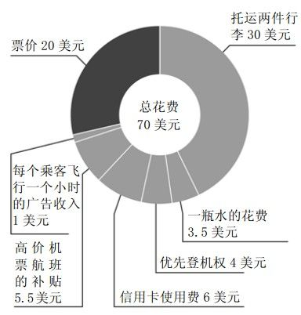

• 削减成本 Ryanair航空公司都是在停机坪上让乘客登机和下机，这样就可以减少使用停机位的费用；该公司还能从那些想要竭力扩大客流的机场那儿享受到更低的停机费。

• 增加其他收费 Ryanair航空公司对于在机舱内享用食物和水都要另外收费；优先登机、托运行李、父母带小孩飞行也要单独收费；通过网站租车和预订酒店，公司也会得到一部分提成；广告商要在机舱内做广告也要付费；通过信用卡购买机票公司也有提成。

• 通过高价机票来弥补损失 在出行高峰时期，同样的一张机票会卖到100美元以上。

现在我们到处都能找到发布广告的媒体，包括免费收听的广播和电视节目以及大多数网站。通过发布广告的媒体来免费传播信息是在一个世纪前就存在的商业模式，在这种模式下第三方（广告商）来为第二方（消费者）免费获得这些消息付费。

最近，我们有时真能得到免费的午餐，而且这也成了一种全新的商业模式。人们大多在线使用这样的商业模式，在边际成本几乎降低到零以后，数字经济成了主流。照片分享网站Flickr对大多数用户都是免费的（网站也几乎没有什么广告）。同样，Google网站提供的大部分服务也是免费的，没有什么广告，尽管用这种商业模式推出了一些新型软件或是服务（例如Gmail邮箱服务），但并没有强行推销什么内容。以维基百科和博客空间为代表的网站成为“礼品经济”的代名词，这些网站的经营动机和金钱没有关系，而是为了积累知名度、吸引网民眼球、表达观点或是其他目的。

这些免费现象可以划分为四大类，其中有两种是之前就存在的，但也在继续变化；另外两种是在数字经济时代产生的。我们在对它们进行分析之前，先把思路拉回一些，看清楚林林总总的免费归根结底都表现为同一实质—让钱在不同的产品之间、人之间、现在和未来之间、不与钱打交道的市场和金钱市场之间转移。经济学家把它称做“交叉补贴”。

### 世界就是一个“交叉补贴”的大舞台

交叉补贴体现了“天下没有免费的午餐”这句话的实质，也就是说你要吃一顿午餐，饭钱肯定是要某个人通过某种方式来偿付的，如果不是你直接付的，那么也是由某个和免费吃这顿饭利益相关的人来付账。

有时候，人们对产品的付费方式是非直接的。你手里读的那份免费报纸是可以收到广告费的，广告费是产品零售商营销成本的一部分，而且它们已经考虑好了自己的利润率，最后你（或你身边的人）会以通过购买更昂贵的商品来支付它们的广告成本。你给予零售商的还有声誉（别人看到你在读那份报纸）和你的时间。也许你在超市得到了购物免费停车的优惠，但其实停车场的成本已经打入了商品的价格上涨之中。也许你得到了一些免费样品，但是那些付了全款买同样商品的人已经给你提供了交叉补贴。

案例：DVR怎么能免费呢？

电话公司会出售包月套餐，电器公司会出售一些小家电，这些都好理解。但是美国电信巨头康卡斯特公司（Comcast）既在这两个领域之内，又有很多业务超越了这两个领域。这就给了它足够大的灵活性来进行产品交叉补贴，某种产品免费为的是出售其他产品。出于这一目的，公司免费向900万用户发放了带有机顶盒的DVR。那它又该怎样收回这样一笔钱呢？

康卡斯特公司在一年半的时间内挣回DVR的成本

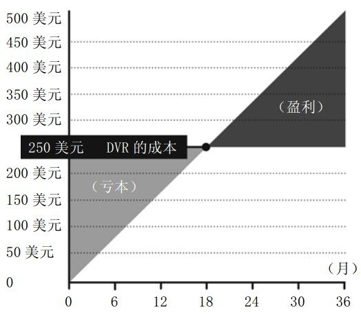

•增加隐藏费用 对于每个新的DVR用户，康卡斯特公司都会收取20美元的初装费。

•收取月度使用费 公司的用户每个月要缴纳14美元的DVR使用费。即便我们按DVR的最高成本估计，公司为每台DVR掏了250美元，那么不出一年半，用户缴纳的使用费也足够弥补DVR的成本了。

•其他收费服务 公司用免费的DVR来吸引消费者，然后让他们对高速上网（8兆流量的上网服务每月收费43美元）和数字电话（每月收费40美元）产生兴趣，这还不包括看一部电影就要付一次费的服务（每部电影收费5美元）。

在礼品经济中，交叉补贴的形式很难一眼就看穿。博客确实是免费的，上面往往也没有广告，但那并不代表每次你浏览博客的时候没有发生价值交换。在你浏览到博客上的免费内容时，作为回报，你在某人博客上增加的浏览量或是链接都提高了博主的信誉等级。他可以用高信誉等级来得到一份工作，扩大他的交际圈，或是找到更多的顾客。有时候，信誉等级也能够转换成为滚滚金钱，但是我们难以判断每一次这种转换的准确途径，因为每一次转换都是不同的。

交叉补贴可以有不同的作用方式：

·用付费产品来补贴免费产品。招徕顾客的廉价品是做生意的幌子，例如通过价格不菲的爆米花来补贴不赚钱的电影，或是通过餐厅里昂贵的红酒来补贴便宜的饭菜。免费还会以更多的形式出现，例如某种商品不是打折出售，而是完全免费赠送，“内有免费礼物”或是更常见的免费样品就属于这种推销手段。这种免费的商业模式很久之前就存在了，我们很熟悉，而且它的表现形式也很直接，因此我们就不赘述了。

·用日后付费来补贴当前免费。赠送手机但必须使用移动通讯商两年以上的服务就是一个经典的长期交叉补贴案例。这种营销手段把手机服务从追求某个时间节点的收入延伸到更长的时间段。如果你使用了这种服务，那么就是未来的你在给现在的你提供交叉补贴。使用这种服务的人不会去多想每年要付的手机费，而是会因为今天刚拿到的免费手机而沾沾自喜。

·付费人群来给不付费人群提供补贴。类似的例子有俱乐部男士买门票而女士免票，“孩子免费入场”，富人多缴税、穷人少缴税（有时候不缴税）的累进税制。把市场根据人们愿意付费的诚意和能力划分为不同的人群，是一种传统的定价理论。在这种情形下，免费以非常极端的形式出现，商家希望免费得到产品或服务的相关消费群体能够掏腰包。商家寄希望于不用掏钱的消费者能够吸引到掏钱的消费者（俱乐部女士免票的例子），或是可以带来会掏钱的消费者（孩子免费入场的例子），而且不用掏钱的消费者中日后有一部分人也会慷慨解囊。当你在美国赌城拉斯韦加斯徜徉并欣赏建筑物奢华的装饰时，你确实不用掏钱，但是这些大楼的老板们希望你能够停下来去赌场赌一把，或是去商场血拼购物（如果你既去赌钱又去购物，他们会笑得合不拢嘴的）。

在整个交叉补贴的世界里，免费模式主要可以分为下面四大类。

免费模式一：直接交叉补贴

什么免费：吸引你掏腰包买其他东西的商品

谁享受免费：以某种方式最后掏腰包的人

当沃尔玛推出买一送一的DVD时，这就是招徕顾客的廉价品。沃尔玛以低于成本价销售DVD，为的是把你吸引进超市，希望你能够买上一台洗衣机或是满满一购物筐的商品，以此从中赢利。在银行服务、手机通话等多种产品和服务中，商家并非从成本的角度来看各项要素，而是从心理的角度来衡量。也许移动电话服务商给你提供的手机包月通话服务并不挣钱，但是它把这一价格压低，是因为它知道这是顾客选择移动电话服务商最先考虑的要素，而你之后每个月会使用的语音邮件服务将是一个很大的赢利点。公司可以把一组产品的价格定为零（或接近零），为的是让其他产品而且是让更多数量的产品显得更加吸引人。

越来越多的行业采用了这种金·吉列模式的交叉补贴。先进的科技也给了公司更大的自主权，它们能够在更广阔的领域内重新界定自己的市场，也能够有更大的自由度可以赠送一些产品和服务来推销其他商品。例如，Ryanair航空公司在航空业掀起了翻江倒海的浪潮，这家爱尔兰公司并不只是把自己看做一家出售机票的航空公司，而是把自己定位为提供全方位服务的旅行社。你得到信用卡时并没有掏钱，因为银行可以从你划卡的零售商那里赚到手续费，零售商自然也会把手续费的成本加入你购买的商品之中（如果你在月底信用卡账单寄来后没有全额付款的话，那么银行还可以从你要支付的利息中赚到更多的钱）。

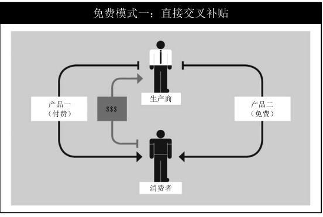

免费模式二：三方市场

什么免费：内容、服务、软件等

谁享受免费：任何人

最常见的“免费”经济是建立在三方系统基础之上的。在这种市场系统中，第三方付费来参与前两方之间的免费商品交换。听起来很复杂吗？其实你生活中每一天都会遇到这样的情况，这也是各种媒体的运营基础。

按照传统的媒体运营模式，一个发行商会免费（或近乎于免费）给消费者提供信息产品，广告商则向发行商付费，从而形成了一个三方市场。广播节目是免费收听的，电视也是免费收看的。同样，报纸和杂志发行商向读者收取的费用远远低于报刊采编、印刷和分销的成本。它们做的事其实并非把报刊卖给读者，而是把读者卖给了广告商。这就是一个三方市场。

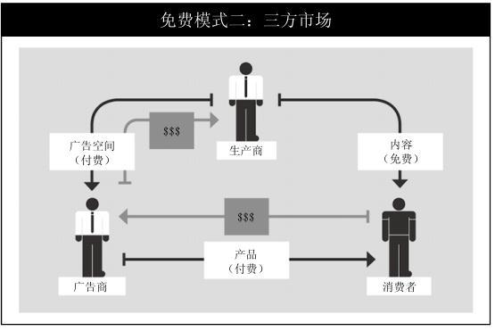

在某种意义上，互联网代表着媒体运营模式延伸到了各行各业。在互联网上，并非只是广告商给一切付费这么简单。媒体公司能够围绕免费的信息用数十种方式挣钱，包括把客户的信息出售给品牌授权商，提供“增值”订阅服务以及直接经营电子商务。目前，在同样的商业模式上已经建立起了网络公司的整个生态系统。

经济学家把这种模式称为“双边市场”，因为两个截然不同的群体在进行协同支持：广告商给媒体付费，为的是把信息传递给消费者；媒体则给广告商提供支持。而最终消费者会掏腰包，但却是以一种非直接的方式—因为商家的营销成本增加，商品的最终售价也会提高。这种模式在非媒体市场也存在，例如信用卡—免费向消费者提供信用卡就意味着他们会更多地刷卡消费，商家也需要向发卡行缴纳更多的手续费；软件公司把免费的操作系统工具送给应用软件开发商使用，为的是吸引更多的消费者来使用这一平台界面。在每一个例子中，成本或者已经分散化了，或者变得不明显了，让消费者觉得商家最初提供的产品是免费的。

免费模式三：免费加收费模式

什么免费：和付费版本相匹配的任何商品

谁享受免费：基本用户

免费加收费模式（Freemium）这个说法是由风险资本家弗雷德·威尔逊创造的，也是在网络生存空间中最常见的商业模式之一。免费加收费模式能以多种形式出现，内容有从免费的到昂贵收费的各种不同等级，有些网站和软件如果付费的话可以享用比免费版功能更多的“专业版”（可以回想一下免费的Flicker软件和每年付费25美元的Flicker升级版）。

这种模式你听上去感到很熟悉吧，就像我们随处可见的免费样品，包括商场里香水柜台和街角推销员推销的东西。两者确实有相似之处，不过也有很大的区别。传统的免费商品往往是在产品推广期间赠送一些糖果，或是把尿布寄给孩子母亲。因为这些免费的商品都是有实际成本的，因此商家在推广期免费赠送的和实际销售量相比只是很小一部分，他们的目标就是吸引消费者的眼球，以刺激更多的商品消费。

而对于数字化产品而言，免费和付费的比率刚好颠倒了过来。通常而言，一家网站会遵循“5%定律”，也就是说5%的付费用户是网站的所有收入来源。在免费加收费模式中，这就意味着在20个网站用户中，有一个是付费用户，其他19个都是免费得到服务的。这种模式之所以能够运转下去，是因为给那19个人提供服务的成本是相当低的，可以看做是零。

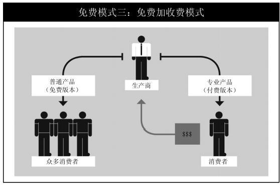

免费模式四：非货币市场

什么免费：人们选择免费赠送的、没有寄希望别人付钱的任何东西

谁享受免费：任何人这种类型也会有几种不同的表现形式。

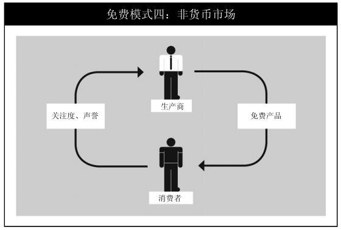

礼品经济

维基百科和Freecycle网站（在线交换二手礼物的平台）让我们发现，金钱并非人们行为处事的唯一动力。利他主义的动机总是存在的，而网络则给了个人一个让这些行为发挥世界性影响的大舞台。在一定程度上，零成本的信息传播已经使得这种传播成为了一种产业。从以金钱来衡量的经济角度看，这种信息传播似乎都是免费的，看似像不正当竞争，但这也恰恰说明了我们对于价值衡量的短视，而没有留意这种信息传播真正创造的价值。

这种信息传播的动机是多种多样的，包括赢得声誉和关注度，以及不容易察觉的其他考虑，例如表达观点、分享快乐、种下善因、得到满足感以及纯粹的自我兴趣（通过Freecycle 或是Craigslist这样的网站把东西送给别人，免得你还要照管一大堆物品）。有时候，这种给予也是无意识的或被动的。如果你有一个公开的网站，那么不管你是否有意为之，你都把信息给了Google搜索引擎；你把手中的饮料喝完后，就把铝罐扔进了可回收物垃圾箱里，无家可归靠收破烂为生的人可以把它捡出来卖钱，尽管这并非你的本意。

劳动交换

如果你能通过几个阻挡垃圾邮件站点的验证码，那么就可以在网上得到免费的色情图片。具有讽刺意味的是，你正在做的事就是用填写验证码的人类智能来将网站上的内容解码，这也正是发送垃圾邮件者所感兴趣的事，因为网站用这些验证码来把他们的邮件阻挡在外面。而一旦你通过了这些验证码，那么发送垃圾邮件者也能够进入这些网站了，这对于他们的意义远比你看这些诱人色情照片所消耗的带宽更重要。在他们看来，这就是一个黑箱，人们设置了一些歪歪扭扭的验证码，最后又得到了解码之后的内容。但是，在这个黑箱内部，有成千上万人在不经意间做着劳动交换。这就像Digg网站上的故事评分、雅虎知识堂的投票功能、Google美国411语音查号台一样。每次你用Google网站来搜索时，你都在帮助Google公司提高精准定位广告的系统运算法则。在上述每个例子中，你在使用某项服务的时候又创造了富有价值的成果，或者是提高了某个网站的服务，或者是创造了对别人有用的信息。不论你留意与否，其实你在得到某项免费服务的时候也在和别人进行劳动交换。

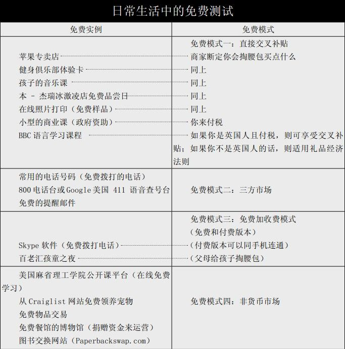

盗版

最能体现盗版猖獗的当属在线音乐了。因为数字化音乐的复制便捷和朋友间的分享，使得传播音乐的成本几乎变成了零。在这种情况下，不管有没有商业模式，仅仅出于省钱的因素考虑，在无限制的传播手段下，音乐产品变成了免费的。这股力量如此强大，以至于法律、版权保护规定、道义上的负罪感以及大牌唱片公司所能想到的一切阻止盗版的努力都无法奏效（这种现状还会延续下去）。一些音乐家和歌手把自己的音乐在线免费同乐迷分享，因为他们把这作为音乐会、音乐产品、专利权和其他付费内容的推销手段。而其他一些音乐人干脆承认，对于他们而言，在音乐界打拼已经甭想赚到钱了，在这个行业里工作主要是为了其他原因，例如追求快乐或是灵感的表达，这倒是大多数音乐人士共同的特点。

### 日常生活中的免费测试

我们来看一看上面的几种免费模式在日常生活中是以怎样的形式出现的。最近，我在一个报亭上看到《返璞归真》（Real Simple）杂志封面上写着一行字“你能免费得到的36样意想不到的商品和服务”。不论是哪个月，你在报亭都能看到类似的内容。这看起来像是检验免费模式的典型的例子。在这一期《返璞归真》杂志提到的前一半免费商品有如下特点：

你会发现有些免费商品和服务兼有几种免费模式的特点，而且它们的竞争对手也在使用不同种类的免费模式（电话和网络查询目录服务系统1-800-FREE411的竞争对手Google美国411语音查号台是不支持广告的）。此外，政府提供的服务也是一种特别的交叉补贴，因为纳税人所缴纳的税收和所享受服务之间的联系是间接的、不明显的，而且纳税人享受服务的范围很广。

我们把免费分为这几种模式的必要性不言自明，而且这种分类方法的效果也很好。没有任何一种分类方法会十全十美，遇到特例和几种模式交叉的情况也是很正常的。这种分类方法在接下来的章节里还能够给我们带来很多帮助。

### 三种价格

在这本书中，我们主要讨论的是两种价格—需要掏钱（正价格）和不需要掏钱（零价格）。但有时候还会碰到第三种我们不能忽视的价格，那就是商家给你钱。我可没有瞎说，确实存在着这种负价格。你使用某个商家的产品或服务，它还要倒贴给你钱，而非你给商家钱。

也许你会觉得这种现象并不多见，其实在生活中你经常会遇到这种情况。微软公司付费让你使用它的搜索引擎，从中你可以发现负价格的发展趋势。其实负价格的现象在传统的营销中有着悠久的历史，例如现时折扣、购物返现金的营销手段，以及现金积分、航空公司里程积分和其他使用信用卡或消费得到的奖励。

当然，上述这些情形中很少真正有负价格，你迟早都要从自己的钱包里掏钱。遇到这些情形，尽管这些钱或积分都不是白来的，但是消费者往往会把它们当成是天上掉下来的。

例如，现金返还的打折方式会让消费者的心态发生逆转，还会放弃最初想要省钱的想法。研究表明，如果购买一辆新卡车能够得到1000美元（或者某个数额）的支票奖励，那么他们在掏腰包的时候钱就像中彩票白来的一样，感觉钱是从天上掉下来的，一点都不心疼，而事实上他们买车的车贷以后还要自己来偿还。男士们分期付款买下昂贵的高尔夫球杆时，如果太太们在场的话往往都会舍不得让他们买，但是太太们也不会阻拦先生们，尽管她们明白就像信用卡还款一样，在接下来几年里球杆的钱也要分期付上。

在丹·艾瑞里的《怪诞行为学》 <sup>[1]</sup> （Predictably Irrational）一书中，里面有一个关于负定价的经典案例。有一次，丹·艾瑞里告诉自己在麻省理工学院斯隆商学院的学生说，他要朗读诗歌（沃尔特·惠特曼《草叶集》里的诗），但是不知道朗诵的价格该怎么确定。他给每个学生都发了问卷调查表，其中一半学生的调查表是问他们是否愿意花10美元来听他朗诵；另一半学生的问卷调查表上写着如果他付10美元，他们是否愿意听他朗诵。丹·艾瑞里接下来又问，如果他分别读一首短诗、不算太长的诗或是长诗，他们分别愿意出多少钱。

丹·艾瑞里最初的定调就是行为经济学家所说的“锚固”（anchor），他让消费者在心里对什么价格合适有了一个思维定式，这对于他们最后到底愿意付多少钱会有很大的影响。在这个案例中，那些被问及是否愿意付10美元来听朗诵的学生平均给出1美元的价格来听短诗，2美元的价格来听不算太长的诗，3美元的价格来听长诗。

与此同时，那些思维定式认为丹·艾瑞里要付给他们钱的学生平均的报价是得到1.3美元听一首短诗，得到2.7美元听一首不算太长的诗，得到4.8美元听一首长诗。

丹·艾瑞里还特意提及，马克·吐温在《汤姆·索亚历险记》中给了一个很好的例子：汤姆·索亚不得不帮家里干给篱笆刷油漆的苦差事，但他把这份工作炫耀得特别有意思，惹得伙伴们羡慕得不行，不仅抢着干这份苦差事，而且还愿意付钱给他。不过，通过这个故事，那些本可以得到奖赏却给了对方奖赏的人可以悟出一个道理。马克·吐温有一番仔细观察之后的洞见：“英国有一些富人，在夏天他们会乘坐四匹马牵引的豪华马车，每天要坐车出门二三十英里，因为坐这样的豪华车会花上他们一大笔钱，所以觉得有面子。但是，如果免费给他们提供这项服务的话，他们反而觉得乘马车出门是一件累人的事，也就不再乘马车了。”

CD宝贝公司（CD Baby）的创始人德雷克·西弗斯把这些例子称为“逆转的商业模式”。在现实生活中也有这样的例子。洛杉矶的一些请艺人演出的俱乐部已经不像从前那样给乐队付钱了，而是反过来向在俱乐部演出的乐队收费。因为这些艺人们更加看重的是表演的机会，而不是得到几张钞票，如果他们表演非常好的话，就有可能像前辈一样出道成为职业歌手。

在丹麦，有一家健身俱乐部给会员提供了一种服务：只要你一周内能至少去俱乐部一次，那么你就不需要付费；但是，如果你某一周没能去俱乐部，那么你就要付当月的健身费用。这个商业理念真是很好。如果你每周都去俱乐部的话，你自己感觉很好，而且对这家俱乐部的印象也会很好。但是总会有某一周你因为太忙而没能去俱乐部，这样一来你就需要掏钱，但是你只会责怪自己这周没能去俱乐部。和那些你掏了钱却又不常去俱乐部的会员不同，成了这家俱乐部的会员之后，你的本能就是不要失去会员资格，你对这家俱乐部的忠诚度也增强了。

免费电话会议公司（Free Conference Call）的收入来自电话公司，而非使用这项服务的最终用户，因为免费电话会议公司知道用户是通过哪家电话公司在使用电话会议服务。免费电话会议公司和每家电话公司都达成了合作协议，因为他们的服务能够让各家电话公司的用户拨打更长时间的国际长途。免费电话会议公司并没有给长途通话费买单，而是让这些电话公司给经常使用电话会议的用户来买单。

最后，我们还要提一下Jicka.com这个网站，它希望能够成为和Craiglist相抗衡的免费分类信息发布网站。为了实现自己的目标，这家网站决心提供比免费还要优质的服务。如果你在Jicka.com网站上发布要出售自己房子的信息，那么买家会得到半年时间的有限担保。同样，如果你通过Jicka.com网站出售汽车的话，那么买家能得到一个月的有限担保。在Jicka.com网站上登出任何广告帖子，都可以确保在一年内你的账户信息不会被盗。Jicka.com网站的这一招并没有花他们任何钱，提供担保的保险公司认为这也是很好的一个营销机会，如果免费尝试使用这些担保的用户中有一些想成为保险公司的付费投保人，保险公司就有钱赚了。

在上述每一个案例中，聪明的公司都让正常的金钱流动方向发生了逆转，它们或者是让某样东西免费，或者是在本应其他公司付账的时候买单。这些点子其实并没有什么很高的技术含量，不过想到这些点子需要你用企业家的思维来创造性地看待价格。

[1] 《怪诞行为学》已由中信出版社出版。—编者注

## 免费的历史：零、午餐和资本主义的敌人

### 导读

在家里，免费自然是通行的法则。金钱给交易提供了一种大家都能对价值达成共识的尺度，物物交换也让位于金钱支付。

从20世纪初开始，“免费”再度兴起，成为了一种营销手段。随着广播这种20世纪最具革命性的媒体方式诞生，免费也开始日益发挥重要的影响力。

电台免费广播并没有像美国作曲家、作家与出版商协会担心的那样让音乐界就此萧条下去，相反这让音乐界更加壮大而且盈利更丰了。

我们更容易关注资源贫瘠的特性使得我们会忽略生活中出现的充裕物资，电脑使得信息变得非常充裕。

如果某种商品出现了充裕的局面，那么其成本就会压低到近乎为零，而企业的利润寻找点就转移到相邻领域，美国科技出版商蒂姆·奥雷利（Tim O'Reilly）将其称为“利润不灭定律”。

对于信息和脑力来说，机械性制造的脑力产品、可零成本复制的产品充裕了；而个性化的、创造性的产品，成为增值方向。前者只是为后者的社会化降低成本。

### “没有”的难题

免费之所以让人很难琢磨透的一个原因就在于它不是一样有形的东西，而是一件事物的实质。它象征着价格的缺口，代表着计费器上的零。我们看事物、想问题往往都喜欢具体化，然而免费是一个抽象的概念，而不是一个你掰开手指就能点出来的东西。历经了几千年的文化积淀，我们才找到了一个数字来描述免费。

和很多事物一样，这个概念的量化也始于巴比伦人。公元前300年，在目前伊拉克的肥沃新月地区，当地一个兴旺发达的农业社会遇到了计数上的一个问题，这个问题并非你和我可能已经想到的那个麻烦。巴比伦人计数用的是六十进位制，而非我们现在通用的十进位制。尽管六十进位制很麻烦，但是只要你不指望用自己的手指和脚趾来点数，那么大家还是容易把数字点清的（毕竟，六十进位制也是我们现在时间计数的基础）。

问题并不在于此，而是如何把各个数字写下来。

和当时其他文化不同，巴比伦人并没有确定每个数字的固定写法。相反，他们仅仅使用两个记号来表示这么多数字：一杠表示“1”，而双杠表示“10”。因此，一杠因为摆放的位置不同，既可以表示“1”，也可以表示“60”、“3600”或是60更大的倍数。正如查尔斯·席夫在《零的故事：动摇哲学、科学、数学、宗教的概念》（Zero: The Biography of a Dangerous Idea）一书中所描述的那样，这是“铜器时代的电脑编码”。

这在使用算盘的文化中倒是很容易解决。用那个聪明的装置来加数字就是用手把算盘珠向上或向下拨动，不同格里的算盘珠表示的是不同的数字大小。如果算盘上的每一格里都有60颗算盘珠的话，那么六十进位制并不会比十进位制难到哪里去。

但是，如果你想用算盘来计数，而算盘格里没有算盘珠的话，那该怎么办？要表示“60”这个数字，可以在算盘60这一栏上拨上一颗算盘珠，而在表示个位数的算盘格上不用拨任何一颗算盘珠。但是“没有一杠”又该怎么写出来呢？巴比伦人需要一个占位符来表示“没有”这个概念。这样一来，他们就必须创造出零的概念。因此，他们就需要创造出一个新的符号来表示“没有”的概念。最后，他们用两道斜杠来表示这个概念。

不论是哪一种进位制，因为在写数字时，你显然都需要一个占位符来表示“没有”的概念，或许你会认为自从有文字记载的历史以来，“零”就一直都存在了，但事实并非如此，很多先进的文明都试图摆脱使用零。在罗马数字中，罗马人就没有用到零（在罗马数字中并没有固定的表示数位的方法，每个数字都靠和它邻近的字符来表达这个含义）。

同一时期的希腊人则公开表示不愿使用“零”。因为希腊数字建立在几何学的基础之上，所以数字需要表达长度、角度、大小等概念，而“零”面积代表不了任何含义。古希腊数学的集大成者是毕达哥拉斯和毕达哥拉斯学派，这个学派因为发现了音阶和黄金分割率而名垂千古（让人感到有些不可思议的是，他们最出名的并不是以毕达哥拉斯命名的“毕达哥拉斯定律”，“毕达哥拉斯定律”说明了直角三角形两直角边平方的和等于斜边平方的关系，而历史上早在毕达哥拉斯提出这一定律之前就已经有人知道了）。尽管希腊人知道进行算术运算有时候会产生负数、无理数甚至还有零，但是他们摒弃了这些数字，因为这些数字没有办法用具体的图形来表示（让希腊人感到尴尬的是，黄金分割 <sup>[1]</sup> 的准确数值就是一个无理数，毕达哥拉斯学派很久以来都没有把这一点告诉世人）。

这种短视眼光也是情有可原的，因为数字是用来代表实际事物的，因此并不需要一个数字来表达“没有”的概念。“没有”是一个抽象的概念，只有当表达同样抽象的数学概念时，我们才会用到它。英国数学家阿尔弗雷德·诺思·怀特黑（Alfred North Whitehead）在1911年就写道：“在日常生活的运算中，我们并不需要使用零，因为我们并不需要去集市买零条鱼。因此，在一定程度上，我们可以说‘零’是基数中最深奥的一个数字，使用它的时候往往是不得不用抽象思维的时候。”

不过，这在印度的数学家那里就算不上什么难题了。和希腊人不同，印度人并不认为所有的数字都应该代表图形。相反，印度人把数字看成是抽象的概念。东方的神秘主义能让有形之物和无形之物以阴、阳的形式共存。在印度，三大主神之一的湿婆神（Shiva）既是万物的创造者，也是万物的毁灭者，关于湿婆神的一个理解就是他代表着无形。因为印度人能够把数字和客观现实脱离，因此他们创造了代数。反过来，代数也让印度人能够用数学来表示逻辑概念。印度人创造了负数，到了公元9世纪他们创造了“零”。实际上，“零”这个数字就起源于印度梵语的sunya（空），后来阿拉伯人也使用了sifr（零），西方的拉丁语系把它再变为zephirus，也就是英文中zero（零）的词根。

### “免费”的问题

到公元900年时，无论是在符号上还是在代数体系里，都存在表示“没有”的概念。那么在经济学体系里呢？从某种意义上而言，“没有”的概念在经济学中早就存在了。英文“economics”（经济学）这个词来自古希腊的oikos（房子）和nomos（习俗、法律）两个词的组合，因此合起来的意思就是“房子的法则”。而在家里，免费是通行的法则。尽管后来在大多数文化里都出现了用金钱来衡量的经济学，而在家人、部落这些联系非常紧密的社会群体之间，日常的物品交易几乎都是不需要钱的。在家人、邻居甚至是工作场合，商品和服务交换主要依靠的还是慷慨、信任、善意、信誉、平等交换这些“社会货币”。总而言之，在亲人、朋友之间并不需要钱。

但是，在没有亲情纽带的陌生人之间，金钱给交易提供了一种大家都能对价值达成共识的尺度，物物交换也让位于金钱支付。即便如此，在赞助、公共服务等方面，免费还是有生存空间的。

随着民族国家在17世纪开始兴起，累进税制度也出现了，富人缴纳的税更多，穷人缴纳的税更少，甚至是免费得到服务。这种政府为民众服务的机制创造出一种特殊形式的“免费”：或许你并不用为政府的服务掏腰包，而是由整个社会来买单，你也无法确认自己交的哪一部分税金花到了让你自己受益的用途上。

慈善是另一种形式的免费，一个社区里的人都慷慨解囊，例如帮助邻居建造谷仓、印第安人庆祝邻居家的重要庆典赠送礼物的习俗等。一周5天工作日，规定最小工作年纪和强制退休年纪的《劳动法》，从田地劳作、向工厂工作再向白领工作的转换，都给员工创造了休息时间。这种趋势也使得志愿者热潮（免费劳动）得以涌现并一直延续到今天。

尽管金钱经济已经成为社会范式，但是人们内心深处依旧坚信有些东西是不应该收钱的。最好的例子莫过于贷款的利息了，历史上人们一直认为贷款的利息是带有剥削意味的，尤其是给穷人放贷又向他征收利息。如今，“高利贷”（usury）这个词表示过高的利息，而这个词的本义其实表示的是任何形式的利息（人们现在把无息贷款视为一种礼物）。

例如，早期的天主教教会对于收取贷款利息持坚决反对态度。克莱蒙五世教皇1311年更是把高利贷宣判为异端，并废除了所有允许高利贷经营的世俗法律。教皇息斯突斯五世把收取贷款利息的做法批驳为“人神共愤，受教义谴责，与基督教慈善之心相悖的毒瘤”。

当然，并非所有的社会都把利息视为恶魔。历史学家保罗·约翰逊就曾经写道：

大多数在近东的早期宗教和建立在它们基础之上的世俗社会规范都不禁止高利贷。这些社会都把无生命之物视为有生命力的，就像植物、动物和人一样，能够进行繁殖。因此，如果你借“饭钱”或类似的购买券给别人的话，收取利息是合法的。以橄榄、大枣、种子和动物的方式借给别人的“饭钱”早在公元前5000年前就已经出现了。

而如果涉及到在贷款的过程中赚取了真金白银，那很多社会在这方面的容忍度都非常低。

但是，经济实用主义最终占据了上风，教会在这一点上也做出了让步（其中的一个理由是安抚那些获取了政治权力的工商阶层）。在16世纪，由于更加有效的银行体系和商业手段，流通现金增多了，短期利率则大幅度下降（从年利率20%～30%下降到9%～10%），降低后的利率减轻了教会对有息借贷行为的担心。

### 资本主义和它的敌人

在17世纪之后，市场和工商业者的作用在世界各地都得到了认可。货币供应量有了管理，各种货币也得到了保护，和我们现在相近的经济活动也得到了快速发展。因为比较优势原理和专业化的出现，越来越多的陌生人之间也开始有了交易（人们把自己能做的事做到最好，并把自己生产的商品与能把其他商品做得更好的人进行交换）。货币作为价值衡量尺度的作用变得日益重要，因为这种尺度的公信力并非来自交易的双方，而是来自大家都信任的一个权威机构（通常都是国家）。“任何东西都有价格”的观念自形成以来也不过几个世纪而已。

因为英国经济学家亚当·斯密的贡献，贸易不再只是一个买卖东西的平台，也成了思考所有人类活动的一种方式。经济学作为一种社会科学诞生后，成为研究人们选择方式的途径。正如达尔文提出的“物竞天择、适者生存”一样，竞争也成了新诞生的商贸学的核心。金钱成了我们计量得失的工具。对某些东西收费也成了确保它们能继续得以生产的最有效方式，在经济学上赢利的动机就像每个人心中“自私的基因”一样强烈。

尽管市场似乎无往不利，但还是有很多人反对把金钱作为所有交换的基础。卡尔·马克思主张集体所有制和按需分配，而非按照赚钱的能力来进行分配。19世纪，以俄国彼得·克鲁泡特金王子为代表的无政府主义思想家曾设想过共产主义模式的乌托邦，所有的社会成员会自动完成应尽的义务，因为他们会意识到公有制企业和互助制度的好处。彼得·克鲁泡特金坚信，财产私有制是压迫和剥削的根源之一，因此需要将它废除，并以公有制取而代之。

彼得·克鲁泡特金在1902年出版的《互助论：演化的一个因素》（Mutual Aid: A Factor of Evolution）一书中，已经预料到了如今互联网时代“网络经济”的一些重要社会力量（大家通过发的帖子和彼此连成一个网络，给发帖子的版主带来点击率和更高的信誉等级）。克鲁泡特金指出，我们在给予的同时，得到的并不是金钱，而是满足感。这种满足感植根于社区、互助和相互支持之中。互助的这种自我强化的效果会让其他人也一样来对待你。克鲁泡特金认为“原始社会”的运转模式就同这种互助很相像，而“礼品经济”比市场资本主义离人性走得要更近一些。

不过想要让这种互助制真正变为现实的大大小小努力都化为了泡影，主要是当这个团体的人数超过150人时（人们把150个人称做“顿巴数” <sup>[2]</sup> ，这是人们根据经验估计的一个数值，超过这个数值之后，社会团体里的人就很难再维持巩固的社会关系了），团体里的人际关系就开始发生不和谐的摩擦。这种困境自然也会烦扰像国家这样庞大的社会集体。只有虚拟世界才能让我们建立在互利基础之上的经济有效运转。网络、在线游戏等交际方式能让我们和比现实生活中更多的人保持社交联系。软件拓宽了我们的交际圈，也成了我们的记分卡。

### 第一顿免费午餐

到19世纪末，这种意识形态之争似乎已经告一段落。市场经济已经在整个西方国家生根发芽了，人们不再把金钱视为万恶之源，而是把它当成增长的结晶和繁荣的关键。任何东西的价值最好是通过人们愿意给出的价格来决定，一切就是这么简单。乌托邦主义者梦想建立在赠送、物物交换和社会责任基础之上的社会体系只有一些边缘化的尝试，包括公社和以色列的集体农场。在商业世界里，“免费”显露出了它最基础的现代含义—一种营销手段，而它很快也披上了遭人怀疑的外衣。

当金·吉列和珀尔·维特通过“免费”来赚钱时，消费者们还习惯于认为“天下没有免费的午餐”。这个说法来自美国的一些酒吧，那些至少会买一杯饮料的消费者进酒吧后就能得到“免费”的食物。这些食物有可能是一个三明治，也可能是由几道菜组成的一顿午饭，这些免费午餐的价格比一杯饮料要贵得多。酒吧的老板觉得大多数顾客都会买不止一杯饮料，而免费食物的招牌在一天非繁忙的营业时间段则会吸引很多老主顾上门。

维基百科对于“免费午餐”的解释词条回顾了这一悠久传统的历史由来。它写道，1872年，《纽约时报》报道说，免费午餐已经在新奥尔良市成为一种常见的“特殊”习俗了。

根据这篇报道，这种免费午餐的模式变为了成千上万人的“生存之道”。在维基百科中提到的《纽约时报》的这篇报道中还写道：

拿取免费午餐的柜台把地位不同的各个阶层拉回到了同一起跑线，如果某个人来到了这样的柜台前，就要放弃保持尊贵地位的最后一丝希望。你能见到各个阶层的人在享用这种免费午餐，而且蜂拥上前去拿第二盘食物。

随着淘金热的到来，这种免费午餐的习俗也来到了加州的旧金山，并在那里流行了多年。

而在美国的其他地区，免费午餐的做法和当年声势日益高涨的淘金潮发生了冲突。1874年，随着妇女权益保护运动的兴起，美国也拉开了禁酒的帷幕，禁酒者攻击免费午餐只不过是掩盖“酒吧招徕顾客”的一个借口罢了，他们认为酒精“成为了其他事物围之公转的轴心”，这段历史在维基百科中也有记载。

另有一些人则认为免费午餐其实发挥了社会救济的功能。1894年，社会改革家威廉·T·史泰德评论说：“在芝加哥，提供免费午餐的酒吧比所有社会性、宗教性和慈善性组织救济的穷人总数还要多。”史泰德还援引了一份报纸的粗略统计数字，3000家免费午餐酒吧每天能给60000人提供食物。

两年之后，也就是在1896年，纽约州议会通过了《雷恩斯法》（Raines Law），目标是控制酒品走私。在《雷恩斯法》的众多条款中，其中有一条就是禁止酒类销售，除非在购买酒类的时候搭配食物销售。该法中的另一条款也使得商家免费提供食物变为了不合法。不过，这一法律条款过了没多久就废除了。第二年，《雷恩斯法》的修正案使得免费午餐依然合法，而且这一惯例也延续了几十年。

### 免费样品和赠品

从20世纪初开始，随着袋装食品业的兴起，“免费”再度兴起。随着各大品牌、广告和遍及全美国的分销渠道的繁荣，“免费”也成为了一种营销手段。其实，免费样品并不是什么新生事物，这种针对大众的推销手段可以归功于19世纪的一个营销天才本杰明·巴比特。

本杰明·巴比特有很多发明，其中就包括几种制造肥皂的方法。不过，真正让他大放异彩的是他创新的销售方法，这甚至能和他的朋友、推销大师P·T·巴南相媲美。本杰明·巴比特制造的肥皂在全美国家喻户晓，主要得力于他成功的广告和推销策略，其中就包括产品销售早期大范围免费发放样品。本杰明·巴比特的广告词是“您能好好试用一下，我就心满意足了”，表现出绅士般的销售员发放试用品的慷慨大度。

这些肥皂是从停在马路上、颜色鲜艳的车里销售的，旁边还有乐手在表演，因此也诞生了“跟风抢购”这个说法。1992年，诺贝尔文学奖获得者辛克莱·刘易斯在自己的代表作《巴比特》一书中，就使用了巴比特这个名字来描述一个粗俗、傲慢的商人。

另一个推销界的经典就是位于美国南达科他州的华尔药店（Wall Drug）。1931年，南达科他州土生土长的药剂师泰德·哈斯泰德想要在一个信奉天主教的小镇上开辟自己的生意，华尔药店帮他圆了这个梦。华尔药店坐落于这个只有231个人的小镇，按泰德·哈斯泰德自己的说法，这个小镇几乎“跟哪儿都不挨边”。可以想见，华尔药店的经营状况也是举步维艰。1933年，转机出现了，在这个小镇以西60英里的地方，有美国最伟大四位总统塑像的罗斯摩尔山国家纪念公园开始向公众开放，泰德·哈斯泰德太太提出了一个营销建议，那就是向去公园的过路人免费提供冰水。这个销售良方使得华尔药店的知名度大涨，小店的生意也越来越红火。

如今，华尔药店已经升级成了以西部牛仔为主题的大型主题购物商场。现在，它会向顾客免费赠送汽车保险杠上的贴纸、免费的推销标语，也会提供5美分一杯的咖啡，当然还提供免费的冰水。

### 免费是一种武器

随着广播这种20世纪最具革命性的媒体方式诞生，免费也开始日益发挥重要的影响力。现在，我们知道进入一个市场最具杀伤力的方式就是彻底淘汰现有的商业模式。对于某一种别的商家依靠它来盈利的商品，你却免费提供这种商品，相信顾客自然会络绎不绝地来到你的店门口，你就可以卖别的东西给顾客。你不妨看一看，移动运营商提供的长途电话服务抢了多少固定电话运营商的生意，网站上免费的分类广告又抢了多少报纸读者。

70年前，在唱片音乐界也发生了类似的一场“腥风血雨”的争斗。在20世纪30年代，广播成了新兴的一种娱乐方式，而且很受大众的欢迎，同时也把靠音乐为生的艺人们的生活搞得一团糟。当年大多数在电台播放的音乐都是在现场演出的，在表演完毕之后，音乐家和作曲家会得到报酬。但是，在这些音乐家们看来，只付一次的报酬显失公平，因为同时有几百万听众在收听节目。他们认为，如果把这几百万人同时装在一个大音乐厅里，那么他们得到的门票收入要多得多。

广播公司认为，很难按照听众人数来支付版权费，因为没人知道到底有多少听众。但是，几乎对艺术家占据着垄断管理地位的美国作曲家、作家与出版商协会（ASCAP）定下了这个合约规定：电台用每年广告总收入的3%～5%要用来支付使用音乐的版权费。更糟糕的是，当这份合约在1940年过期时，该协会还要求把这一比率进一步提高。

当广播公司和美国作曲家、作家与出版商协会还在谈判的过程中，各家电台已经开始尝试用自己的方式来解决问题了，它们完全取消了在电台进行的现场表演。当年，录音技术也在不断进步，越来越多的电台开始播放唱片，介绍曲目的播音员称为DJ。而各大唱片公司也采取了应对之道，它们在出售的唱片上写着“未经授权，不允许电台播放”。不过，1940年美国最高法院作出判决：如果电台花钱买了一张唱片，就有权在节目中播放。作为报复，美国作曲家、作家与出版商协会就说服了平·克劳斯贝等著名的音乐人不再灌制新唱片了。

面对着可供播放的音乐越来越少，而且日后唱片公司在版权费用上可能会有更无理要求的威胁，美国的各家广播公司打算主动出击，它们成立了自己的音乐版权机构美国广播音乐公司（Broadcast Music Incorporated）。蒸蒸日上的美国广播音乐公司成了吸引各地乐手的一块磁石，其中包括很多蓝调音乐和乡村西部音乐歌手，这些歌手根本得不到总部位于纽约的美国作曲家、作家与出版商协会的重视。这些人气不高的歌手更看重的是出名机会而不是金钱，因此他们同意电台免费播放他们的音乐。于是，靠向电台收取音乐版权费的商业模式彻底崩溃了。音乐家们把广播当成了一种主要的推销手段，通过出售唱片和演唱会门票赚钱。

尽管美国作曲家、作家与出版商协会在20世纪五六十年代多次提起诉讼，但是再也没能夺回向电台收取高额版权费的权利。免费收听的广播节目以及微不足道的版权费用开创了DJ时代，并随之出现了单曲前40名之类的排行榜。目前，各大唱片公司向电台收取版权费用依照的是一个综合考虑时间、听众人数、电台类型的计算公式，但是这些费用很低，不会影响电台经营下去。

事实证明这彻彻底底是一场闹剧。电台免费广播并没有像美国作曲家、作家与出版商协会担心的那样让音乐界就此萧条下去，相反这让音乐界更加壮大而且盈利更多了。免费的低档次音乐版本（音质差、收听时信号不稳）反而成了付费的更高质量版本的绝佳推销手段，音乐家的主要收入也已经从现场表演转到了唱片版税。而“免费”则给这些音乐家们提供了回归的机会，免费音乐成了他们日益红火的演唱会的推销手段。当然，在意料之中的就是，大唱片公司对此依旧是持反对意见。

### 富足年代

如果说20世纪人们开始重新欢迎“免费”这一理念的话，那么富足时代的到来则让“免费”成为了现实。对于之前的几代人而言，缺衣少食、屋漏门坏之类的物质贫乏一直是令人头疼的事。而对于过去半个世纪在发达国家出生的人而言，出生之后富足就一直围绕着他们。富足最明显地体现在生存最重要的必需品食物方面。

当我还是一个孩子的时候，饥饿一直都是困扰美国贫民的一个主要问题。时至今日，美国人担心的是肥胖症。在过去40年间，世界农业领域发生了巨大的变化，我们种植食物的能力大大提高了。科技推动的革命使得原来缺乏的农产品变成了充裕的物资。而在每一种主要资源从贫瘠走向丰饶的过程中，我们都能发现和农产品一样的变化规律。

生产农作物需要5种主要的要素投入：阳光、空气、水、土地（养分）、劳动力。阳光和空气是免费的，如果农作物能在雨水充足的地方生长，那么水也是免费的。剩下的要素—劳动力、土地（养分）则并非免费的，它们也成了影响农作物价格的主要因素。

在19世纪，工业革命使得农业机械化成为可能，这就大大降低了劳动力的投入并提高了农作物的产量。不过，真正让食品经济发生革命的是20世纪60年代的“绿色革命”，因为这场革命使得耕作变得如此高效，因此从事农业的人口大为减少了。第二次农业革命的核心秘密就是化学的进步。

在之前的人类历史上，我们有多少肥料就决定了我们能生产多少食物。农作物的产量受制于肥料的数量，而肥料主要来自动物（有时候是人）的粪便。如果一块地既要种植养活动物的饲料，又要种植给人吃的食物，那么就需要把地分成两部分。不过，到了19世纪末期，生物学家已经知道植物所需要的养分其实就是氮、磷、钾。

在20世纪初，几位化学家开始研究如何大规模地生产这些养料。这项研究的突破者是来自德国巴斯夫公司（BASF）的化学家弗里茨·哈伯，他在高压和高温的环境下，利用空气和天然气混合的方式提取出了液态氨。1910年，德国化学家卡尔·波施把这一技术进一步商业化，研制出了廉价的氮肥。人们甚至把氮肥的批量生产誉为改变马尔萨斯人口危机论的转折点。如今，生产氮占用了全球5%的天然气消耗量，并使用了2%的能源总量。

弗里茨·哈伯和卡尔·波施两位科学家使得农民摆脱了依靠自然肥料的命运。随着化学杀虫剂和除草剂的诞生，绿色革命也就应运而生了，它使得全球的农业生产能力提高了将近100倍。这使得地球可以养育更多的人口，尤其是新兴的中产阶级已经不满足于只吃谷物了，而是想选择食物链中更高端的、需要耗费更多养料来生产的肉类产品。

绿色革命的效果是惊人的。在过去的半个世纪里，困扰美国人的主要营养问题已经从饥饿转变成了肥胖症，主要是因为到处都有廉价、充裕（有些人说过度富足）的食品。1955年，养活美国家庭的平均费用要占到家庭总收入的约33%，现在这一比重已经下降到了15%。

### 遍地是玉米

目前，我们每天都能感受的农产品富足的一个重要方面就是玉米经济。这种人类已经种植了数千年的植物生命力不同寻常，它结出的玉米粒越来越饱满，亩产量也超过了地球上任何其他农作物。

在谈到食物的时候，玉米经济自然代表了一种富足经济。历史学家在看待古代文明的时候，往往通过大米、小麦和玉米这三种农产品对比的视角。大米富含蛋白质，但是种植不易；小麦生命力强，但是蛋白质含量低；只有玉米既容易种植，蛋白质含量也高。

历史学家们通过观察发现，生产这些谷物的“蛋白质/劳动付出”比率决定了相应文明的历史进程。这一比率越高，那么食用这一谷物的民族“社会富余资源”就越多，因为他们可以用相对较少的劳动来养活自己。当然，这一比率越高，效果不一定都是正面的。种植大米和小麦的社会往往更注重农业文明和内聚性文化，也许种植这些谷物耗费了他们太多的精力。食用玉米的玛雅人和阿芝台克人可以节省出更多的时间和精力，而他们往往会用这些时间和精力去侵略邻国。通过这种分析，玉米所带来的社会富足使得阿芝台克人变得好战。

如今，玉米的用途已经远远超过了食物的范畴。由于合成化肥的普及和种植技术的提高，玉米已经成为世上将阳光和水转化为淀粉的最高效手段。我们目前在玉米丰收的金色海洋中徜徉，玉米多得根本吃不完。玉米已经成为各种各样产品的添加成分之一，甚至包括油漆和包装盒。廉价的玉米已经让很多食物从我们的食谱中消失，也把奶牛之类的食草动物的食性都改变了，现在这些动物就像是用玉米填饱的产奶机器一样。

正如作家麦可·普伦在《杂食动物的困境》（The Ominivore's Dilemma）一书中指出的那样，炸鸡块中“都是玉米成分，不仅鸡肉本身的成分含有玉米（饲料），而且做鸡块的其他成分也含有玉米，包括用来增加黏度的调和淀粉、裹鸡块用的玉米糊以及炸鸡块用的玉米油。还有一些成分如果我们不留意观察是难以发现的—酵母、卵磷脂、单酸甘油酯、甘油二酸酯、甘油三酸酯、炸鸡块表面金黄发酥的颜色、用来保鲜的柠檬酸，都有可能是从玉米中提炼出来的”。

麦可·普伦写道，如今在大多数超市中，1/4的食品都含有玉米的成分，而且大量的非食物类商品也含有玉米成分，包括牙膏、化妆品、一次性尿布、清洁剂等生活用品，甚至包装这些用品的盒子都含有玉米成分。即便是建筑、装修超市所用的墙板、油布和黏合剂，也都含有玉米的提取成分。

现在的玉米如此充裕，我们开始从玉米中来提取燃料乙醇，因为这方面的研究，我们终于看到了玉米的充裕也是有限度的。尽管玉米的价格几十年来一直走低，但是随着油价的上涨，玉米的价格在近几年也开始攀升。不过，技术创新不希望主要原料价格上涨，这就使得科学家们开始寻找从柳枝或其他纤维素中提取乙醇的方法，而这些含纤维素的植物能在玉米都无法生长的地方活下来。如果能找到那种神秘的纤维素分解酶的话，玉米的价格还将再次下降，其他各种食物的价格也将下跌。

### 奥利克打赌输了

从长期来看，商品的价格会变得更便宜的观点和人的直觉相违背。食物吃了还可以再种，但是矿产资源就不同了。毕竟，地球上的资源是有限的，我们开掘的资源越多，那么留下的资源就会越少，这是资源贫瘠论的一个经典例子。1972年，一个由知名学者组成的智囊罗马俱乐部出版了《增长的极限》（Limits to Growth）一书，书中列举了世界人口快速增长会带来的后果，以及有限的资源给增长带来的制约作用。这本书售出了3000万册，并解释了“人口大爆炸”威胁之类的环境变化因素让地球经历着它难以承受的重负。

但是，并非所有人都像马尔萨斯那样对地球的未来感到绝望。回顾19世纪和20世纪的世界历史，我们发现人类聪明程度的进化远远快于人类自身繁衍的速度，聪明的人类从自然界中开发新资源的速度往往快于我们消耗资源的速度。这就能产生供给增长快于需求的效果，从而对价格产生平抑作用（当然，这种状况也不能永远持续下去，因为地球上的资源总量毕竟是有限的，不过我想表述的观点是地球上的资源毕竟要比罗马俱乐部所担心的多得多）。关于地球上的资源到底是多是少的问题引发了历史上最有名的一次打赌，打赌的双方对地球资源是丰还是寡持完全相反的观点。

1980年9月，人口生物学家保罗·奥利克和经济学家朱利安·西蒙在《社会科学季刊》（Social Science Quarterly）上公开打赌，打赌的对象是一些主要商品在未来的走势。

朱利安·西蒙许下10000美元的赌注，认为“那些不由政府控制价格的初级原材料（包括粮食和石油）的价格在长远看来并不会上升”。保罗·奥利克的看法正相反。他们打了这个赌，并约定1990年9月29日作为支付赌注的日期。如果剔除了通胀因素的各种金属价格在这10年中上升的话，那么朱利安·西蒙愿意把钱输给保罗·奥利克。同样，如果价格下跌的话，保罗·奥利克就要付钱给朱利安·西蒙。保罗·奥利克选择了五种金属—铜、铬、镍、锡和钨来打赌。

在1980到1990年之间，世界人口增加了8亿，是人类历史上人口增长最快的10年。但是，到了1990年10月，保罗·奥利克选择的五种金属价格全部下降，其中有些金属价格的降福甚至过半。铬的价格在1980年是每磅3.9美元，到了1990年下降到了每磅3.7美元。锡的价格在1980年是每磅8.72美元，10年之后下降到了每磅3.88美元。

为什么这次打赌朱利安·西蒙能赢呢？其中一个原因就在于他是一位出色的经济学家，深谙替代作用的效果。如果某一种资源变得稀缺而且昂贵了，那么就会促使人类去寻找另一种更充裕的资源，而目前对稀缺资源的需求也会逐渐向别种资源转移（不妨考虑一下现在人们争分夺秒地寻找石油的替代物）。朱利安·西蒙认为，人类的智慧和科学的学习曲线能够帮助我们以比消耗资源更快的速度找到新资源。

朱利安·西蒙这次打赌能赢的另一个原因在于保罗·奥利克过于悲观了，保罗·奥利克预测在1975年将发生影响数亿人的“超大规模”饥荒，使得20世纪70年代和80年代饿殍遍野，这意味着世界将“进入真正的贫乏年代”（尽管保罗·奥利克做出了这么明显的误判，但是在1990年他还是获得了“麦克阿瑟基金天才奖”，获奖理由是他“加深了公众对环境问题的了解”）。

人类似乎与生俱来对资源贫瘠要比对资源充裕的理解更加深刻。正如我们在进化的过程中形成了对威胁过度反应的本能一样，我们的一个生存技能就是关注资源耗竭会带来的威胁。从进化的角度来看，资源充裕不会有大碍，而资源贫瘠的问题则需要耗费精力去应对。因此，尽管朱利安·西蒙赢得了这场赌局，但在世人眼中，保罗·奥利克的担忧在某种程度上也是正确的。

朱利安·西蒙抱怨说，他难以理解人们对任何事情总会想到最悲观的一面，而对于事物美好的一面则视而不见，好像都在体内种下了不受乐观情绪感染的疫苗一样。保罗·奥利克的悲观预测到现在还一直有影响，而朱利安·西蒙的发现似乎只让大宗商品交易商感兴趣。

### 充裕的盲点

显然，朱利安·西蒙赢得了赌注。但是，我们更容易关注资源贫瘠的特性使得我们会忽略生活中出现的充裕物资，玉米就是很好的一例。问题在于，一旦某种物资变得非常充裕，那么我们就容易忽略它，就好像我们根本不在意正在呼吸的空气一样。人们把经济学定义为研究“稀缺情况下选择”的科学是有道理的，在物资充裕的情况下，你根本无须做出选择，你什么都用不着多想。

已故的科罗拉多大学工程系教授彼得·贝克曾指出：“中世纪时，在欧洲的一些内陆地区，因为盐是非常稀缺的物资，因此人们经常把它视为和黄金一样可以流通的‘货币’。不妨再来对比一下现在的情况，盐现在只不过是你餐厅吃饭时免费提供的调料而已，盐实在太便宜了，根本没人会在意它。”

在世界范围内，全球化等变革性因素使得充裕的劳动力资源影响了世界各国。如今，衣服等基本生活必需品的价格如此低廉，很多人穿几次就不要了。1900年时，美国一位男士最普通的衬衫（用的布料、做工和T恤衫差不多）批发价为1美元左右，这在当时价格不菲，而且到零售商那里价格还会再抬高。因此，当年平均每个美国消费者只有8套衣服。

如今，T恤衫的批发价差不多也是1美元，但是如今的1美元只相当于一个世纪以前4美分的购买力，也就是说一个世纪前买一件T恤衫的钱现在可以买到25件。如今，大家都觉得没有必要穿破旧的衣服了，那些无家可归的人找到免费衣服穿要比找到免费的浴室和洗衣机更容易，因此他们衣服穿旧就扔了。

在20世纪大家每天最能切身感受到物资充裕的就是塑料了，它几乎让大家感觉由原子构成的原材料是不要钱的，而且它延展性那么好，几乎能做成任何物品。塑料这种可以重复使用的物品把生产成本和原材料成本压低到了近乎为零。塑料不需要切割、用机床加工、着色、塑型或是压印，它可以制成任何形状、质地和颜色的产品。这也带来了“一次性产品”文化。由于比利时化学家利奥·贝克兰（Leo Baekeland）在1907年发明了合成塑料，金·吉列所创的随弃式刀片文化已经推广到了几乎所有物品。电木（Bakelite）的名称也来源于利奥·贝克兰。他公司的标志上，大写的字母B后面有表示数学上无穷大的符号，就好像在说明合成塑料目前的使用范围无限广泛一样。

在第二次世界大战时，塑料是一种重要的战略资源，因此美国政府在合成塑料生产厂上投入了10亿美元。战后，这种生产能力转向了民用消费市场，把这种延展性特别好的物质变为了特别便宜的一种原材料。特百惠家居用品、富美家桌子、玻璃纤维制成的椅子、瑙加海德革双人沙发、呼啦圈、一次性钢笔、橡皮泥和尼龙连裤袜等商品和品牌，像雨后春笋一样冒出来了。

第一代塑料制品并不是一次性产品，而是一些性能优越的产品。它们的形状比金属制品更加多种多样，耐用性又比木头制品好。但是，第二代塑料制品中的乙烯和聚苯乙烯价格非常便宜，人们在用过之后不假思索地就会把它们给扔了。到了20世纪60年代，颜色鲜亮的各种一次性商品代表着现代化，代表着先进的工业科技战胜了物质贫乏。把工业产品丢弃了并不算是浪费，而是先进文明国家的生存特权。

到了70年代，认为这种物资取之不尽、用之不竭的观点开始发生转变。一次性商品对于环境造成的危害也在变得日益明显。塑料制品的价格近乎于免费，但问题在于我们的定价方式并不准确。如果我们考虑塑料制品的成本时也兼顾“负外部效应”的话，那么我们在把吃了麦当劳开心乐园餐送的塑料玩具玩过一次后扔掉时，就会有种负罪感。这一代人开始注重资源的循环利用。我们对于物资充裕的态度开始从注重个人心理满足感（“对于我是免费的”）转向了公众的责任感（“对于大家并不是免费的”）。

### 充裕制胜

20世纪人类的历史主要是由充裕所推动的社会和经济巨变。因为人类能够开发蕴藏量丰富的石油代替鲸鱼油，使得石油的用途无处不在。8英尺长的大油罐旁往往站满了码头工人，不需要起重机就可以进行装载和卸载，使得运输的费用足够低，而且可以开发很远的城市或国家充裕的劳动力。电脑则使得信息变得非常充裕。

正如水往低处流一样，经济发展的过程中自然会出现新的充裕。产品在商业化和价钱变得更低之后会出现这种趋势。寻求利润的公司也在去上游寻找新的稀缺资源。如果某种商品出现了充裕的局面，那么其成本就会压低到近乎为零，而企业的利润寻找点就转移到相邻领域，美国科技出版商蒂姆·奥雷利将其称为“利润不灭定律”。

2001年，管理大师塞思·戈丁在《喷嚏营销》 <sup>[3]</sup> （Unleashing the Ideavirus）一书中指出：“20年前，《财富》500强中的前100强往往是采矿企业，或是自然资源（铁矿石、石油）加工型企业。”时至今日，塞思·戈丁指出，这种局面已经完全改变了。

目前在《财富》前100强中，只有32家是生产传统产品的企业，包括航空、汽车、化学制品、食品、钢板弯件和重工业企业；其他的68家企业主要提供的都是知识财富，而非能源加工。其中一些企业并非加工型企业，而是服务型企业，例如保健和电信行业。还有些企业创造的往往是智力财富，例如医药行业和半导体行业，在这些行业中，生产实物产品的成本和发明这些产品的成本相比是微不足道的。还有一些企业在为其他企业的产品承担大众零售商和批发商的角色。下面是这68家企业的分行业列表：

- 保险：寿险、健康险（12家）
- 保健（6家）
- 商业银行（5家）
- 批发商（5家）
- 食品、药品（5家）
- 百货公司（4家）
- 医药（4家）
- 证券（4家）
- 专业零售商（4家）
- 电信（4家）
- 电脑、办公设备（3家）
- 娱乐（3家）
- 多元化金融企业（2家）
- 邮寄、包裹和运输业（2家）
- 网络和其他通信设备（2家）
- 电脑软件（1家）
- 储蓄机构（1家）
- 半导体和其他电子元件（1家）

从朱利安·西蒙和保罗·奥利克的打赌中我们可以看出，随着商品的价格变得越来越便宜，价值就会去寻找新的出路。商品依然代表着很多财富（不妨看一看富裕的石油生产国），但是利润率最高的还是在产品中融入了智力成果的，这在上面68家企业的列表中也能体现出来。几十年前，创造价值最多的是制造业。全球化的趋势使得制造业的商品价格随之下降，价值也转移到了还没有成为商品的未开发领域，价值离手眼配合的体力劳动越来越远，而离头脑和嘴配合的智力劳动越来越近。现在的知识工作者就像（农业文化占主导地位时期）工厂工人，在向上游寻找更多的稀缺性。

如今，在美国前劳工部部长罗伯特·里奇看来，所谓的稀缺性只是一种“象征性的分析”而已，将知识、技能和抽象思维能力融合在一起成为一个有成效的知识工作者。人们经常面临的一个挑战在于如何区分人和电脑的区别，因为这条分界线一直都在变化。

随着我们教会电脑来做人类的工作（例如股票交易），此类工作的成本也降低到了近乎为零，不用再干这些工作的人就学着做一些更具有挑战性的事，或者干脆就无所事事了。转行的人会得到更高的报酬，而无所事事的人得到的收入就更少了。第一种人享受到了充裕带来产业变革的机遇，而第二种人则承担了相应的成本。对于整个社会而言，我们所要做的是要让第一种人尽可能多，而第二种人尽可能少。

这种考虑充裕的思维并不仅仅只是发现什么东西会变得更便宜，也是寻找在产业转移的过程中什么会变得更有价值，并努力向这个方向趋近。这是增长的引擎，早在17世纪李嘉图提出一个国家相对于别国的“比较优势”之前，人们在借着这个引擎前进。上个时代的充裕往往是某个国家因为资源更丰富、劳动力更便宜，从而使得该国的产品更丰富。这个时代的充裕并非仅意味着原来的初级产品，也包括硅谷这样的高科技中心和光纤这样的高附加值产品。

[1] 黄金分割指的是把全长分为长、短两段，长段的平方等于全长与短段的乘积，它的近似值为0.618∶1。—译者注

[2] 牛津大学人类学家罗宾• 顿巴教授认为人类大脑能容纳一个148 人的稳定社交网络，四舍五入到150 人，就是著名的“顿巴数”。—译者注

[3] 《喷嚏营销》已由中信出版社出版。—编者注

## 免费心理学：你感觉免费如何？

### 导读

收费会让我们想到选择的成本。

行为经济学想要解释的是，尽管我们有些经济选择并非最理性的，我们为什么还会做出那样的选择。

一旦碰到要收费的问题，我们的脑子里面马上就会立起一面小旗，会联想到“掏这钱值得吗”。如果你要收费的话，甭管你想收费多少，我们作为消费者都会扪心自问是否真的想要掏腰包。但是，如果某件商品价钱是零的话，那么我们脑子里的那面小旗就不会立起来了，做决定时也会觉得轻松多了。

美国乔治·华盛顿大学的尼克·萨博（Nick Szabo）给这面小旗起了一个恰如其分的名称，叫做“心智交易成本”（mental transaction costs）。简而言之，这指的是思考的收费成本。

某一天，你醒来之后或许会翻然醒悟，觉得自己有花不完的钱，而时间却显得特别宝贵。类似的时间/金钱衡量是礼品经济的重要心理基础。你想要付费的理由在于这样可以降低选到的东西非自己想要的风险。

如果你是一个更在意关注度而非金钱的信息提供者，那么免费之道是一个好主意。在这个阅读对象不停变化的体系里，你让提供的内容免费能够给自己带来竞争优势。就像酒鬼常说的那样，不管你跌得有多惨，你都不会跌到地板下面去。

和《乡村之音》境遇截然不同的有一份周报《洋葱》（Onion），《洋葱》这份以讽刺性文章见长的宽版周报创立于1988年，最初只是在威斯康星州的麦迪逊大学城免费发放，但经过20年的锤炼，它已经成长为了一个媒体帝国。它不仅在邻近的10个城市印刷发行，而且还设立了一个网站，每个月的点击量都高达几百万人次。它现在还出版图书，制作电视访谈节目，并开始涉猎拍摄电影专题片。《洋葱》创立时就是免费的，一直以来就是免费的，而且焕发出勃勃生机。

从表面来看，这个故事看起来让人似乎觉得有些费解。“免费”似乎让一份周报没法生存下去了，但却让另一份周报焕发出活力。在《乡村之音》身上，免费使得它的产品价值大为降低；而在《洋葱》那里，免费却使得它取得了让人惊叹的业务扩张成就。

不过，事实并不像我们想象得那么简单。首先，并不是免费造成了《乡村之音》的衰落，《纽约》杂志的文章解释说：

据说《乡村之音》的很多记者认为报纸免费之后，他们花费心血写作的文章影响力就大大降低了，报纸的总编戴维·斯纳吉曼语带揶揄地说，这也是别无选择的，“在免费之前，我们发行量最好的时候达到16万份，后来下滑到了13万份，而现在免费之后，发行量已经超过了25万份……你们难道不希望自己写的同一篇文章被两倍多的读者阅读吗”。实际上，让报纸影响力下降的并不是免费，相反正是免费拯救了这份报纸，使得报纸能继续运营下去并赚到钱。

换而言之，《乡村之音》一直都在衰落，至少在它免费之前很多年，它的基本运营指标就处于下行通道之中，有人把责任推到了免费身上，其实混淆了原因和结果的逻辑关系。

为什么在一个案例中人们会觉得“免费”意味着质量下降，而在另一个案例中却不会呢？事实证明，我们对于“免费”的看法是相对的，而非绝对的。如果某样物品在过去需要花钱买，而现在却不用掏钱了，我们可能会联想到是不是质量下降了。但是，如果某样东西从来就不需要我们掏钱，那么我们就不会有这种感觉。如果有人给你免费的百吉饼吃，你会觉得它是不是过了保质期的食品，但是在餐厅里给你的免费番茄酱你就不会有这种担忧，也没有人因为Google搜索引擎是免费的就认为它品质低劣。

通过《洋葱》和《乡村之音》的对比，我们发现大家对于“免费”有一个重要的理解误区，而我们的理解还局限于两个价格（零价格和收费）的比较。在如今的媒体世界中，免费的心理学（以及与之相关的定价）要比这两个价格更微妙复杂。我不妨用包装精美的杂志价格来更好地说明这个问题。看到这本杂志你可以有几种不同的方法，你可以选择在线免费阅读，不过网站上的文章和印刷精良的杂志相比就显得有些粗糙了，因为牺牲了印刷版本（也给内容在线重新创作提供了帮助）的精美设计、照片和包装来换取了即时的阅读性；你也可以到报亭去买这本杂志，售价可能是4.95美元；也可以一次订购全年的12本杂志，总定价是10美元，相当于每期杂志的价格是83美分，这些杂志会直接邮寄到你家中。免费、4.95美元、83美分这些不同的价格到底是怎么来的呢？

在线阅读的免费是最容易解释的，通过网络传递内容的成本非常低，网站就干脆把价格压低到了零，并以此来吸引最多的读者群。网站平均在每个页面上设置两个广告，每个广告的广告费在每千次点击量5美元到20美元之间，这就意味着每次有人点击这个页面就可以拿到1美分到4美分之间的广告费，而维护那个页面的费用只是1美分的几分之一（网站的其他成本也就是制作网页的内容，但是那么多人数把内容制作成本一分摊就很低了，网站的浏览人数越多，摊薄后的页面平均制作成本就越低）。

报亭上杂志4.95美元的售价也不难解释。卖出杂志之后，其实报亭赚的还不到售价的一半，这些钱用来支付报亭的运营成本并期望能赢利。其他的钱都回到了杂志发行商手中，在扣除印刷和运送成本之外，每本杂志能够有大约一到两美元的利润。但是对于大多数杂志而言，印制的半数以上杂志都卖不掉，最后只能回收并化成纸浆，这会在很大程度上减少杂志社的利润。既然如此，那为什么还非要把杂志送到报亭去卖呢？因为这是吸引订户的一种有效方法，因为会有读者真的去尝试订某份杂志，而非只是阅读推销这份杂志的宣传页。除此以外，从已经售出的杂志中，杂志社也能赚到可观的广告费。

上面谈到杂志的两个价格都是由经济因素决定的，而非由心理因素决定的。那么全年10美元的订购价格又该怎样解释呢？这里面还是大有玄机的。12本杂志的印刷和邮寄上门的费用是15美元，如果把最初吸引你成为订户所花的成本也加上，那么杂志社为每个订户所支付的实际成本约为30美元。但是，杂志社却只收10美元。其实这中间并没有谁在变魔术，广告收入会帮杂志社支付两者之间的差价，即杂志社原来看上去会亏掉的钱由广告商来补足。因此，广告收入使得表面看起来亏本的杂志订阅生意能盈利。如果某个订户能连续订阅三年或更长的时间，那么杂志社赚到的钱连最初吸引这个订户的成本都可以抵偿了，这样就使得杂志社盈利更丰厚了。

简单来说，不论订户付了多少钱，他填写支票或者输入信用卡号的时候，都是一种消费行为，这种行为也会让广告商改变对这个订户的看法。哪怕你用支票支付了1美分，也表明你想要这份杂志，当杂志送到你家的时候你会去好好翻阅它。实际上，和一些会被人当成垃圾邮件的免费杂志相比，对于那种订户主动订阅的杂志，广告商愿意支付的广告费有可能是前者的五倍。

注意，现实中的确有很多杂志提供免费订阅服务，这种方式在业界叫做“赠阅发行”（controlled circulation），它们的运营驱动力是另一种“货币”—信息。这些杂志往往都是一些阅读受众为特定人群的商务类杂志，一种主要是瞄准首席财务官或是其他能支配公司购买力的商务精英，另一种是那些走在时尚前沿的生活休闲类杂志。

这些商务类杂志的读者往往都是或自称是重要人士，手里有大笔花不掉的钱。如果某个杂志社有很多有头有脸的公司高管都正式填写了订阅申请表，成为杂志订户的话，那么杂志社就可以利用这种信息向广告商收取更高的广告费。而在广告商看来，虽然这些潜在的消费群并没有掏出真金白银，但是他们潜在的巨大消费能力足以补偿很高的广告支出。加拿大的杂志《维斯》（Vice）就是通过控制发行量大获成功的例子，这份风格活泼的杂志主要针对20多岁的年轻人，在嬉皮士风格的咖啡馆、唱片店、服装店发放。20世纪90年代时，它在加拿大免费发放，后来足迹又扩展到了美国乃至全球。这份杂志给了广告商影响很重要的一个读者群体的平台，如果没有这份杂志，它们是很难让这个群体看到想要投放的广告的。经过多年发展，这份发行量不大的杂志后来还把业务范围拓展到唱片品牌以及零售服装店、维斯电影公司和VBS在线电视公司。

可见，通过上面的解释，我们发现大多数报刊发行商其实并不是真的在免费赠阅，此外，我们对全年10美元的订阅价该怎么理解呢？这个价格完全和人的观念有关。如果比这个价格更低，就会影响产品在人们心中的形象。对于订阅者而言，报刊的价格越低，他们的订阅就会越踊跃；但是对于广告商而言，订阅者愿意掏的钱越多，在广告商看来也就越有价值。因此10美元的价格不高，能够吸引很多人来订阅，而这个价格也不算低，不至于损坏这份报刊在广告商眼中的价值（如果报刊全年的定价过低，就会破坏它在订阅者心目中的形象，不过对于这一点我们很难像衡量广告商的看法那样去准确判断）。

### 一分钱的差别

对于这些杂志，我们如果收取最低的订阅费用而非免费的话，销售效果显然会很理想。当然，在大多数场合，即使仅仅收取一分钱（看似无足重轻的一个价格），大多数消费者也不会做出掏腰包的动作。其实，从经济学的角度来看，一分钱对于我们并不算什么，那它对我们为什么会有这么大的影响呢？

答案在于收费会让我们想到选择的成本，这对于我们掏腰包就不是什么促进因素。打个比方，一旦碰到要收费的问题，我们的脑子里面马上就会立起一面小旗，会联想到“掏这钱值得吗”。如果你要收费的话，甭管你想收费多少，我们作为消费者都会扪心自问是否真的想要掏腰包。但是，如果某件商品价格是零的话，那么我们脑子里的那面小旗就不会立起来，做决定时也会觉得轻松多了。

美国乔治·华盛顿大学的尼克·萨博给这面小旗起了一个恰如其分的名称，叫做“心智交易成本”（mental transaction costs）。简而言之，这指的是思考的收费成本。我们会犯懒，这是人之常情，如果没有必要去动脑子思考的话，我们都不愿意动脑筋，因此我们往往会选择那些最不需要费脑子的东西。

在关于公司的理论中，交易成本一直都是核心内容。诺贝尔经济学奖获得者罗纳德·科斯指出，公司的存在就是为了将团队之间的沟通协调成本最小化。这里的交易成本指的往往是处理信息的心理负担，因为你要分析应该做什么，应该信任谁之类的问题。

尼克·萨博把这一点扩展到了消费者的购买决定方面，他仔细研究了“微支付”（micropayments）问题，例如在浏览某个网页的时候支付几分之一美分的费用，或是下载网上某个连环画支付千分之一欧元的费用。尼克·萨博断言，这些做法注定都会失败，因为尽管他们把选择的经济成本最小化了，但是它们的心理成本依然没有消除。

例如，我们不妨考虑一下需要听一个PPT演讲，演讲的主题是“10个省时间的点子”，而你脑子里面还要去想听完这10个点子值不值掏10美分，每个点子值不值1美分，为了这点钱大伤脑筋实在是不值当。很多潜在的顾客仅仅是因为这样的掏钱和耗费精力的决策过程就会选择放弃。同时，由这些微支付所创造的收入微乎其微。这种做法犯了两个极端的错误，既让消费者感到心智交易成本很高，同时又没有从消费者那里得到相应的收入（尼克·萨博的观点是对的，微支付的做法很难奏效）。

因此，你一旦想要收费的话，不论收费有多低，那么都会造成一个心智交易成本障碍，而大多数人都不愿耗费精力翻越这个障碍。相反，免费则能帮助消费者加速做出购买决定，使得更多人决定要尝试一下某种新商品。免费看似放弃了得到的一部分直接收入，但是它却带来了更多的尝试者。

在对心智交易成本进行研究之后，纽约大学的讲师兼作家克雷·薛基得出结论，提供内容的销售商最好还是放弃对内容收费的意图：

疑问：为什么一家店里的东西能够全部免费？

在东京的时尚潮流区原宿，有一家时尚试客营销精品店“体验工坊”(SampleLab)，消费者每次最多可以得到5种免费商品，包括蜡烛、面条、面霜等商品，有时候消费者还能免费得到售价高达50美元的电脑游戏软件。这家以免费赠送著称的精品店每天都能吸引到700个消费者，它为什么能做到店里的这些商品免费赠送呢？

这家商店的大部分收入都来自出售柜架空间和消费者反馈信息。

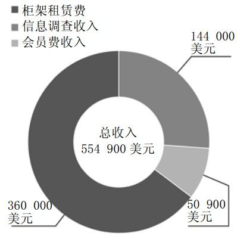

•收取货架空间租赁费 因为这家精品店的知名度，商家愿意免费给它提供展品，甚至愿意支付2000美元来展示商品两周时间。这家精品店最多能一次展示90种商品。

如果你是一个更在意关注度而非货币的信息提供者，那么免费是一个好主意。在这个阅读对象不停变化的体系里，你让提供的内容免费能够给自己带来竞争优势。就像酒鬼常说的那样，不管你跌得有多惨，你都不会跌到地板下面去。任何提供免费内容的人都具有无法超越的优势，这种优势别人最多只能和你比肩而已，因为想要比免费提供内容做得更好的话，那就只能宣告“如果你看我的博客，我会付给你钱”，但这种主意在长期来看还是难以为继的。

因此，免费正是生物学家所说的“进化稳定策略”，当没有其他人使用这种策略的时候，如果你这样做了就会收效明显，成为唯一一个提供免费的人会给你带来优势。即便其他所有人也都采用了这种策略，你这样做了依旧会奏效，因为在这种条件下，任何选择对自己的内容收费的人都将处于劣势。在免费的环境下，连那些略微有些冒进的“微支付”者都很难得到消费者的青睐，因为他们会选择免费的内容来替代。

因此，从心理学的角度（所有的经济学都有心理学的根源）来考量，如果我们能让消费者彻底抛弃头脑中“到底值不值”这样的问题，那么我们为之有所付出也是值得的。我们要留意的是，免费也有其他的心智交易成本，一方面要担心所谓的免费是否真的意味着不用掏钱，另一方面还要考虑一些非经济因素的心理成本，例如会考虑免费报纸的环境影响，或者是担心别人把自己看成是一个小气鬼（我的一个朋友告诉我，他放在门口让人可以免费拿走的家具只有晚上才会有人来拿）。但是，如果我们把这些成本暂且放到一旁，那么在交易的过程中如果能做到免费还是可以大大增加消费者的参与度。

美国风投公司首轮资金（First Round Capital）的负责人乔希·科派尔曼在研究了消费者付费的心理障碍之后，意识到我们通常在学校里所教授的定价策略简直就是一派胡言。科派尔曼指出，我们不应该关注供求曲线所决定的价格这种肤浅的经济学计算公式，其实现实中只有两种市场—免费市场和非免费市场，而两者之间有着天壤之别。

科派尔曼把这称做“一分钱的差别”。经常会有企业家找到他，向他介绍商业企划，认为自己的企业会从商品预订者身上赚到钱，觉得看过公司商品样品的5%的人都会掏腰包。但是，事实却并非如此。科派尔曼解释说：大多数企业家都掉进了一个陷阱，认为价格永远都具有弹性，也就是觉得出售的商品价格越低，对它的需求就会越多。因此，这些企业家都会画一个曲线走势像曲棍球的一张营收图表，曲线的形态往往先向上拉升，然后向右方倾斜，而支撑这个曲线走势的正是所谓“每月你只需花2美元”的商业企划。

事实在于，让售价在5美元到5000万美元之间变动并非一个新企业面临的最棘手的难题，最难的是让自己的商品零收费。对于任何一家企业而言，某项服务免费和收费一分钱之间的差别都是巨大的。

因此，从消费者的角度来看，便宜和免费之间还是有很大区别的。免费提供你的商品吧，它马上就能火起来。尽管你只是收费一分钱，但是你所处的经营环境却和不收费是冰火两重天。在收费的世界里你需要苦心经营去抓住每一个顾客。事实上，免费会开创一个市场，而收费的话只能进入另一个市场。在很多情况下，两者的区别就是免费的生意很好做，而收费的生意就根本做不下去。

### 零成本的成本

从传统的观点来看，经济学似乎对免费并没有什么值得阐述的内容，因为零价格在金钱的范畴里似乎并不存在。但是，从20世纪70年代开始，兴起了一个新流派经济学，开始关注推动人们经济行为背后的动因，我们把它称为“行为经济学”，如今行为经济学主要包括博弈理论和实验经济学。行为经济学想要解释的是：我们有些经济选择并非最理性的，但是我们为什么会做出那样的选择。

在《怪诞行为学》一书中，丹·艾瑞里描述了自己和同事所进行的实验，为的是弄明白为什么“免费”这个词“有如此大的魔力”。丹·艾瑞里写道：“零价格已经不仅仅是另一个价格了，它已经成为了一个让情感一触即发的按钮，成为非理性快乐的源泉。”尽管这样说很容易，但是对它进行测量却很难，这也是为什么丹·艾瑞里决心要去努力一番的原因。

丹·艾瑞里第一个做的是巧克力实验（注意，行为经济学家们拥有的经费和时间都有限，因此他们的很多实验往往是摊开一张折叠桌，摆上一些糖果，然后随机找一些大学生来做实验，因此看过实验结果你觉得有趣就行了，不一定非得追求严格的量化准确性）。研究人员出售两种巧克力，一种是上好的瑞士莲手工制作巧克力块，另一种是普通的好时巧克力。他们出售的瑞士莲手工制作巧克力每块是15美分（这个价格大约是批发价的一半），而好时巧克力的售价是1美分。顾客们表现得非常理性，经过一番思量之后，更加看重的是巧克力的品质而非差价，因此有73%的人选择了瑞士莲手工制作巧克力，27%的人选择了好时巧克力。

接着，丹·艾瑞里把免费引入了实验，他把每种巧克力的价格都降低了1美分。这样一来，瑞士莲手工制作巧克力每块的价格是14美分，而好时巧克力则变成免费的了。突然间，原来不怎么抢眼的好时巧克力大受欢迎，69%的顾客选择了好时巧克力。两种巧克力之间价格和质量的差价计算并没有改变，两者的差价还是14美分，但是引入了零价格之后，使得顾客的偏好产生了逆转。

在这个案例中，让人心理上发生混淆的是两种商品的对比，其中一种商品是免费的。有时候，免费的商品很能吸引人，就像在百货商店里放着的一整箱免费袜子一样，你想要多少就拿多少，这很少会给你带来什么坏处（除非你觉得在别人看来，你会显得像个小气鬼）。不过，你再想想，如果你走进百货商场的目标很明确，就是要买一双脚跟有护垫的高档黄金五趾袜，而当你来到商场的袜子区时，免费的袜子却吸引了你的眼球，最后你走出商场的时候手里拿着的并非你想要的东西（既没有脚跟护垫，也没有黄金五趾的袜子），原因只是这袜子是免费的。

免费为什么会这么诱人呢？丹·艾瑞里解释说：在大多数交易中你都能感受到好处和坏处，但是当某样商品免费时，你就忘记了它的坏处了。免费能让我们的情感迅速充电，让我们感觉到免费给我们的东西实际上要值钱得多。为什么呢？我觉得这是因为人有害怕吃亏的本能，而免费真正的魔力是和这种本能联系在一起的。当我们选择免费商品的时候，我们显然没有吃亏。但是，假设我们挑选了不免费的商品，那就存在着我们做出了一个糟糕决策的风险，因为我们担心可能会吃亏。既然如此的话，考虑到商品的可选性，我们就会选择那个免费的。

生活中和这样的案例近似的情形会在更多人身上发生，而且往往是在不经意间发生的。其中的一个例子就是亚马逊网站的免运费优惠服务。每个使用过亚马逊在线购书服务的人都知道，如果你一次购书的金额超过25美元的话，那你就能得到免运费的服务。亚马逊网站推出这项优惠服务的初衷就是，如果你本来只想花16.95美元买一本书的话，那么免运费的优惠就会让你怦然心动，想要再买一本书，使得自己一次性总购书款超过25美元。亚马逊网站推出这项优惠之后收到了奇效，在线购书者买第二本书的比率直线上升。这种趋势在几乎所有国家的市场上都表现出来了，只有法国除外。

法国有什么不同呢？原来法国网上购书者得到的送书报价和别的地方不一样，当亚马逊网站在各地推出这项优惠服务的时候，法国的亚马逊网站却失策地把运费定成了1法郎，这只相当于20美分的小额送书费大大降低了消费者购买第二本书的热情。法国亚马逊网站后来更改了这一做法，和别的国家一样也开始提供免费送书优惠。这样一来，法国的消费者也和别的国家一样，决定要在自己的网上购书筐里加进第二本书了。

（有意思的是，法国亚马逊网站的这一做法还遭到了起诉。1981年，在法国前文化部部长杰克·朗的推动下，法国出台了一部法律，禁止书商以低于标价5%的幅度来销售。2007年，法国书商联盟把亚马逊网站告上了法庭，理由是如果把运费计算在总书款中的话，那么打折幅度就会超过5%。最后法庭裁决法国书商联盟获胜，如果亚马逊网站继续这样做的话，就要每天缴纳1500美元的罚款。经过权衡比较，亚马逊网站最终决定缴纳罚款而不是取消这项优惠服务，因为在法国因免费策略每天多赚的钱要比支付罚款多得多。）

网上邮购鞋店扎珀斯（Zappos）的做法比亚马逊更甚，这家美国最大的网上鞋店会支付把鞋送到你家和从你家退回店里的双程运费。这一做法的关键就在于消除了消费者网上购鞋最大的担心，那就是鞋子有可能不合脚。扎珀斯会让你一次预定几双鞋子，这样你就可以在家里穿上试试是否合脚。你或许会喜欢其中的一双或是两双，并把其他鞋子退回，你要交的只是所留下鞋子的钱款。运费其实已经打入扎珀斯的售价里面了，它的价格在同行中也并非最低的，但是对于它的很多忠实顾客而言，享受到这种便捷就已经值了。

从心理学的角度来看，扎珀斯免运费的做法是在帮消费者减少认为网上购鞋存在的风险性。我们之所以开车去鞋店买鞋，为的就是看看鞋店里的鞋是否合脚，穿上以后是否好看。不用额外花钱就能把鞋送到家的做法，使得在扎珀斯购鞋的风险降低到了和亲自去鞋店一样低，而消费者还能得到在别家鞋店得不到的上门服务。扎珀斯的首席执行官谢家华（Tony Hsieh）说，这种经营模式唯一的问题就在于消费者会觉得订购了太多双鞋子，心中涌起了一股罪恶感，因此把鞋子给退了回来。如果他们不把鞋子退回来就不存在什么问题（销售成功了），问题在于他们担心订购之后会因有罪恶感而把大多数鞋子退回来，因而最初就不订购那些鞋子了。

我们再次发现免费模式的天敌就是害怕浪费。订购你并非真心想要的鞋子再把它们退回会让消费者觉得是种浪费，而实际上考虑到工人的劳动、运送人员的付出、运送过程中打包用的纸盒，这的确是种浪费。仅仅是免费送货并不能让消费者不去考虑价格因素，在这种情形下，尽管不需要直接从自己钱包里掏钱，他们也会考虑到无形的社会和环境成本。

行为经济学家在解释我们对免费的复杂心态时，区分了在“社会领域”和“金钱领域”里所做的决定。扎珀斯的商业模式在“金钱领域”里是免费的，但是在“社会领域”里却不是，因为我们的大脑忍不住会计算留下一双鞋子、退回5双鞋子的净社会成本。消费者进行这样的计算也是不可避免的，面对计算之后的心理纠缠，其中一些人干脆就放弃了，免运费他们也不买了。

丹·艾瑞里用另一个实验来阐明了“社会领域”和“金钱领域”的不同。他在大学宿舍的冰箱里放了6小箱可乐，也放了好多叠钞票，很快就有人拿走了可乐，但是没有人去碰钱，因为他们把可乐当成允许免费享用的，尽管他们也知道买可乐需要花钱，但却认为拿走钞票的行为像是在行窃。

### 不付出成本，就不会重视

最近，我参加了Google公司举办的一个会议，Google公司向来以提供大量免费茶点及美食而著称，其中既包括健康的长条饼干，也包括不算健康食品的软心豆粒糖。这是一次科技会议，参加者很多都不是Google公司的，大多数与会者都是学者。他们都一再到吧台区取食，面对如此琳琅满目的免费美食自然流露出了赞许的表情。会议第一天结束的时候，会场到处都能看到吃剩一半丢弃的点心袋。

如果Google公司对这么多美食收费的话，哪怕只收一角钱，将会产生怎样不同的效果呢？这种假定条件想想都觉得有趣。我相信大家会少取很多食物，更多人也会把拿的食物吃完。我也相信他们会对自己取食物的决定感到更快乐，他们或许会多想一下到底需不需要吃东西，可能会等到肚子饿了才拿东西吃。大家也不会因为自己仓促拿东西吃的决定而让人觉得那么不雅（就像我一样，我当时心不在焉地拿起一把姜糖就往嘴里塞）。

这也是免费的负面效应之一。对于不用付钱的东西，人们往往都不会太在意，因此在消费时也不会太珍惜。这样一来，免费会让人暴饮暴食，吃着碗里的看着锅里的，消费如流水，浪费，产生罪恶感而且贪婪。因为免费的存在，我们吃某样东西，有可能并非真的是因为我们需要它，而只是因为免费可以拿到而已。如果我们给免费食物标上一个价，哪怕是很低的价格，也会让大家的消费行为变得更负责任。

博客《1美分的更近距离》的作者讲述了一个故事：有一个朋友给一家慈善机构担任志愿者，这家慈善机构给时运不济的人免费提供公交卡。每张公交卡需要耗费这家慈善机构30美元，但是受助者却经常把这些卡弄丢。后来，慈善机构就定下了一条新规矩，受助者要拿到这些公交卡，需要缴纳1美元，用于以后补办公交卡用。仿佛就在一夜之间，人们丢的公交卡就少了很多。虽然受助者仅仅交了1美元，但却改变了他们对公交卡的看法。因为自己有金钱投入，所以就会更加留意不要弄丢了。尽管在受助者拿到公交卡之前就已经有人掏钱买下了它们，但是交了1美元之后让他们在使用时变得更在意了。

通过这些案例，我们发现给一个商品定价还有另一个效果，那就是不管这个价格多低，都能减少免费拿商品的人数，而且人数减少的幅度还非常大。在Google公司主办的会议上，如果与会者吃东西要付费的话，那么大家就会少拿一些点心。而那个慈善机构如果发放公交卡时收费的话，那么发放的公交卡数量也会大大减少。免费也是一把双刃剑，它是最大化推广产品和服务的上佳手段，但如果这并非你的终极目标的话（Google公司并不希望与会者吃掉的点心越多越好），那么就会产生反作用。正如其他强有力的手段一样，我们使用免费的时候也要慎重，以免产生弊大于利的后果。

### 时间/金钱衡量

某一天，你醒来之后或许会翻然醒悟，觉得自己有花不完的钱，而时间却显得特别宝贵。你也意识到自己做事的方式应该有所调整，不应该再辛苦地走到四个街区以外去用那台不收费的自动取款机，不应该开着车四处转悠比较哪个加油站的汽油更便宜，也不应该累死累活地自己粉刷家里的墙壁了。

类似的时间/金钱衡量是礼品经济的重要心理基础。在免费的网络游戏中我们经常会碰到这种情况，例如在冒险岛游戏中，你可以买到传送石之类的工具，有了传送石你就可以很快地从一个地方来到另一个地方，而不需要跋山涉水地徒步行走或是等公交车了。这些需要付费的数码工具并不能让你成为一个更好的游戏玩家，但是能够帮助你更快地成为一个游戏好玩家。

如果你是一个孩子的话，那么很有可能你有大把的时间却没什么钱。这也是推动MP3文件交换如此活跃的原因，尽管这很麻烦，但是却能找到免费的MP3文件（不过，这是违法的）。正如苹果公司掌门人史蒂夫·乔布斯的著名论断一样，如果你和别的在线用户互相分享音乐文档，那么很有可能会碰到各种问题，包括下载的文档类型电脑播放不了，找不到曲目名称，也有可能下载的歌曲并非自己想要的那首，或是下载曲目的音质不好。史蒂夫·乔布斯指出，你为了不付费听音乐，意味着“你的收入比社会的平均工资要低”。但是，如果你空闲时间很多而口袋里空空如也的话，那么在线下载免费音乐对于你是很合适的。免费对于你是一个合适的价格。

但是，当你年纪变大之后，时间/金钱这个等式就发生了逆转，花上99美分下载这样或那样一首歌曲对于你而言只是小菜一碟。你慢慢变成了一个付费顾客，成为免费加收费模式下的高端用户。

作为兼职，我还运作着一个用开源硬件的项目，名叫DIY无人驾驶飞行器（研发销售飞行器技术）。或许你对开源软件的概念比较熟悉，但是开源硬件的理念也正在兴起，硬件的范围包括电路板和Google推出的Android手机。

尽管开源硬件还是一个新兴概念，但通过这个例子，我们能很有趣地了解到如何从免费中赚钱。它给开源软件世界增添了一个新的维度，因为开源硬件是实物，和原子有关系（有真正的边际成本），而非仅仅由那些几乎可以不花钱就能复制的信息组成。

大多数开源硬件公司运转的方式是这样的：所有的商业企划、印刷好的电路板图、软件和装配指南都是免费向所有人提供的。如果你想拼装自己心爱的玩意儿（甚至还可以改进设计），那公司也鼓励你这样去做。如果你自己犯懒或是担心做不好的话，那么你就可以买一个事先装配好、肯定能用的玩意儿。

例如，我们不妨来看一看DIY无人驾驶飞行器所使用的阿都伊诺（Arduino）微电脑控制板。在阿都伊诺公司的网站http://www.arduino.cc上你可以找到所有的操作指南，你可以自己组装想要的玩意儿。但是，大多数人都选择了购买事先装配好的。阿都伊诺通过向使用微电脑控制板的公司和零售商收取版权费用来赚钱。

通过这种商业模式你可以打造一个成功的公司，就像莉默·弗雷德的阿德弗里特工业公司（Adafruit Industries）一样。莉默·弗雷德和她的商业伙伴菲利普·特隆以免费为基础建立了一个简单的商业模式，我也很“无耻”地把这个商业模式复制到了DIY无人驾驶飞行器的经营上。

这种商业模式的运转方式如下：

1.建立起一个关于某个话题的免费信息和建议沟通群体。

2.在这个群体的帮助下，设计某种人们想要的东西，并通过把最初设计的产品免费提供给这个群体作为感谢。

3.让那些有钱但是没有时间、技术或不喜欢冒险的人购买组装完的产品（几乎所有人都属于这种情况）。

4.一次次做这种生意，通过销售产品来支付成本并赚到大约40%左右的利润。

这种商业模式就像菲利普·特隆说的那样简单：“除非有个群体一路上支持我，否则我很难想象写一本书、拍一部电影或是办一本杂志能成功。每次创业都像是一个故事，人们喜欢看到它的开头、发展、结尾或是情节的某种变化。如果在某个地方他们能找到一个购买键的话，他们就会按下这个键，通过购买产品来奖赏我们的辛勤劳动。”

如果你对这样的案例仔细再想一想的话，你就会发现这是免费心理双刃剑的另一个表现。第一把双刃剑出现在我们衡量时间成本的时候。你还记得史蒂夫·乔布斯的话吗，如果你选择和别人在线交换文件而且要花时间整理乱糟糟的文档，那么“你的收入比社会的平均工资要低”。史蒂夫·乔布斯想说的是，付费99美分就下载一首歌曲能帮你省下时间（还不用烦恼一大堆是否合法和公平的问题）。

你想要付费的第二个理由在于这样可以降低选到的非自己想要的这一风险（就像免费的袜子一样）。价格和质量保证是相辅相成的，而免费的商品则没有这种保证。阿德弗里特工业公司出售组装好的电子产品，你不用担心这些产品是否能用，如果你自己拼拼凑凑则不一定能折腾出一个好用的玩意儿来。

但是，免费也能帮你注入信心。我们不妨再来看看阿德弗里特工业公司的例子。有免费的开源产品版本存在就意味着你可以细细地琢磨，而且在不冒风险的情况下进行尝试。另外，你也知道如果它不合你的需求，你也可以再进行调整。不仅如此，免费版本也吸引了更多的用户。如果知道有这么多人都对这款产品感兴趣而且遇到问题他们会帮助你的话，你就会感到心安了（在心理学上，这叫做“模仿欲望”，它是说我们想要做别人做的事，因为他们的决定让我们对自己的决定感到正确，这可以解释诸多现象，包括从众的“羊群效应”和“赶时髦的人纷纷戴货车司机帽”）。

这也是为什么免费能和付费共存而且相得益彰的原因。两者能够和很多种消费者的心态合拍，包括那些有时间没钱的人和有钱没时间的人。对于那些对自己技能有自信因而想自己操作的人，免费可以行得通；对那些对自己技能没自信想买别人做好的成品的人，付费可以行得通。免费加付费就涵盖了消费者的各种心态。

### 盗版：强加给你的免费

最后还有一种形式我们没有详细地进行阐述，那就是盗版。盗版是一种特殊形式的剽窃行为，而盗版者和盗版商品购买者往往觉得这是无罪的（我在这里并不想讨论孰是孰非的问题，我们只是想从心理学角度来看一看他们的想法）。他们的观点是，盗版并不能代替正版，而它却能使某种产品覆盖更广的人群，这些人是买不起正版的。

盗版之所以是一种特殊形式的剽窃行为，是因为它给版权所有者造成的损失是很难说清的。你拥有音乐光盘的版权，而外面有盗版光盘，盗版光盘并没有从你这里夺走什么，只是复制了你所拥有的音乐内容。这是一个重要的区别，事实上盗版并没有让你遭受损失，而是让你得到的利益少了一些。你的损失至多就是销售量下降的机会成本，因为正版作品和盗版在市场上互相竞争。

盗版是一种强加给你的免费。也许你并没有期望你的产品是免费的，但在市场上你就碰到了这样近乎免费的东西。对于音乐界和很多软件公司而言，这是每天都存在的现状。尽管有关各方尽了很大的努力来打击盗版，但是软件免费的价格已经成了不便言说的事实。

有一个软件研发商决心要找到突破口。著名的电脑游戏设计师克里夫·哈里斯将自己的游戏软件定在了自己认为合理的20美元价位上。但是，他的游戏软件还是经常会有盗版出现。为什么呢？

他在著名的科技BBS网站Slashdot上发出帖子，这个帖子引发了热议，有上万网民给他回帖，而且很少有人回帖的字数少于100字。克里夫·哈里斯说：“这就好像很多人已经等了很久想告诉游戏研发者这个问题的答案。”

他在大家的回帖中发现了让他感到非常惊讶的情况。回帖者最明显的一个共性就是都认为他的游戏（其他所有人制作的游戏）对于游戏玩家而言价格过高了，哪怕是20美元的价格也太高了。其次，任何使得购买游戏变得不容易的做法，包括版权保护、数字版权管理、复杂的在线购买手续，以及任何使得玩家想要玩游戏的欲望变得不舒服的做法，都让他们觉得用免费盗版是合理的。克里夫·哈里斯还留意到少数想法坚定的人使用盗版是因为有意识形态上的问题，例如他们对资本主义、知识产权、版权拥有者抱有敌意，或是对做一个违法者乐在其中。

网友们真诚的回帖帮助克里夫·哈里斯改变了自己的想法，他决心要改变自己的商业模式。他把自己游戏的价格降低到原先的一半，变成了10美元，也去除了原先使用的版权保护的小插件。他承诺让自己的网上商店使用更加便捷，争取能做到让玩家点一个键就可以退出页面。他决定延长自己游戏的免费试玩时间。更重要的是，他发现需要提高自己游戏的质量。这些回帖让克里夫·哈里斯心中产生了一种感觉，玩家们对他游戏的评价没有自己想象得那么高。他觉得用语言去反驳这种观点不会有任何收效，除非玩家们发自内心地觉得他的游戏更有价值。

克里夫·哈里斯的这段经验告诉我们一个道理：在数字化市场上，免费总是消费者能得到的一种选择。如果你不能爽快地给予消费者，那么其他人会找到办法免费给予消费者。因为复制数字化产品的边际成本已经降低到了几乎为零，消费者选择免费的障碍只是心理上的，例如害怕触犯法律，觉得对版权所有者不公平，消费者对于花在盗版上的时间觉得值不值得，是一些消费者有付费的习惯，担心用惯了盗版自己会对世界产生麻木。克里夫·哈里斯明白了这些心态，也打算做得更好。通过他的在线调查，他探究了盗版者的心理，他知道如果产品在某一点上足够吸引人，自然会有愿意付费的顾客涌现出来。

# 第二部分 数字化免费

## 太便宜，无所谓了：在网站上，如果某样东西每年都贬值一半，那么价格降到零就是不可避免的

导读

简而言之，“便宜得可以忽略不计”将会改变这个世界。

目前有三种科技的应用和电能一样广泛，那就是电脑处理器、数字化存储装置和带宽。这三者都已经变得太便宜了，以至于我们可以忽略不计了。

摩尔定律为什么会奏效？

“学习曲线”最早是由19世纪德国心理学家赫尔曼·艾宾浩斯提出来的，它表明如果一项任务出现的次数越多，那么下次人类再重复操作同样任务所需的时间就减少了。

在任何信息成为产品主要构成物的行业中，都会遵循学习曲线的变化规律，产品的效能在增加，而价格却在下跌。

信息流的方向就是金钱流动的方向，除了你钱包里的钞票以外，以字节为基本构成单位的信息也就代表着金钱。

就像原来电力所承担的角色一样，字节也成了工业的兴奋剂，它们让一切的成本都在降低，而效力却在不断提升。

如今，在复合学习曲线的基础之上，已经出现了一种全新的经济。这是让人感到惊讶的事，为了理解它一代人都在为之努力，并且还需要几代人的付出才能彻悟。

1954年，当原子能的利用还处于起步阶段时，原子能委员会主席李维斯·斯特劳斯在纽约市就向很多科学题材作家预言许多让人不可思议的事将要来临。人类将战胜疾病，我们将会了解衰老之谜，人类很快就能“毫不费力”地在海上和空中高速移动，很多地区的饥荒将成为历史。另外，他还有一个更著名的预言：“不出意外的话，我们的孩子在家里享用的电价将便宜得可以忽略不计。”

这是一个充满希望的年代：太空时代到来了，现代的药物战胜了古老的病痛，化学工业正赋予我们“更好的生活”而且养活了整个地球上的人，信息时代正在来临并给我们带来了无限的可能性。差不多所有能发明的东西都已经发明出来了，它们很快被冠以某个品牌，进行包装，然后推销给日益增多的已经习惯于免费的消费者。

第二次世界大战后，科技带来了前所未有的高增长繁荣时代，这已经不仅仅是某个国家的荣耀了，而成了很多国家国民的福祉。人类思想的力量和聪明的机械使得我们能从繁重的家务活中摆脱出来，也使结束战争成为可能。我们现在所要考虑的问题并非是否住在太空殖民地里，而是到太空旅行时该穿什么。《杰森一家》是部喜剧动画片，而《摩登原始人》则更搞笑。某一天我们会在太空收税或是家中拥有机器人管家并非天方夜谭，而是像我们的祖先住在山洞里一样成为现实。

战后的科技昌明使得我们迎来了从未有过的生产力迅速增长和经济高速发展。当然，现实情况并没有李维斯·斯特劳斯预计得那么理想，电价还没有便宜到可以忽略不计的程度。

尽管和煤炭相比，铀的价格相对更低，但是建造核电站反应堆和发电厂的先期投入比建造火力发电站更高。核废料是一个至今都没能彻底解决的问题。1979年美国三哩岛核电站和1986年乌克兰切尔诺贝利核电厂泄露事件发生之后，世人益发觉得建造核电站是一个昂贵而又冒险的做法。

如今，核电的价格和火力发电的价格相近，也就是说，电力供应的经济学方程式并没有发生改变。

但是，万一李维斯·斯特劳斯的预计是正确的，会出现什么局面呢？如果电能几乎变成免费的会怎么样呢？答案应该是电所能驱动的任何东西（几乎是任何东西）都会改变。我们不再会去比较电力和其他能源哪种更加便宜，而是会尽可能地多用电能，因为电能那么便宜，我们根本没有必要去担心能源使用效率。

那样一来，所有的大楼都会用电来供暖，我们丝毫不会去考虑电热片的热转换效率高不高。我们都会驾驶电能驱动汽车（免费的电能足够驱使我们去研发高效能的汽车电池储存技术）。大规模的海水淡化工厂将随处可见，把海水变为任何人想要的淡水，从而使我们能把大片的内陆荒地变为粮仓，把沙漠变为绿洲。

在农业生产中的两种主要投入要素空气和阳光都是免费的，现在如果水也能免费的话，那么我们就能生产出远远超过需求数量的粮食，其中的很多粮食都可以用来制作生物燃料。与之形成鲜明对照的是，使用价格过高而且有污染的化石燃料则会被视为愚蠢之举。这样一来，碳排放量将大为降低（使用石油和煤炭会把碳排放进入大气，而植物在它们被焚烧之前则会吸收大气中的碳），也许“全球变暖”这样的词语就不会在人类的语言中出现了。

简而言之，“便宜得可以忽略不计”将会改变这个世界。

这不可能？对于电能而言，或许确实不可能（当然大家也不能预测我们某一天能取得的利用太阳能的突破性进展）。但目前有三种科技的应用和电能一样广泛，那就是电脑处理器、数字化存储装置和带宽。这三者都已经变得太便宜了，以至于我们可以忽略不计了。

在戈登·摩尔第一次发现这一变化规律并提出摩尔定律之后的半个世纪里，这种发展趋势的速度让人感到眼花缭乱。同时让人感到意外的是，戈登·摩尔跟踪的三要素之一的电脑处理器升级速度在三者中是最慢的。与之相比，每隔一年半时间，半导体芯片所能储存的容量就能提高一倍（这就是为什么花同样多的钱，每过两年你能买到的iPod都是之前存储量的两倍）。硬盘的容量不仅变得更大了，而且运转更快。每隔一年，电脑硬盘指定区域的存储量都能扩大一倍，这就是为什么你现在用自己的TiVo数码录像机可以储存几百小时的节目。在三者之中，升级速度最快的是带宽，每隔9个月光纤的数据传送速度就能提高一倍。这就是为什么你都可以不用TiVo数码录像机了，因为你可以使用www.hulu.com这样的网站来在线随时观看你喜欢的节目。

上述每一种科技趋势都会带来必然的经济学结果，而且这些结果的作用更加明显了。这些商品的价格每隔一两年会减半，而它们的运算能力和速度却在成倍提高。这就意味着，如果指定价格的电脑处理器每隔两年性能提高一倍的话，那么在相同时间内指定性能的电脑处理器价格就会下降一半。

我们不妨来看看晶体管的例子。1961年，一个晶体管的价格是10美元。两年之后，一个晶体管的价格就降到了5美元。又过了两年，当戈登·摩尔1965年4月在《电子学》杂志上发表了摩尔定律时，晶体管的价格又降到了2.5美元。到了1968年，晶体管的售价降到了1美元。7年之后，晶体管价格进一步降到10美分。又过了7年，晶体管的价格降到了只剩1美分。

如今，英特尔公司最先进的处理器芯片里有大约20亿个晶体管，价格是大约300美元，这就意味着每个晶体管的价格大约为0.000015美分，这个价格已经低得差不多可以忽略不计了。

正是由于电脑处理器、存储装置和带宽“三剑客”的共同作用，使得网络科技变得更迅捷、更出众而且更便宜，因此如今大家可以得到YouTube这样的免费服务，能够不用多少缓冲时间就可以看到海量的免费影视节目，这些节目的清晰度也在变得越来越高，试想仅仅几年前要看到这么多节目你可得掏上一大笔钱才行。

在人类历史上，从来都没有哪种经济的主要投入要素像“三剑客”这样快速而长期地降价。它们是新型“免费”的推动引擎，而且超越了以往的市场营销伎俩和交叉补贴。在这个几乎所有东西都在涨价的世界上，建立在这三种科技因素基础之上的任何商品却总是处在降价通道中，而且还在持续降价，直到某一天降到趋近零为止。

### 期待未来更便宜

如果你所生产的东西能有规律地降价，那么你不妨尝试一下看似有些不可思议的定价方法。你可以不必按照产品如今的售价来定价，而是按照它今后的售价来定价。这个较低价格刺激的新需求会促使产品的降价趋势更早到来，从而使得预期的降价幅度比想象的更早出现，这样你就能赚到更多的钱。

例如，在20世纪60年代初，美国飞兆半导体公司（Fairchild Semiconductor）向军方出售一款名叫1211的早期晶体管，售价是每个100美元。美国飞兆半导体公司想把这款晶体管卖给美国无线电公司（RCA），并装在它超高频电视频道调谐器上。当年，美国无线电公司还在使用传统的真空管，单价仅1.05美元。

美国飞兆半导体公司的创始人罗伯特·诺伊斯和杰里·桑德斯知道，如果他们产品的销量能提高，那么晶体管的生产成本很快就能降下来。但为了能做成第一笔买卖，他们需要在没有销售量的情况下把价格立刻降下来。就这样，他们两人把晶体管的价格压低了，而且在根本不知道如何降低成本的情况下，就把1211晶体管的单价直接砍到了1.05美元。杰里·桑德斯事后回忆说：“我们当时生产这些晶体管的工厂还没有盖起来，生产流程还没有确定，但是我们已经确定了底线，之后就和客户报价1.05美元一个。我们的销售是在赌未来。”

他们的奇招收到了奇效。因为提前让价格曲线下降，美国飞兆半导体公司成功地把成本降到了1.05美元，并占据了超高频电视频道调谐器90%的市场份额。两年之后，他们又把1211晶体管的价格压低到了50美分，实现了公司赢利。凯文·凯利在《新经济时代的新规则》（New Rules for the New Economy）一书中把这种做法称为“期待未来更便宜”。

试想一下，亨利·福特在早先设立T型车工厂的时候也面对着同样的发展趋势。不过这让人觉得有些不可思议，像汽车这样的实物怎能像数字化科技产品这样迅速降价呢？其实，每年我们从地下挖掘矿石并冶炼成的金属材料会增加一倍。装配汽车的所有零配件都会像半导体芯片一样变得越来越便宜，汽车的雨刷器和变速器也遵循着类似的摩尔定律。工人们也要同意每年都减薪一半，否则一半的工人会被机器人所代替。

通过把手工制作转变成为由电力推动的生产流水线，亨利·福特降低了用工成本。通过把为客户专门定制汽车零部件转向生产标准化的零部件，亨利·福特再次降低了劳动成本并卖出了几百万辆批量生产的汽车。

但是，亨利·福特划时代的生产线技术和批量生产所体现的成本曲线显著下降趋势并没有延续很久。汽车的性价比还在提高，但是提高的速度已经减缓了，每年也就提高百分之几而已。我们现在从地下挖掘矿产的能力已经提高了很多，现在将近一半的汽车工人也已经由机器人所代替，但是这样的变化并非在一夜之间发生的。汽车已经变得更便宜、性能更优越了，但是变化的速度大大落后于数字科技的变化节奏。如今，汽车依然是一件昂贵的工业品。

从环境的角度而言，这倒也不是坏事。如果实物工业产品也像微芯片降价得那么厉害的话，那么引发的工业产品过剩导致的“负外部效应”将会很严重。如果你看过皮克斯电影公司出品的电影《E墙》（Wall稥），人类饱受垃圾堆积如山之苦，那你就能意识到这一问题有多严重。

但是在数字化世界里，我们所创造出的充裕产品主要都是生命短暂的信息。包括电子、光子和磁通量在内，没有什么能阻止信息产品加倍涌现并发挥显著效果。结果正如戈登·摩尔指出的那样令人惊叹：“摩尔定律和墨菲定律（Murphy's law）是互相违背的，因为我们看到了一切都在变得越来越好的趋势。”

### DVR怎么能免费呢？

Ryanair航空公司重新界定了航空业的定义，因为它更关注的不是出售机舱座位，而是销售在飞行途中的其他服务。同样，Better Place公司也开创了汽车业的新格局。在一个高油价时代，人们意识到汽车的使用成本超过了它的购置价格，因为我们还要支付高昂的油费，有可能每年还要再掏上3000美元。Better Place公司借鉴了手机业的经验，决定免费送出汽车，收取的费用是根据你的行驶里程来计算的，而这笔费用比你使用传统汽车要低。

只要油价的上涨速度超过电价的上涨速度，那么这种模式就会奏效

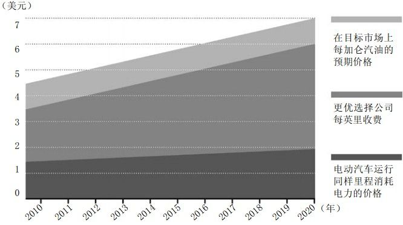

Better Place公司之所以能采用这种战略，是因为它所使用的汽车都是电动汽车，电能的价格比汽油要便宜。如果你所居住的地方有Better Place公司的分部（目前在以色列、丹麦、澳大利亚和旧金山湾区），你和公司签署一项为期三年的合约，那么公司就可以免费租给你一辆车。你可以在家或是在单位用一种特殊的充电器来给汽车电池充电，也可以到汽车上的GPS系统给你指出的公共充电站去充电。如果你急着赶路，那么你可以去汽车服务站，那里的工作人员会给你更换汽车电池板，更换的速度比你在传统加油站等候的时间还要短。

在Better Place公司目前最大的市场以色列，每加仑的油价比让汽车行驶同样里程所需的电价要贵3美元。在欧洲等油价更高而可再生能源丰富的市场，两者的差价能达到4美元。Better Place公司正是使用这一差价来补贴自己的汽车。

公司预见未来会有两类消费者：第一类是掏钱买车而免费得到电池的顾客，第二类是两者都不想掏钱的顾客。公司希望第一类顾客能够体会到省钱的感觉，因此把每英里的使用价格定得比油价要低。公司相信，油价的上涨速度会比电价上涨的速度更快，因为石油的储量是有限的，而可再生的电能是无限的。对于一位每年要驾车行驶10000英里的顾客，每英里的油耗可能是0.15美元，Better Place公司把每英里的使用费用定为0.12美元，电价的实际花费是每英里2美分，因此每英里公司都能赚到10美分。那么这一个顾客每年就能给公司带来1 000美元的赢利，这就可以用来支付汽车电池的损耗（一块电池最多可以用上10年）。随着油价和电价的差价幅度越来越大，Better Place公司将能够更快地挣回在汽车电池上的投入并赚到更多的钱。

对于第二类顾客，Better Place公司的每英里收费就要更高一些。例如，对于一位每年驾车行驶15000英里的顾客，每英里的使用收费是0.5美元，这就足够用于支付汽车和电池的损耗了。随着汽油的相对价格变得比电价更高，那么这种买卖就更划算了。

公司这种运营的非经济收益则更大，因为公司的电动汽车不会排放出温室气体，也不需要依赖进口的石油资源。这一优势就使得公司有条件申请各项政府和公司补贴，从而能够帮助它支付开拓新兴市场的前期投入。这样一来，公司就可以把业务扩展到经济成本划算的其他市场。

### 摩尔定律为什么会奏效？

实际上，大多数工业流程在一段时期中规模效应会变得更好，影响它们的正是所谓的“学习曲线”。因为学习曲线的存在，半导体行业中的工业流程变化得比其他行业更快而且延续时间更长。

“学习曲线”最早是由19世纪德国心理学家赫尔曼·艾滨浩斯提出来的，用来研究他观察到的人们在经历反复重复后记忆力提高的表现。但是，这一术语很快就有了更广泛的含义。维基百科的词条对这一术语是这样解释的：“它表明一项任务出现的次数越多，那么下次人类再重复执行同样任务所需的时间就减少了。”这种因果关系早在1936年美国莱特·帕特森空军基地就得到观察实例，基地的管理人员通过计算发现，每一次飞机总装配数量增加一倍，总用工时间就会减少10%～15%。

20世纪60年代后期，波士顿咨询公司（BCG）开始关注科技行业的表现，并发现行业内的业绩提高幅度并非简单的学习曲线所能解释的。学习曲线更多的是关注人类的学习表现，而在科技行业中的重要进展似乎与规模增加关系更密切。随着大批量制造的产品出现，产品产量每增加一倍，其成本就能有规律地降低（10%～25%）。波士顿咨询公司把这称为“经验曲线”，用来描述机构学习能力的提高，内容涵盖行政效率的提高、供应链优化以及工人学习能力的上升。

从20世纪70年代开始，在新兴半导体产业中的价格下降幅度甚至超过了经验曲线所能解释的范畴。早先研制出的半导体产品正以波士顿咨询公司提出的价格最大降幅在持续下跌，在10年的时间里，美国飞兆半导体公司1211型晶体管的销售量猛增了4000倍，也就是说翻了12番，按照经验曲线的解释，这会使得这种晶体管的价格降到原来的1/30。但实际上，这种晶体管的价格降到了原先的千分之一。显然，还有经验曲线没能解释的东西在起作用。

半导体产业和其他工业所不同的地方也代表了很多高科技产品的共性：其脑力和体力投入比相当高，也就是说生产这些产品更多的是依靠智力而非原材料投入。毕竟，微芯片都是由硅土精巧地拼装在一起。正如乔治·吉尔德在《微观宇宙》一书中指出的那样：如果原材料在某种产品的生产中变得微不足道的话，那么提高产量就很少会遇到原材料方面的瓶颈。半导体产品就代表着一种摆脱了原材料束缚的经济模式。

换而言之，思想几乎能够不受限制和成本约束地进行复制。其实，这已经不是什么新事物了，专利之父托马斯·杰弗逊（他也是很多其他事物的创始人）早就极其精辟地指出：接受我思想的人，会从我这里得到教益，但却不会影响到我；就好像有人在我面前点亮了一根蜡烛，自己得到了光亮，也让我眼前一亮。

这就是说，思想是无穷充裕的商品，能够以几乎零边际成本进行复制。思想一旦产生，就会传播至海内外，使得它所接触到的所有东西都变得更丰富，现代社会把这种思想传播叫做“记因” <sup>[1]</sup> （memes）。

而在商界，公司通过知识产权法的保护来人为地制造一种思想的稀缺性，从而实现赢利。这也就是专利、版权和商标权背后的秘密，力争让思想的自然流动停滞足够长的时间以使公司赢利。这些权利保护法的出现使得发明家有经济动因去创造，并在固定的一段时间内有权进行垄断收费，这样他们就能得到自己思想成果的投入回报。但是专利会有过期的一天，商业秘密也将公之于众，思想的传播也将不再陷于停滞。

如果更多的产品是由思想而非物质构成的，那么产品降价的速度就会更快。这也是数字化世界因为产品充裕而导致免费的根源，如今我们把它简称为摩尔定律。

这种变化趋势并非仅仅局限于数字化产品。在任何信息成为产品主要构成要素的行业中，都会遵循这种学习曲线的变化规律，产品的效能在增加，而价格却在下跌。以医药行业为例，最初我们的理解是“我们不知道药物为什么会起效果，它自己就发生疗效了”（因此我们说“发现”药物也是有道理的），后来转变到我们开始研究分子生物学的基本原理（“现在我们知道药物发挥药效的原理了”）。隐藏在医药科学背后的动因是信息，而观察到的疗效则是表象。你一旦能够了解医药学的基本原理，那么就能够用更快的速度生产出更好的药物。

每隔1.9年，DNA序列分析的价格就会下降50%，很快我们个人的基因排序将会成为另一个信息产业。科技软件将会提供越来越多的医药和诊断服务，和医生日益昂贵的出诊费用不同，这些软件的价格将变得越来越便宜，直到趋近为零。

同样，专家预言纳米技术也将从生产性行业变为另一个信息产业，因为客户定制的分子自组装纳米技术应用日益增多。随着能源利用的重点从燃烧化石能源转向了把太阳能转变为电能的光伏电池，或是研制可以把草变为乙醇的酶，新能源也将成为另一个信息产业。在上述这些和电脑运算关联不大的产业都显示了摩尔定律的威力，一旦这些产业发展的主导因素从体力转向了脑力，它们就出现了增长迅猛的势头，但是产品的价格却在持续走低。

### 米德定律

尽管摩尔定律是以戈登·摩尔的名字命名，但是最早提出摩尔定律相关内容的并非摩尔，而是美国加州理工学院的卡沃·米德（Carver Mead）教授。卡沃·米德是最早关注到摩尔定律所提出的晶体管之类的产品产量增加，就会引起其价格下降现象的。卡沃·米德指出，如果给定价格的电脑处理能力每两年提高一倍，那么这一价位的电脑处理装置同期就会降价一半。更重要的是，他是第一个思考我们使用数字科技究竟意味着什么的人，他还发现我们的想法是完全错误的。

20世纪70年代晚期，卡沃·米德在加州理工学院教授半导体设计课程，他给我们现在所熟知的超大规模集成电路确定了原理，这也就相当于给我们今天的电脑世界下了定义。和戈登·摩尔一样，他也认为数字化产品每隔一年半性能就会提高一倍，而且这一趋势在可预见的将来都会一直延续下去。引起这一趋势的不仅是通常的学习曲线和经验曲线，也受他提出的“复合学习曲线”的影响，复合学习曲线是各种学习曲线和新发明的集合。

半个多世纪以来，每隔10年左右，半导体研究专家就会提出能让这个产业再次进入价格曲线迅速下滑周期的重大创新成果。每当某种生产流程出现了改进产业效率能力下滑的局面，就会更快地产生提出某种全新的、更好观念的动力。正如美国物理学家理查德·费曼所说的那样，在原子世界的“底部还有很大空间”，这开创了20世纪晚期的新物理学时代，虽然让人有些不可思议，但是研究人员总是能有规律地找到这样的新发现。

每一次不论是发现某种新材料、新的刻录技术、新的芯片结构或是诸如计算机并行处理这样全新的技术领域，学习曲线就又回到倾斜度最大的起点。如果你把整个电脑行业中的这些创新和学习曲线融合到一起，那么你就得到了摩尔定律以及历史上从未见过的成本下降趋势。和其他你能列举出来的电脑处理器一样，晶体管的价格也在不可避免地走向零点。

卡沃·米德意识到，这一经济效应还带有道义上的责任。如果晶体管的价格便宜到了可以忽略不计的话，那么我们就会不用计算、不用在乎晶体管的价格了。我们的态度就会从认为这是一种稀缺物质而爱惜它，转变成认为它们是取之不尽、用之不竭的。换而言之，一旦我们认为它们是用不完的，就会开始“浪费”它们。

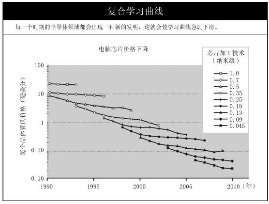

“浪费”是个贬义词，用在20世纪70年代的IT世界里显得尤为准确。整整一代的电脑专家在学校接受的教育都是要小心谨慎地分配昂贵的计算机资源。在电脑发展还处于大型主机装在玻璃房实验室里的年代，这些系统管理员可以运用手中的权力，来选择用谁的程序驱动昂贵的计算机。他们的任务是保护好晶体管。他们不仅决定哪些程序有价值，还鼓励程序员设计出使用计算机时间尽可能短的软件。

这些系统管理员统治着早期的信息时代。如果你想使用一台电脑，那么你就必须征得他们的允许。这也就意味着你要写出合乎他们制定的利用IT资源标准的软件。这些软件要致力于解决商业目标，能高效地利用中央处理器周期，而且功能不应该太烦琐。如果你的软件通过了系统管理员的测试，那么他们会允许你刷卡进入计算机工作室，两天之后返回给你打印出来的软件错误信息，这样你就可以重新改进软件设计了。

这就使得早期的编程者致力于使用代码改进他们的核心算法，但却很少关注用户界面。这是一个命令行时代，软件专家的职责就是让软件尽量节省电脑的中央处理器，而非其他目标。

当时的电脑工程师们在一个方面懂得摩尔定律的效力：他们知道摩尔定律会使比当时使用的更小巧、更便宜的电脑出现。如果想到电脑会变得小巧而便宜，那么自然也能想到普通家庭也会购买电脑放在家中。但是，普通家庭为什么会需要电脑呢？20世纪60年代后期的电脑专家们绞尽脑汁地想了一番之后，只想出来了一个理由—给家里存放菜谱。世界上第一代个人电脑是霍尼韦尔公司（Honeywell）在1969年生产的，当时就是用做厨房里的时髦用品，而这台电脑还拥有综合计算器空间。当年的美国精品百货商场内曼·马库斯公司的商品目录上就有霍尼韦尔的电脑，顾客可以以10600美元的打折价买到这款电脑，而这款电脑唯一的信息输入办法是旋开电脑面板上的开关，然后家庭主妇必须用16进制往里输入内容。真不清楚，当年这种电脑有没有卖出去一台。

而卡沃·米德则对编程专家提出了“浪费”的问题，弄得这些专家抓耳挠腮，百思不得其解，怎么会浪费电脑功效呢？

### 滚动的鼠标

20世纪70年代后期，施乐公司加州帕洛阿尔托研究中心的阿伦·凯让这些编程专家们找到了方向。阿伦·凯并没有把大部分精力用来让晶体管为核心处理功能服务，而是用于研制自己的概念电脑“动能工作台”（Dynabook），这款电脑独辟蹊径地利用晶体管来提供屏幕上具有视觉感的功能，例如画图标，用鼠标来操作指示器，把屏幕分成几个窗口，甚至添加了没有任何实际功能、只求好看的动画效果。

那这种养眼的奢华设计是什么目的呢？为的是给普通用户包括孩子创造出操作更便捷的电脑。阿伦·凯在图形用户界面方面的努力成了后来施乐公司阿图电脑、苹果公司麦金托什电脑的灵感源泉，它们通过向我们展示电脑世界而改变了全球。

阿伦·凯意识到，科技专家的职责并非想明白科技的合理用途。相反，科技专家的注意力要放在把科技产品变得便宜、容易操作、随处可见，这样每个人都可以使用，而这种科技产品也能到达无处不在的程度。我们这些消费者自然会决定科技产品该具体用于什么用途，因为我们每个消费者都是与众不同的，我们有不同的需求、不同的观念、不同的知识背景以及和外界打交道的不同方式。

阿伦·凯通过向世界展示如何使电脑普及化，从而让摩尔定律在电脑领域也发挥了效力，使得电脑走出了原来的玻璃房实验室，走进了千家万户、汽车和口袋里。大家共同探索电脑潜在利用空间的努力给我们带来了数字化世界的一切，包括数码照相机、电脑游戏、TiVo数码录像机和iPod播放器（有意思的是，存放菜谱并非是现在很多电脑使用者的重要用途）。

电脑工程师们给我们带来了互联网和网络的技术框架，传输控制协议/互联网络协议，“http://”也出现在了我们的日常生活中，不过决定到底该怎样利用网络的人是我们自己。电脑科技是免费向所有人提供的，其实正是我们这些使用者在体验电脑的各种用途，并用我们自己的知识、观念和自己本身在使电脑变得更流行。电脑科技创造了一个空间，但是给这个空间里填充内容的则是我们自己。

当然，便宜的科技并非免费的科技。功能强大的电脑在阿伦·凯时代很昂贵，现如今也一样昂贵，关于这一点，某位刚刚花了六位数的高价新增一排服务器的可怜的首席信息官是最有发言权的。如果你从购买的总价格来看，科技产品并不会给你一种免费的感觉。但是，如果我们从传送网络数据的粗管角度来衡量，那么科技产品背后的经济学公式确实已经变了。昂贵的硬盘装置（高固定资产成本）可以为几万电脑用户服务（低边际成本）。

如今，网站最在意的是登录或浏览者人数，它们想尽一切办法来给自己集中化的资源找到尽可能多的用户。随着电脑科技日益发达，网站可以让更多的用户来分摊成本。这并不是指数据中心成排的设备成本，而是设备能发挥什么功用。年复一年，电脑如有神助，价格越来越低，而功能却越来越多，使得我们每个人所消耗的科技边际成本趋近于零。

卡沃·米德和阿伦·凯所预测的趋势对于建立在电脑基础上的行业影响深远。这就意味着软件编程工程师可以摆脱节省内存和中央处理器周期的烦恼，能够致力于让软件发挥更大作用，并关注用户界面和娱乐等新兴市场这样的高端功能。结果是电脑吸引了更多的人成为用户，这些用户则发现了电脑的更多功能。正是由于对大幅贬值后的晶体管的肆意挥霍，这个世界已经改变了。

有意思的是，晶体管（存储器或带宽）并不一定需要完全免费才行。从某个角度而言，它们已经足够便宜，大家对它们的价格也能忽略不计。古希腊哲学家齐诺（Zeno）则对相关概念提出了略有不同的解释。齐诺指出了一个两分法悖论：你要跑向一堵墙，在你跑的过程中想要把离墙的距离缩短一半，接着又把这个距离缩短一半，以此类推……但是，如果你无止境地把离墙的这段距离平分下去，你怎样才能够到达那堵墙呢？（答案是你不可能碰到那堵墙。一旦长度精确到了纳米级，由于原子间强劲的斥力，你几乎不能再把距离均分下去。因为存在着这样明显的数学悖论，因此牛顿为了解决它创立了微积分学。）

在经济学上，也存在近似的悖论：如果单位技术成本（“兆字节”或“每兆每秒”、“每千浮点次运转每秒”）每隔一年半将会下降一半的话，那么什么时候这个价格才能和零点接近得让我们能忽略不计呢？答案是：几乎总要比你想象得更快。

卡沃·米德的理解是，当商品的价格趋近于零时，人们的心态会发生逆转。尽管商品的价格并非完完全全是零，但是价格下降幅度已经足够大，消费者已经可以把它们当成是免费的。也许不像李维斯·斯特劳斯预言得那样便宜得可以忽略不计，但是价格足够便宜得让人不足挂心。

### 铁和玻璃

半导体行业的变迁基本体现了数字经济的图景，不过正如我在上文中说过的那样，两种相关科技—存储器和带宽的价格趋向零的变化速度比半导体更快。

数字存储器的工作原理并非把硅芯片蚀刻成越来越细的条纹，而是通过各种方法在金属盘面装上磁粒子。这是你个人电脑硬盘或是iPod播放器的工作原理：一个小小的磁头在上方盘片中几个原子大小的磁道内转动，定位盘片上的数据，把磁粒子的不同极性转换成不同的电脉冲信号，并利用数据转换器将这些原始信号变成电脑中的1和0这些数据（你正在制作的PPT文件或是刚下载的影视节目都是这样的一些数据）。如果要想让盘面上所能承载的字节更多，就要让磁道变得更窄，那就是要使用更小但功能更强大的磁头，在离盘面更近的距离里读取数据，而这个盘面上的磁粒子也要更小但磁性更强。

要实现这样的目标，主要就是靠精细的机械制造工艺，在使用含铁的能盛放磁粒子的盘面上操作的精确程度让瑞士手表工业都自愧不如。尽管存储器的物理原理和半导体不同，但是卡沃·米德提出的复合学习曲线依然适用于存储器领域。尽管存储器领域和摩尔发现的半导体规律关系不大，但是随着储存数据能力的增加而成本下降的速度比摩尔定律还要快。我们再次看到这是一个思想和原材料投入比值很高的行业，因此创新层出不穷。

带宽所涉及的物理和材料科学是不一样的，把数据长距离输送主要是依靠光子而非电子。光开关将二进制码转换为不同波长的激光脉冲，这些不同波长的脉冲可用希腊字母λ来表示，它们会在玻璃光纤中传播。玻璃光纤里没有杂质，因此数据可以传送数百英里而没有任何丢失或受损。

带宽领域里的基础科学是光学，而非材料学或是制造工艺学。但是，在这个领域里，智力财富和原材料投入的比值也是很高的，因此创新也是层出不穷，从而勾画出行业新的改进曲线。和卡沃·米德提出的复合学习曲线趋势一样，光纤网络和光开关效率的提高速度比电脑处理器和存储器的改进速度还要快，它们的性价比不到一年就会提高一倍。

### 充裕能做些什么？

便宜得可以忽略不计的带宽带给了我们YouTube网站，它正在让传统的电视行业发生革命（某一天或许会摧毁这个传统行业）。便宜得可以忽略不计的存储器给我们带来了Gmail邮箱和它没有上限的容量，更有TiVo数码录像机、Flickr和MySpace网站以及iPod播放器。

在iPod播放器产生之前，没人想过要把自己所有喜欢的音乐都放进一个口袋，但是苹果公司的工程师们懂得充裕储存器的经济学含义。这些工程师们发现，对于同样价位的硬盘，它的储存空间扩大速度比电脑处理器性能提高的速度更快。推动iPod播放器产生的并非储存海量音乐的需求，而是物理学和工程学。借用卡沃·米德的说法，苹果公司的工程师们“倾听了科技的声音”。

苹果公司的工程师们在2000年就留意到，日本东芝公司宣布很快就能研制出只有1.8英寸大小、容量却高达5G的硬盘。5G的硬盘到底有多大？如果你进行一番数学计算的话，那就相当于在比一副扑克牌还小的硬盘上储存1000首歌。苹果公司就搭上了新兴科技的帆船，推出了这款产品。产品供应自然找到了它的需求，消费者也许并没有想过要把所有的音乐都带在身上，但是当他们有这个机会时，那么这种便利马上就显得难以抗拒。如果你能把所有音乐都放在一个播放器里，为什么还需要费脑子去想要听什么歌曲或是该上传什么歌曲呢？

在处理器、储存装置和带宽三种科技的合力作用下，网络世界就诞生了，几种充裕性汇成了一股合流。20世纪90年代末网络泡沫时期有一个笑话，说在互联网世界里只有两个数字—无限大和零。至少从泡沫破灭后股价市值下挫来看，无限大这个数字是不准确的。但是第二个数字则一直存在而且活力充沛。网络世界已经成了免费的沃土，这并非因为观念上的缘故，而是因为经济学的原因。价格已经下降到了边际成本，而任何在线东西的边际成本都趋近于零以至于可以忽略不计了。

正如计算机行业研究人士花了几十年时间才明白摩尔定律的影响，我们还需要再花几十年时间才能明白网络同带宽和储存装置连接之后的综合效果，带宽和储存装置是零价格域里的另两驾马车。

当李维斯·斯特劳斯预测电价将低到可以忽略不计时，电力已经同经济的每一部分都连通了。想想这种充裕局面将会带来什么，真是让人感到眼界大开。如今，信息就像电力一样，几乎和经济的每一部分都发生了联系。

信息流的方向就是金钱流动的方向，除了你钱包里的钞票以外，以字节为基本构成单位的信息也就代表着金钱。信息是我们沟通的方式，我们打电话的时候嘴里刚说出话来，声波就被转换成了电磁波数据。我们现在观看的电视和电影以及听的音乐都是数字制式的，它们就像字节世界中的其他所有事物一样，正在改变自己的制作方式和我们的消费方式。只要看一看电网的调度系统、输电终端以及给原来单向输电增加互动性的智能电网，我们就能发现电力行业也在变得越来越像一个信息产业了，而智能电网马上就能自动管理用电需求，从太阳能板中接收电子并向电动汽车输入电子。

字节所接触到的每样东西也都具有了独特的经济属性，变得更便宜、更好用、更快捷。我们可以生产一个数字化的防盗自动警铃，现在只需要准备一个传感器、连接网络的通信节点，以及几乎免费的储存设备、带宽和电脑处理能力。这也是为什么我们愿意打造网络化的东西，因为可以把东西马上就变得规模更大、运转更快，而且速度提高的步伐还在不断变大。

就像原来电力所承担的角色一样，字节也成了工业的兴奋剂，它们让一切的成本都在降低而效力却在不断提升。不过和电能为工业提供一次性的转型机遇不同，字节年复一年地都在帮助提高工作效率，这就像一场延续的变革一样，我们每一代人都会见到价格下降一半而性能又提高一倍的设备，这些设备给我们带来了全新的可能。

但是，我们在修经济学课程时老师讲的第一课说“价格是受供给和需求决定的”，难道这说法不对吗？不用担心，这一说法依然成立。供需关系决定在任何时间节点上的商品价格。但是，从长期的角度来看，价格趋势是由技术本身决定的，某种商品数量越多，那么价格就会越便宜。萨伊定律（根据提出者18世纪法国经济学家让·巴蒂斯特·萨伊命名）指出“供给创造需求”，这也就是说如果你生产出现有数量100万倍之多的晶体管，那么世界自然会找出它们相应的用处。

在任何时间节点上，世界所需要某种商品的数量都会比现有产量略微多些或略微少些，现时的价格也会反映这一点。但是，从长期来看，降低的生产成本会确保产品总体价格趋势是下行的，货币供需的失衡状态会在这根价格曲线上造成一些小波动，但是这根价格曲线的大趋势是趋向零点的。

如今，在复合学习曲线的基础之上，已经出现了一种全新的经济。这是让人感到惊讶的事，为了理解它一代人都在为之努力，并且还需要几代人的付出才能彻悟。但是，最先认识到这种新经济影响的并非经济学家，而是来自火车模型疯狂收藏爱好者的私下研究……

[1] 记因，指一个人记忆活动的模式，这一模式又可复制到另一个人身上。—编者注

## “信息想要免费”：界定数字化时代的一个小插曲

导读

信息具有二重性：

“一方面，信息想要变得昂贵，因为它很宝贵，在恰当的地点得知恰当的信息，能够改变你的人生；而在另一方面，信息也想要变得免费，因为发布信息的成本一直在下降。因此，这两种趋势在互相牵制。”

这也许是网络经济中最重要而又误解最深的一句话了。

它们之间的矛盾，统一在大规模定制这个矛盾的术语中。大规模使信息走向免费，商品化的信息（人人都能得到同样版本）想要变得免费；而定制走向增值，客户定制化（你得到对你而言独特、有意义内容）的信息则想要变得昂贵。

充裕的信息想要变成免费，而稀缺的信息想要变得昂贵。

1984年，记者史蒂芬·列维出版了《黑客：计算机革命中的英雄》（Hackers：Heroes of the Computer Revolution），该书详细讲述了这个在众人眼中龌龊的亚文化群体，但是这个群体不仅创造了个人电脑（并最终催生了互联网），而且也创造了与之共存的独特社会精神。史蒂芬·列维在书中列举了七条“黑客道德准则”：

1.可以随心所欲地摆弄电脑—如同对世间万物的运转变迁可以任意追根究底一样。

2.永远遵从电脑操作的指令。

3.所有信息都应该是免费的。

4.不迷信正统，促进电脑技术的多元化、分散化。

5.评价黑客应依据他们的技术水平，而不是他们的学位、年龄、种族或社会地位等虚浮的标准。

6.计算机可以创造艺术和美感。

7.计算机能让人们的生活变得更美好。

史蒂芬·列维提出的第三条准则可以追溯到1959年，当年彼得·萨姆森在麻省理工学院创立了技术模型铁路俱乐部（TMRC）。该俱乐部是一个追求原创性的团体，而且也是人类迄今历史上最招人厌烦的团体了。该团体在维基百科上的解释词条说明了这一点：

这个俱乐部由两个团体组成：一个是对火车模型和景观设计感兴趣的团体；另一个团体则是电子信号和动力小组，他们负责研制让火车模型运转的电路板。电子信号和动力小组创造了很多当今的流行语，其中就包括“黑客”一词，这个小组最后把兴趣的落脚点放在了电脑和编程上。他们最初受放置在麻省理工学院26号楼、价值数百万美元的IBM704大型主机吸引，但是使用这台主机的权利和时间往往都被更重要的人所占有了。当俱乐部成员杰克·丹尼斯介绍他们使用放在林肯图书馆、用长期贷款购买的、价值300万美元的TX-0电脑时，这个团队开始真正迷恋上了电脑。他们会待在TX-0电脑的房间一直摆弄到夜里，希望某个预约了来使用电脑的人不会出现。

史蒂芬·列维在书的最后简单地提到了凯文·凯利和斯蒂沃特·布兰德。凯文·凯利后来成了《连线》杂志的执行总编，现在也一直担任着杂志的资深顾问；斯蒂沃特·布兰德曾是“快乐逍遥汉” <sup>[1]</sup> （Merry Prankster）成员，创立了最有影响力的反主流文化杂志《全球目录》（Whole Earth Catalog）并担任总编，1983年，斯蒂沃特·布兰德收到130万美元的预付款让他编写《全球软件目录》一书。《全球软件目录》出资人的目的就是想要让这本书成为新兴个人电脑文化的导航灯，就像20世纪六七十年代美国出现的回归乡村运动热潮一样。

当凯文·凯利和斯蒂沃特·布兰德发现了史蒂芬·列维的书后，就打算召开一个会议，把三代黑客都汇集一堂。正如后来凯文·凯利告诉斯坦福大学通信专业的弗雷德·特纳教授的那样，他和斯蒂沃特·布兰德想看一看黑客是否能成为“一种大众文化的先驱”，他们也希望“看到或是让与会者来制定黑客的道义标准”。

1984年11月的一个周末，大约150名黑客从各地赶来，聚集在美国旧金山金门大桥北部马林滩头的克洛科海特堡。参与这次周末会议的有苹果公司的创始人史蒂夫·沃兹尼亚克，超文本的发明者之一泰德·尼尔森，理查德·斯托曼（麻省理工学院的电脑科学家，后来创立了自由软件基金会）和绰号为“嘎吱船长”的西奥多·德雷珀（因为他发现用麦片盒里作为奖品的哨子向电话话筒吹声，可以免费打电话）。除了提供食宿以外，凯文·凯利和斯蒂沃特·布兰德还给与会的黑客提供了电脑和视听设备。

在这次会议上，两个主题多次出现：一个是如何确定“黑客的道义标准”，另一个是探讨电脑行业中将会出现哪些新的商机。正是在这次会议上，斯蒂沃特·布兰德提出了史蒂芬·列维提出的七条准则中的第三条：

一方面，信息想要变得昂贵，因为它很宝贵，在恰当的地点得知恰当的信息，能够改变你的人生。而在另一方面，信息也想要变得免费，因为发布信息的成本一直在下降。因此，这两种趋势在互相牵制。

这也许是网络经济中最重要而又误解最深的一句话了。

斯蒂沃特·布兰德这番话尤其重要的是它在科技和思想之间建立起了纽带。摩尔定律讲的是电脑实物载体的价格变化，而信息则是建立在这种载体之上的无重量的商品。物理学决定了晶体管某一天会降价到零，但是这些晶体管所处理的字节（信息）的价格则可能有升有降。

也许信息会变得更便宜，因为复制信息是如此简单。也许信息会变得更昂贵，因为电脑信息的完美处理会使得信息的质量更高。实际上，正是这一点才使斯蒂沃特·布兰德做出了上述评论，他的评论中指出了两种极端出现的可能性。

大多数人只记得斯蒂沃特·布兰德这番评论中的半句“信息想要变得免费”。这和彼得·萨姆森当年对史蒂芬·列维所说的两种理解相差很远。首先，在彼得·萨姆森看来，最重要的免费还有自由、“不受禁锢”的含义，在当年的主机时代也就意味着该让谁使用主机。不过，斯蒂沃特·布兰德后来提出了和这本书相关的免费含义，也就是零价格的意思。

第二个区别在于，斯蒂沃特·布兰德把彼得·萨姆森原来所说的“应该会”改成了“想要”。斯蒂沃特·布兰德说法的一大特点就是从人类中心说的角度，赋予了信息以欲望，而非提出了自己的政治立场（用“应该会”的措辞）。这种价值中性的措辞让“免费”摆脱了理查德·斯托曼这些狂热黑客的定义，他们想要保护一种信息强行开放的观念。斯蒂沃特·布兰德的这种表述就让人觉得信息“免费”像是一种自然力量，就好像生命想要有张力或是水自然会往低处流一样。

斯蒂沃特·布兰德的这番话之所以会被误解，是因为人们只记住了一半，而另一半“信息想要变得昂贵，因为它很宝贵”则被人忽视掉了，也许是因为人们觉得这两句话像是一个悖论，或是话说得有些重复。或许，我们换一种表述方法能更好地理解这段话：

商品化的信息（人人都能得到同样版本）想要变得免费，而客户定制化（你得到对你而言独特、有意义内容）的信息则想要变得昂贵。

不过，即便是这样的概括方式也并不完全准确。如果按照这种说法，那么Google搜索引擎不是正对你的问题提供有意义的独特、客户定制化的解答服务吗？我们再换一种说法：

充裕的信息想要变成免费的，而稀缺的信息想要变得昂贵。

按照这种说法，我们就根据信息的“充裕性”或“稀缺性”来计算其边际成本。能够以低价复制和传播的信息想要变成免费的，而那些边际成本高的信息则想要变得昂贵。因此，你可以免费下载这本书的电子版（充裕的商品化信息），但是如果你想让我飞到你所在的城市，并准备一个关于你从事的生意的相关演讲，那么我也愿意效劳，不过你要为我（稀缺）的时间支付报酬。我膝下有好几个孩子要养活，而现在的大学学费丝毫都没有变便宜的迹象。

### 布兰德自己的解释

不过，这只是我的解释。鉴于斯蒂沃特·布兰德这番洞见的重大影响力，我找到了他本人求证当年说这番话是什么意思。

我首先提出的问题和他这个经典表述有关。首先，我问他：为什么要把黑客道义标准中关于信息的表述从“应该会”改成了“想要”？

斯蒂沃特·布兰德说这有两个原因。第一个理由是出于语言学的角度，他觉得用“想要”听上去更舒服，“用‘想要’，而不用让人联想到指手画脚的‘应该’，听上去更有诗意也更有深意”。第二个理由则更加重要：“用了‘想要’，就使得关注问题的角度从你自己转变到了现象本身，而现象就是这种特殊形式的信息共享会带来价值。”换而言之，这在更大程度上是信息的一种功能，而非你或我所能做出的某种决定。我们个人对信息应该是收费还是免费赠送的态度并不重要，而在信息背后所隐藏的经济学则显然倾向于后者。

我的下一个问题是：当大家把布兰德说的这句话拆开来之后，往往都会忘记后半部分，而他为什么要在一句话里放入“免费”和“昂贵”这二元性因素呢？

斯蒂沃特·布兰德说他对信息受这两个极端影响的悖论感兴趣。

在关于这一点的论述中，我听到了关于知识产权的内容，“免费”和“昂贵”都站得住脚，这也就是悖论的含义，悖论能推动我们所关注的事态发展。婚姻是一个悖论，丈夫会有一种矛盾心态，觉得和她一起过不下去，但是离开她自己又过不下去。这两种心态都是正确的，而这两种心态碰撞后产生的动能和其他因素一起，成为让婚姻变得有趣的动因。

悖论和矛盾是不一样的。矛盾会使得矛盾双方停滞不前，而悖论则使双方都能继续前进，因为每当你承认悖论某一方有言之有理，那么你就会留意到悖论另一方的言之有物。

在一次会议上，你可能会遇到想推广免费共享软件的人，你也会碰到向企业推销售价几千美元的版权软件。那么软件的售价就在你眼前呈现了，价格既可能增高，也可能降低。换而言之，市场上这两种趋势都存在，买家能承受多高的价格，那么卖家就会喊出多高的价格，而买家则会喊出各种各样奇怪的价格。作为卖家的你，在售价上绑架一些企业，完全可以像绑匪绑架人质一样。

斯蒂沃特·布兰德说的那段话中另一个费解之处是他使用的“信息”一词。在斯蒂沃特·布兰德使用这词的时候，它出现还没多久。“信息”一词的起源可以追溯到1948年，克劳特·雪龙发表了一篇关于信息理论的著名论文。在此以前，人们描述用代码体现出来的思想和指令这种现象时，使用着不同的措辞（或是根本没有想到什么好词）。实际上，克劳特·雪龙1939年发表论文阐述自己刚刚萌芽的理论时，他所使用的就不是“信息”，而是“智能”一词。他当然还用了“语言”这样的词，也使用了“符号”和“记号”这样的词。在信息时代到来之前，“信息”一词还经常用于表示得悉情况的用法，例如“我得到了一些新信息”，或者表示“事实”的含义。

克劳特·雪龙曾在美国电话电报公司任职，他的理论建立在信号处理的基础之上。该理论把信息定义为噪声的对立面，这就是连贯和不连贯信号的区别，他也计算出该如何从一种信号中提取另一种信号。这在模拟信号或数字信号领域都能做到，但是如今当我们谈论信息时，我们指的往往是数字化的字节：依据解码方式不同，这种表现为开或关的信号有可能什么都不代表或是可以代表一切。

一台文字处理设备会认为你MP3里的歌曲是噪声，而你的TiVo数码录像机也无法阅读一份表格文档。但是从信息的角度来看，它们的本质都是一样的，都是一些字节。一个字节只能代表两种状况之间的区别，这种区别或许有含义，或许没有。但是信息在英国人类学家葛雷格里·贝特森看来，就是“产生区别的区别”。

当斯蒂沃特·布兰德使用“信息”一词时，他指的是数字化的编码内容；这也体现了他在早期数字化网络方面的经历，包括他参与创建的早期在线互动网络社区“全球电子链接”（WELL）。斯蒂沃特·布兰德了解到，字节和它们所代表的含义是截然不同的。字节至少从经济学的角度来看是免费的，但是它们所代表的含义却会有各种各样的价值，价值有可能为零，也有可能无价，这取决于到底是谁接收到了这些信息。

斯蒂沃特·布兰德说：“我常用来解释全球电子链接的一个例子就是电话公司。电话公司并不是靠出售你的谈话来挣钱的，它们也并不在意大家彼此间在电话中说了些什么。它们在意的就是你为通话时长买单，具体内容则无关紧要。”

斯蒂沃特·布兰德又举了一个有血有肉的生活化例子，那就是酒吧。酒吧给大家提供了聚会和谈话的场所，但是并不会因此收费，收费的对象是给聚会和谈话充当润滑剂的啤酒。斯蒂沃特·布兰德说：“你肯定会找到别的东西来收费，要不就是酒吧客人喝了几杯啤酒，或是电话收费，或是相关广告之类的渠道。你总是会找到收费的对象，但不是向信息本身收费。”

[1] 1964 美国的“快乐逍遥汉”团队从加州出发，开始从西向东跨越美国的汽车旅行，沿途给愿意吸毒者提供毒品。—译者注

## 和免费竞争：微软几十年前就学会了，而雅虎在几个月前才刚起步

导读

信息商业模式也具有二重性，这一点看看与免费模式相对的收费模式，以及二者之间的竞争，就会发现。

如今，开源软件和非开源软件都代表着巨大的市场。从总营业收入来计算，微软远远超过了自己的开源软件竞争对手。但是，从用户数目来计算，两者之间的距离相差得并不大。

一方面，收费模式也依赖某种意义上的免费模式，例如盗版给微软的软件培养了一大批拥护者，而且还帮助降低了正版软件的采用成本；另一方面，免费模式也依赖收费模式，例如大多数网站，包括Google和亚马逊都在依靠开源软件，而且开源软件正在商业化。

微软过去的教训告诉我们，免费与收费这种混合世界不仅有可能存在，而且可能发展得很好。

1975年2月3日，时任微软公司总合伙人的比尔·盖茨写了一份“致电脑爱好者的公开信”。他在信中解释说，自己的公司刚花了4万美元研制了一款新软件，但是却被人免费复制盗用了。他警告说，如果这种情况延续下去的话，那么他将无力再研制出新的软件，大家在未来将满盘皆输。

大多数电脑爱好者必须意识到，你们所偷窃的其实是自己的软件。购买硬件总是要付钱的，但是软件却是大家共享的。谁会真的在意辛苦研发软件的人能否得到报酬呢？

比尔·盖茨的忠告产生了效果。个人电脑从原来只限于一些怪怪的电脑爱好者走向了普通用户，而这些普通用户在复制软件方面并不在行，因此编码需要付费的观念就深入人心了。随着苹果二代和IBM个人电脑的普及，商店在出售电脑的时候，都把软件和操作指南包装在电脑箱里一同出售。软件业也成了一个新兴行业，微软公司毫无疑问赚得更是盆满钵满。

不过，和免费竞争的岁月并没有过去，盗版从来都没有完全消失过。原来的软件是装在软盘上的，因此较难复制，但是后来软件都和音乐CD一样装在光盘里，这就可以像翻录CD一样进行复制，因此软件盗版也开始变得愈演愈烈。微软公司在软件中加入了在正版产品包装上才有的序列号，而盗版者索性连序列号和包装上的图片都一起复制了。在发达国家，法律诉讼、公共意识运动、行业协会团体甚至外交制裁都使得盗版者不能无法无天，但是在发展中国家盗版就要猖獗得多。

中国的个人电脑市场发展快速，伴随着电脑销售的不仅有微软公司的盗版软件，还有其他众多种类的盗版软件，包括电脑游戏和教育软件。

微软公司的官方表态自然是严厉反对盗版的，但是比尔·盖茨和微软公司都是心知肚明的，他们知道微软公司的盗版产品是不可能赶尽杀绝的。如果想要彻底消灭盗版，那么公司的付费用户就将承担高额成本，而且使用公司软件的时候会感到极不方便，他们启动软件时必须要经过各种各样的密码认证才行。换个角度来看，存在着盗版也并不全是坏事，如果人们在盗版某些软件，那么说明至少还在使用它，而当这些国家的市场进一步成熟之后，原来的智力分享将有可能转换为实实在在的市场份额。

1998年，比尔·盖茨在美国华盛顿大学对学生发表演讲时说：“尽管中国每年卖出的电脑有300万台，但是人们并没有因为使用微软的软件而掏腰包。不过，今后某一天，他们可能会掏腰包的，只要他们一直在使用盗版软件的话。我希望他们能继续使用盗版的微软软件，这样他们对我们的产品就会着迷，而我们在接下来10年中也会想出办法该怎么从他们那儿收到钱。”

如今，比尔·盖茨预言的时代已经到来。中国变得更加富裕了，而电脑变得越来越便宜（现在最热门的简易Netbook笔记本电脑售价才200美元左右）。微软公司也把装载在这种电脑上的软件售价降低到20美元（比正常版本售价的1/4还要低）。盗版给微软的软件培养了一大批拥护者，而且还帮助降低了正版软件的采用技术成本。如今，在盗版软件出现了几十年后，你可以看到一个庞大的正版软件市场和一个巨大的盗版软件市场。微软公司依然是业界的执牛耳者，而消费者手里的钱越来越多，他们对非正版软件带来的使用不便越来越没有耐心了。比尔·盖茨当年并没有大张旗鼓地剿灭盗版，没有采取残酷手段把它赶尽杀绝的战略终于收到了效果。

### 免费试用

20世纪90年代，当微软公司在海外市场同盗版软件进行斗争时，它也在国内和一种新出现的“免费”在竞争。微软公司尽管成了操作系统软件市场的领头羊，但在包括文字处理器和表格处理器在内的应用软件市场上，它和其他各路诸侯还在拼杀争夺霸主地位。微软的竞争对手WordPerfect办公软件和莲花SmartSuite等软件都推出了极低的震撼价，和新电脑进行“捆绑”销售。这些公司希望个人电脑用户能够使用和电脑捆绑销售的软件，在学习和处理文档的过程中在软件上投入时间，当他们离不开这些软件之后，软件要升级的时候就可以让他们购买付费版本了。

竞争对手的这些努力使得微软的市场扩张步伐放慢了，也让比尔·盖茨产生了担忧，他打算以其人之道还治其人之身。微软推出了适合家用的微软Works软件包，并以10美元的低价销售给个人电脑制造商。这一产品和竞争对手的报价相近，而且微软Works的文件和完全版的微软Office能够兼容，因此尽管公司并没有从微软Works中赚到什么钱，但是却让消费者继续选用微软的产品。

随着电脑用户的注意力从桌面转移到了网络，同样的网络再次让微软在新的市场中称雄。微软的劲敌网景公司发布了免费的网景浏览器，这一举动无异于给这个新兴行业的其他浏览器提供商宣判了死刑。不仅如此，网景公司宣称自己的浏览器和网景网络服务器软件合用时效果会更佳，网景公司的目标是削减微软在利润颇高的服务器操作系统的市场份额。

微软公司被迫再次采取应对之策，它很快研制出了免费的网络浏览器Internet Explorer，并把浏览器与每个版本的微软操作系统捆绑销售。这一招的确实现了遏制网景公司迅猛增长势头的目标，但是微软公司也付出了惨重的代价，10多年来，微软一直都要因为竞争对手的反垄断起诉而支付违反《竞争法》的罚款。“垄断粉碎机”们攻击微软公司将一款免费的产品“捆绑”在一款付费产品上。监管者们认为，免费是可以的，但如果你是行业垄断者而且用免费排斥竞争对手就不行了。

保健软件怎样做到免费？

自从2007年11月开始，成千上万的外科大夫都登录美国旧金山的一家名为Practice Fusion的新兴公司的网站，这样就可以免费查阅病患的电子健康记录，也能使用免费的诊疗管理软件。如果是一家普通软件公司生产的保健软件可能会卖到5万美元，那么行诊联盟公司为什么能免费赠送病患电子信息软件呢？

出售资料能比出售软件更赚钱

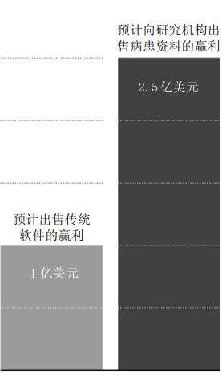

- 免费加收费模式+广告 Practice Fusion公司使用免费加收费经营模式，它提供两种不同版本的软件：第一种软件是免费的，会植入Google广告联盟的广告；另一种是没有植入广告的，每月收费100美元。在前2000位使用行诊联盟电子健康记录的医生中，只有不到10%的选择了付费版本，但是公司的赢利点并不在这……
- 出售资料 通过吸引大量的医生使用免费软件，行诊联盟公司也创造出了一个日益增大的病患资料库。从事医学研究的医疗机构需要某个患者群一个时间段以来的资料。这样一来，Practice Fusion公司就可以提供某个固定患者群（例如，白人中年肥胖男性患哮喘病者）的资料，每份匿名的资料可以卖到50到500美元。每个外科大夫至少给250个病人诊过病，那么最初使用公司软件的2000个医生就给公司带来了50万份病患资料。每份病患资料都可以卖给从事不同研究的各家研究机构。如果在一段时期内，某份病患资料能够给公司带来500美元的收入，那么出售资料收入就比一次性卖给2000个医生5万美元的软件更赚钱。

按照反垄断理论，因为在用收费产品向免费产品提供补贴方面，在市场占据统治地位的公司具有无可比拟的优势（也有人认为占据垄断地位的公司在提取垄断租金），因此这些公司在使用免费策略的时候要更加谨慎。最终，监管者宣判微软公司还是可以继续和操作系统一起捆绑销售浏览器和其他支持软件，代价是微软需要支付数亿美元之巨的罚款、诉讼费用以及对公司声誉带来的损失。

### 来自企鹅 <sup>[1]</sup> 的攻击

另一种免费的软件就是开源软件，尽管并非一直叫这个名字，但却是微软曾与之斗争了几十年的老对手。直到1998年，人们可以不收费就使用并做修改的软件叫做“免费软件”或“共享软件”，包括操作系统（各种UNIX操作系统）、文字处理器和编程语言。随着网络日益成为重要的沟通平台，UNIX系统的软件编写者形成了一个非正式的联络群体，这个群体变得日益壮大而且合作效率也在逐渐提升。这些编程者创立了特别的许可，从而使得软件能够传播给更多的人并吸引更多人为改善软件作出贡献。免费软件成了一股不可忽视的重要力量。

网景公司1998年决定免费发布网景浏览器代码的做法是免费软件主流运动中的一个亮点。1998年底，在美国科技出版商蒂姆·奥雷利组织召开的会议上，与会者对于使用“开源软件”达成了共识。使用“开源软件”的一个最大好处就是没有用到“免费”一词，因为免费一词在英文中的另一个含义“自由”被理查德·斯托曼滥用了，这位叛逆的麻省理工学院电脑科学家创立了自由软件基金会，为的是推动自己所支持的反资本主义运动。

1998年参会的包括Linux之父、年仅29岁的李纳斯·托瓦兹。1992年，在芬兰赫尔辛基学习的李纳斯·托瓦兹开始研究编写简化的UNIX操作系统，李纳斯·托瓦兹把它命名为Linux系统。李纳斯·托瓦兹不仅编写出了很好的代码，而且为人随和、富有组织能力，更重要的是网络日益成为了国际合作的一个工具，Linux系统马上就蹿红了（看来软件专家们害怕微软垄断地位和大多数专家反微软的情绪并不一定有害）。

当蒂姆·奥雷利组织召开这次会议时，Linux系统已经成为公认的新一代软件中的佼佼者。Linux系统代表着一种功能强大、受欢迎的编码，它允许任何人使用和改变这种编码，并把编码修改内容免费公之于众。任何人如果想要出售这一软件也可以，不过他们不能把软件据为己有。

起初，Linux系统主要是和其他版本的UNIX操作系统竞争，这些UNIX操作系统包括免费版本以及太阳微系统公司（Sun）和IBM公司的付费版本。然而，因为Linux系统卓越的技术性能和综合软件专家免费贡献才智的出色能力，使得Linux系统取得了巨大的成功，微软公司此时才留意到Linux系统的重要性，当时微软还心满意足地坐拥数亿美元的服务器操作系统软件市场。

在我采访微软高层是如何想办法成功应对开源软件时，他们的回答中有一点让我感到很诧异。他们意识到这一点时已经很晚了，尽管Linux系统从出现时微软公司就已经注意到了，但微软的市场部从20世纪90年代后期开始就一直在奚落Linux系统，微软内部人士认为Linux系统只是个无足重轻的小软件而已，根本不值得微软为之调整商业战略。不过，微软公司在2002年9月召开了Linux全球大会，这是项目经理彼得·休斯顿提出的“正视Linux”战略的开始。

这次会议比李纳斯·托瓦兹开始研究Linux要晚了10年，比蒂姆·奥雷利组织的开源软件峰会也晚了4年，比生产Linux软件的VA Linux公司和红帽公司在纳斯达克上市后股价疯涨引发的“Linux泡沫”也晚了3年。到了2002年，尽管微软公司占据了网站服务器操作系统市场的半壁江山，而Linux系统也占据了25%的市场份额。

为什么微软花了这么长时间才做出反应并有后面发生的一切？我们最好是通过心理学家伊丽莎白·库伯勒·罗斯提出的“悲痛五阶段”理论来解释。

阶段一：否认

当Linux系统出现的最初10年，微软高管的心里都在想些什么呢？多数高管希望这款免费的操作系统能像大多数其他免费软件一样悄无声息地消失，或是影响力有限。即便Linux系统不会完全消失，微软高管也希望受它吸引的是原来就使用UNIX系统的人，而非微软操作系统的客户。这种想法其实也并不能让人感到称心如意，因为这些使用UNIX系统的使用者也是微软公司想要争取的客户，但至少比同生产Linux系统的公司发生直接竞争要好。不过，最让微软的经理们感到困惑的是，为什么消费者们宁可忍受操作中会产生的烦恼也要使用免费软件，而不是选用由专业人士编写的软件？

消费者很青睐Linux系统，尤其是他们建立了越来越大的数据中心来支持快速发展的网络世界需求。维护一个Linux服务器比维护同样的一个微软服务器要麻烦，但是如果你要使用数十万个服务器的话，了解Linux系统的秘诀之后你就能在日后省下一大笔开销。到2003年年底，Linux系统在网络服务器市场中的份额已经上升到了接近1/3强。扼制Linux系统上升势头的一个办法就是和它的价格一样富有竞争力，也就是零价格，不过这对于微软的高管们而言实在太恐怖了，简直不敢想象。因此，微软主要就是采取了在背后诋毁Linux系统的招数。

在微软公司内部，一些工程师已经发出了警告，Linux系统对于微软的核心业务模式是一种长期威胁，并建议微软采取更有力的应对之策。1998年，微软的一位工程师在内部邮件系统群发了一份备忘录，认为开源软件“对微软的收入和平台都造成了直接威胁”。这份备忘录后来从公司中泄露了出来，在网络上传播，人们把它称为“鬼节备忘录”（既是因为这份备忘录泄露的时间，也是因为让人心慌的内容）。这份备忘录还警告说“开源软件免费的信息交换具有微软付费使用版本软件所不可比拟的优势，因此对于软件研发人员的思维观念会造成长期的冲击”。

但是，微软在公开场合的表态和工程师们的想法很不一样。1998年12月的一篇新闻报道指出：“微软的高管不屑一顾地把开源软件贬斥为骗局，微软的一位营销经理艾德·马斯说，‘未来复杂的项目需要大型团队的大量资金投入，这可不是罗宾汉和他在谢伍德森林里的散兵游勇们擅长做的。’”

阶段二：愤怒

一旦形势变得明朗了，Linux系统不仅能够存活下去，而且还能和微软的产品平起平坐了，微软对Linux系统的情绪就变成了愤怒。微软的销售人员告诉摇摆不定的消费者说，“尽管Linux系统是免费的，但就像免费送你一条小狗一样”，你还要照顾这只狗一辈子，给它买狗粮，给它擦干净粪便，每天还要带它出去走走，这种比喻让有些想选用Linux系统的用户吓得不敢越雷池半步。

微软决定用经济学的角度来对Linux系统进行攻击，其中的一个关键说法就是“拥有者的总使用成本”。微软表示，软件的成本并非仅仅只是第一次的购买成本，还有后期的维护成本。微软指出，Linux系统更难维护，因此那些受骗上当使用了Linux系统的人得求一大堆软件编程工程师和IT精英来维修瘫痪不动的机器。

1999年10月，微软开始真刀真枪地对Linux系统发起了攻击，它在网站上发表了一篇题为“Linux五个不为人所知的秘密”的文章。文章列举了Linux系统的技术缺陷，并得出结论说Linux系统的性能比不上微软的产品，Linux系统所谓的免费并非真的不花钱，“Linux系统管理员必须要花费大量的时间来学习最先进的Linux内容，并决定该做点什么”。这篇文章警告说：“Linux群体会跟你大谈特谈Linux的免费或是低价有多么好。但有一点是很重要的，那就是消费者要明白版权费只是总决策过程成本的一小部分。”

然而，微软的这种攻击并没有收到效果。这种没有证据的指责在消费者看来，更加体现了微软的恐惧、不确定和彷徨。Linux系统、Apache网络服务器、MySQL数据库、Perl 和Python脚本语言等其他开源软件的发展势头都很好。2002年11月，一个感到灰心丧气的微软视窗项目经理给微软的公关部写了一份备忘录：“对于政府以及其他主要社会机构想要选择开源软件而非微软产品的想法，媒体上已经有很多报道了，对于这些报道微软应该采取更积极有效的应对之策……我们必须要做好应对的准备……当政府等大型机构在考虑或初步尝试使用这些技术的时候，我们应该要快速用事实反击那种认为大型机构已经在使用Linux系统的观念。”

阶段三：商讨

随着2002年微软举办的Linux全球大会召开，微软显然需要拿出新的策略。IBM公司早已设立了Linux部，并安排工程师们编写Linux程序。该微软公司抛弃那些冷嘲热讽并正视现实了：Linux并没有消失，而消费者对于微软攻击Linux产生的不满态度正是原因之一。微软公司内部负责和Linux竞争的团队负责人休斯敦说：“我们意识到，如果想要别人正视我们，那么说话做事就需要剔除情感因素。实际上，我们所说的一切都让自己陷得更深了，而让竞争对手感到高兴。”

在Linux全球大会上，微软公司的代表都穿着写有“让我们来商谈”的T恤衫。

在这次会议之后，休斯敦明白了微软的攻讦为什么没有追随者，他说：“我们需要证明自己的观点，那就是Linux系统拥有者的总使用成本更高。”他委托国际数据集团旗下的IDC咨询公司进行了一项研究，如果考虑所有者的总使用成本，微软Windows视窗系统是否真的比Linux要好。最后的研究报告显示是微软胜出，但是微软的高管们也感到很矛盾，不知道是不是该采用这份报告。因为微软一直以来都宣称同样的观点而拿不出足够的证据，拿出这份报告就能改变大家的看法吗？

也许确实不能，不过这份报告也给微软赢得了一席之地。消费者意识到，也许微软并不是在罗织罪名，Linux系统确实要比看起来更加复杂、维护成本也更高。与此同时，微软也决定进入透明化的战场，它宣布了一个“共享资源”的项目，政府客户可以看到隐藏在Windows视窗系统和其他微软产品下面的代码。如果开源代码的一个吸引人之处是透明化的话，那么微软公司也可以提供这种透明化，不过前提是客户宣布将保密并不会泄露代码。几个政府客户参与了“共享资源”项目的全过程，但是这在Linux时代没有掀起任何波澜，现在是时候采取更激进的做法了。

阶段四：绝望

2003年下半年时，微软走的一步棋让很多人都感到不可思议，它挖来了IBM公司成功运营Linux战略的比尔·希尔夫。在聘用比尔·希尔夫的过程中，微软的首席执行官史蒂夫·鲍尔默对希尔夫说：“我们对免费必须要有个交代。”微软公司到目前为止所付出的努力都没能遏制免费软件的势头，而当比尔·希尔夫来到微软并同这里的工程师交流后才知道是为什么了。比尔·希尔夫说：“在我同微软工程师的谈话中发现，他们对于开源软件的工作原理显然不了解，他们对开源软件的误解很深，他们只是把它当做一种威胁来看待。”

微软的工程师对开源软件误解这么深的一个重要原因是公司的律师不允许他们接触它。Linux和近似开源软件所使用的授权方式叫做通用公共许可证（GPL），它需要开源软件其他的“后续工作”都要能够做到开源。微软公司的律师们把它当成毒刺，认为任何接触它的微软工程师都有可能在工作时不小心把Windows视窗设计成开源系统了。

因此，当比尔·希尔夫想要在微软建立一个开源实验室时，大家都把它当做了一个可怖的生化武器试验室。这个实验室设在了一个老库房的角落，然后把网线接进了实验室。从那之后，比尔·希尔夫就只能孤军奋战了，连一点经费都没有。他只能使用二手电脑，并发起了一个“帮助比尔”的求援行动想要得到一些别人闲置不用的设备。任何从事开源实验室工作的人都不能接触微软的其他项目，理由是担心会传播通用公共许可证“病毒”。《西雅图邮讯报》（Seattle Post-Intelligencer）把他称为“微软公司里最寂寞的人”。

阶段五：接纳

如今，比尔·希尔夫的实验室里摆满了正在作业的高端新服务器，他有独立的经费而且还有一组软件工程师在为他的开源软件项目服务。到底发生了什么改变？理由是实用主义至上。比尔·盖茨和史蒂夫·鲍尔默对于Linux 投入了最大的努力，微软在这一领域的研究刚刚走强，现在该微软正视现实了。微软现在的立场是“和免费共生”，也就是要确保微软的软件和开源软件能互相不冲突。微软的工程师们绕过了律师们的恐惧，提出了一些“补丁”，而非研发核心的开源软件代码。

市场份额能说明问题。在服务器市场，微软依然占据了最大的市场份额，而Linux的市场份额只是在20%左右徘徊。在桌面操作系统和办公软件等市场上，微软的市场份额依然接近80%。市场决定了可以有三种不同模式的软件存在，它们是完全免费的、购买免费但需要得到付费支持的、性能很好的但一切都需要付费的软件。

刚起步的一些网站和对价格敏感的个人往往选择免费的开源软件，这些软件的性能正变得越来越好。然而，大公司更注重把风险降到最低点，因而它们愿意选用收费的微软软件或是红帽公司等Linux系统提供商的服务。这些公司知道，他们向软件公司开出了一张支票，就同时得到了一份合约，有了这份合约，这些公司就会得到“高水准服务的保证”。也就是说，如果软件出了故障，那么你就可以拨打某个维修电话了。

如今，开源软件和非开源软件都代表着巨大的市场。从总营业收入来计算，微软远远超过了自己的开源软件竞争对手。但是，从用户数目来计算，两者之间的距离相差并不大。例如，火狐浏览器就在不断侵蚀微软IE浏览器的市场份额（目前已经占据了30%的市场份额），该浏览器开发商莫兹拉公司的收入完全依靠Google公司的广告收入分成，当人们使用火狐浏览器搜索内容的时候，就会链接到Google浏览器的搜寻结果页面。莫兹拉公司的员工人数不到100，却能和微软浏览器的强大工作团队周旋。这是建立在免费基础上的另一类生意，浏览器并不一定非要捆绑到收费的操作系统里一起销售。

与此同时，大多数网站，包括Google和亚马逊都在依靠开源软件。即便在一些经营方式最陈旧的公司里，Java或是PHP这样的脚本语言都已经渗透其中。这是一个免费和付费软件共存的混合世界。微软过去的教训告诉我们，这种混合世界不仅有可能存在，而且可能发展得很好，因为一道菜品不一定适合所有人的口味。